# Values Three-Way Interactions

2023-03-29

# Data Import & Cleaning

## Import data

```r
raw_psych_hum_subj <- import("data/raw/raw_psych_hum_subj.csv")
raw_mktg_hum_subj <- import("data/raw/raw_mktg_hum_subj.csv")
raw_gen_uo_pop <- import("data/raw/raw_gen_uo_pop.csv")
pre_fall22 <- import("data/prescreen/dittersdorf_matches_f22.csv")
pre_winter23 <- import("data/prescreen/dittersdorf_matches_w23.csv")
pre_spring23 <- import("data/prescreen/dittersdorf_matches_s23.csv")
participant_list <- import("data/prescreen/dittersdorf_participants.csv")
```

Fix age before converting variable types

```r
table(raw_psych_hum_subj$Age) # 18 years old = 18
```

```
##
##                        18 18 years old           19           20           21
##          117          220            1          297          120           76
##           22           23           24           25           27           28
##           41            4            3            2            1            1
##           29           30           31           32           33           50
##            1            1            1            1            1            1
```

```r
table(raw_mktg_hum_subj$Age) # 1999 = 24
```

```
##
##        18   19 1999   20   21   22   23   24   25   28 test
##   11    4   13    1   50  119   66    7    9    3    1    3
```

```r
table(raw_gen_uo_pop$Age)
```

```
##
## 18 20 21 22 28
##  2  1  2  1  1
```

```r
raw_psych_hum_subj$Age[raw_psych_hum_subj$Age == "18 years old"] <- 18
raw_mktg_hum_subj$Age[raw_mktg_hum_subj$Age == 1999] <- 24

table(raw_psych_hum_subj$Age) # 18 years old = 18
```

```
##
##      18  19  20  21  22  23  24  25  27  28  29  30  31  32  33  50
## 117 221 297 120  76  41   4   3   2   1   1   1   1   1   1   1   1
```

```r
table(raw_mktg_hum_subj$Age) # 1999 = 24
```

```
##
##        18   19   20   21   22   23   24   25   28 test
##   11    4   13   50  119   66    7   10    3    1    3
```

## Combine dataframes

```r
raw_psych_hum_subj <- raw_psych_hum_subj %>%
  mutate(Age = as.integer(Age),
         Gender = as.factor(Gender),
         framing_condition_DO = as.factor(framing_condition_DO),
         norm_condition_DO = as.factor(norm_condition_DO),
         consumer_behaviors = as.factor(consumer_behaviors),
         skepticism = as.factor(skepticism),
         id = as.factor(id),
         source = strrep("psych_hsp", times = 1))

levels(raw_psych_hum_subj$framing_condition_DO)
```

```
## [1] ""                 "control_framing"  "pro_env_framing"  "self_enh_framing"
```

```r
raw_mktg_hum_subj <- raw_mktg_hum_subj %>%
  mutate(Age = as.integer(Age),
         Gender = as.factor(Gender),
         Gender_5_TEXT = as.character(Gender_5_TEXT),
         Class_Lvl_7_TEXT = as.character(Class_Lvl_7_TEXT),
         Pol_Ornt_8_TEXT = as.character(Pol_Ornt_8_TEXT),
         Ethnicity_8_TEXT = as.character(Ethnicity_8_TEXT),
         skept_open = as.character(skept_open),
         skepticism = as.factor(skepticism),
         id = as.factor(id),
         framing_condition_DO = as.factor(framing_condition_DO),
         norm_condition_DO = as.factor(norm_condition_DO),
         consumer_behaviors = as.factor(consumer_behaviors),
         source = strrep("mktg_hsp", times = 1))

raw_gen_uo_pop <- raw_gen_uo_pop %>%
  mutate(Gender = as.factor(Gender),
         Gender_5_TEXT = as.character(Gender_5_TEXT),
         Class_Lvl_7_TEXT = as.character(Class_Lvl_7_TEXT),
         Pol_Ornt_8_TEXT = as.character(Pol_Ornt_8_TEXT),
         skept_open = as.character(skept_open),
         skepticism = as.factor(skepticism),
         id = as.factor(id),
         framing_condition_DO = as.factor(framing_condition_DO),
         norm_condition_DO = as.factor(norm_condition_DO),
         consumer_behaviors = as.factor(consumer_behaviors),
         source = strrep("gen_UO", times = 1))
```

Specify unique variables to combine prescreen data sets

```r
# Create unique full_name variable
pre_fall22$full_name <- paste(pre_fall22$first_name, pre_fall22$last_name, sep="_")

pre_winter23$full_name <- paste(pre_winter23$first_name, pre_winter23$last_name, sep="_")

pre_spring23$full_name <- paste(pre_spring23$first_name, pre_spring23$last_name, sep="_")

participant_list$full_name <- paste(participant_list$first_name, participant_list$last_name, sep="_")

# Create column indicating which data set rows came from

pre_fall22 <- pre_fall22 %>%
  mutate(term = "fall22")

pre_winter23 <- pre_winter23 %>%
  mutate(term = "winter23")

pre_spring23 <- pre_spring23 %>%
  mutate(term = "spring23")
```

Combine prescreen data

```r
combine1 <- smartbind(pre_fall22, pre_winter23)
combined_prescreen <- smartbind(combine1, pre_spring23)

# nrow(pre_fall22) + nrow(pre_winter23) + nrow(pre_spring23) # n = 1167

combined_prescreen_unique <- combined_prescreen[!duplicated(combined_prescreen$full_name), ] # keeps first row (fall22)
```

Subset key variables

```r
combined_prescreen_key <- combined_prescreen_unique %>%
  dplyr::select(full_name, term, respecting:gratification, honest:gossip)

participant_list_key <- participant_list %>%
  dplyr::select(full_name, survey_id)
```

Merge with participant list

```r
merged_prescreen <- merge(combined_prescreen_key, participant_list_key, by = "full_name")
```

Rename SDR items to match

Convert variable types

```r
merged_prescreen <- merged_prescreen %>%
  mutate(respecting = as.integer(respecting),
         unity = as.integer(unity),
         protecting = as.integer(protecting),
         preventing = as.integer(preventing),
         equality = as.integer(equality),
         peace = as.integer(peace),
         justice = as.integer(justice),
         helpful = as.integer(helpful),
         power = as.integer(power),
         wealth = as.integer(wealth),
         authority = as.integer(authority),
         influential = as.integer(influential),
         ambition = as.integer(ambition),
         pleasures = as.integer(pleasures),
         enjoying = as.integer(enjoying),
         gratification = as.integer(gratification),
         honest = as.integer(honest),
         like = as.integer(like),
         disturbing = as.integer(disturbing),
         regret = as.integer(regret),
         lose_out = as.integer(lose_out),
         rational = as.integer(rational),
         confident = as.integer(confident),
         lover = as.integer(lover),
         lies = as.integer(lies),
         cover_up = as.integer(cover_up),
         advantage = as.integer(advantage),
         get_even = as.integer(get_even),
         behind_back = as.integer(behind_back),
         private_talk = as.integer(private_talk),
         take_things = as.integer(take_things),
         gossip = as.integer(gossip),
         id = as.factor(id))
```

Rename values & socially desirable items in prescreen data to match names in main data:

Combine all data

- First, combine Psych Hum Subj data with Prescreen data based on `id`
- Second, add Mktg Hum Subj data
- Third, add gen UO Pop data

```r
combine1 <- merge(raw_psych_hum_subj, merged_prescreen, by = "id")
combine2 <- smartbind(combine1, raw_mktg_hum_subj)
combine3 <- smartbind(combine2, raw_gen_uo_pop)
```

## Remove duplicate cases

Identify duplicate cases

```r
# first, add unique row #s
combine3 <- combine3 %>%
  mutate(row = 1:nrow(combine3))

combine3[duplicated(combine3$id),] # Only rows 1 through 858 have unique id #s

# write.csv(combine3, "combined_data.csv")
```

Row IDs to remove:

- 13 (participant’s second time completing study)
- 134 (participant didn’t complete study first time)
- 145 (participant didn’t complete study first time)
- 308 (participant’s second time completing study)
- 672 (participant’s second time completing study)
- 743 (participant didn’t complete study first time)
- 790 (participant didn’t complete study first time)
- 800 (participant didn’t complete study first time)

Remove duplicate rows after resolving:

```r
combine3 <- combine3 %>%
  filter(!row %in% c(13, 134, 145, 308, 672, 743, 790, 800))
```

## Remove rows of all NAs

Identify completely missing rows:

```r
key_vars <- combine3 %>%
  dplyr::select(row, big_2_1:big_2_65, consumer_intentions_1:consumer_intentions_9, consumer_behaviors, clothing_interest_1:clothing_interest_20, ingroup_ident_1:ingroup_ident_14, values_1:values_16, socially_desirable_1:socially_desirable_16, source)

ncol(key_vars) # number of columns - the row # & source column = 141

all_NA_rows <- key_vars[rowSums(is.na(key_vars)) == 141,] # identify rows with 141 NAs (all missing values), row numbers are preserved

all_NA_rows
```

Removing rows of fully missing data

```r
data <- combine3 %>%
  dplyr::filter(!row %in% c(859, 860, 900, 926, 927, 941, 1139, 1141, 1142, 1143, 1144, 1146, 1149, 1150, 1152)) %>% # remove rows containing all NAs
  dplyr::select(-StartDate, -EndDate, -Status, -Progress, -"Duration (in seconds)", -Finished, -RecordedDate, -ResponseId, -DistributionChannel, -UserLanguage, -big_2_DO, -consumer_intentions_DO, -consumer_behaviors_DO, -clothing_interest_DO, -ingroup_ident_DO, -full_name, -code, -socially_desirable_DO, -values_DO, -email_giftcard, -term) # removing variables not in analysis
```

## Number per source

```r
table(data$source)
```

```
##
##    gen_UO  mktg_hsp psych_hsp
##         7       276       850
```

- 850 = psych human subjects pool
- 276 = mktg human subjects pool
- 7 = general UO pop

Rename variables

```r
data <- data %>%
  rename("framing_condition" = "framing_condition_DO",
         "norm_condition" = "norm_condition_DO")
```

Drop unused levels

Re-order levels of norm condition

```r
data$norm_condition <- factor(data$norm_condition, levels = c("control_norm", "descriptive_norm", "convention_norm", "social_norm", "moral_norm"))
```

## Inspect final data

```r
str(data, list.len = ncol(data))

# write.csv(data, "final_data.csv")
```

# Aggregate Variables

## Personality

### Reverse-code

```r
data_R <- data %>%
  mutate(across(c(big_2_11,
                  big_2_16,
                  big_2_26,
                  big_2_31,
                  big_2_36,
                  big_2_51,
                  big_2_12,
                  big_2_17,
                  big_2_22,
                  big_2_37,
                  big_2_42,
                  big_2_47,
                  big_2_3,
                  big_2_8,
                  big_2_23,
                  big_2_28,
                  big_2_48,
                  big_2_58,
                  big_2_4,
                  big_2_9,
                  big_2_24,
                  big_2_29,
                  big_2_44,
                  big_2_49,
                  big_2_5,
                  big_2_25,
                  big_2_30,
                  big_2_45,
                  big_2_50,
                  big_2_55,
                  big_2_63), ~6 - .)) # replace '6' with the max possible value plus 1 for any particular scale
```

### Average items

```r
data_R$extraversion <- data_R %>%
  dplyr::select(big_2_1, big_2_6, big_2_11, big_2_16, big_2_21, big_2_26, big_2_31, big_2_36, big_2_41, big_2_46, big_2_51, big_2_56) %>%
  rowMeans(na.rm = TRUE)


data_R$conscientiousness <- data_R %>%
  dplyr::select(big_2_3, big_2_8, big_2_13, big_2_18, big_2_23, big_2_28, big_2_33, big_2_38, big_2_43, big_2_48, big_2_53, big_2_58) %>%
  rowMeans(na.rm = TRUE)


data_R$agreeableness <- data_R %>%
  dplyr::select(big_2_2, big_2_7, big_2_12, big_2_17, big_2_22, big_2_27, big_2_32, big_2_37, big_2_42, big_2_47, big_2_52, big_2_57) %>%
  rowMeans(na.rm = TRUE)


data_R$neuroticism <- data_R %>%
  dplyr::select(big_2_4, big_2_9, big_2_14, big_2_19, big_2_24, big_2_29, big_2_34, big_2_39, big_2_44, big_2_49, big_2_54, big_2_59) %>%
  rowMeans(na.rm = TRUE)


data_R$openness <- data_R %>%
  dplyr::select(big_2_5, big_2_10, big_2_15, big_2_20, big_2_25, big_2_30, big_2_35, big_2_40, big_2_45, big_2_50, big_2_55, big_2_60) %>%
  rowMeans(na.rm = TRUE)


data_R$honesty <- data_R %>%
  dplyr::select(big_2_61, big_2_62, big_2_63, big_2_64, big_2_65) %>%
  rowMeans(na.rm = TRUE)
```

### Visually inspect

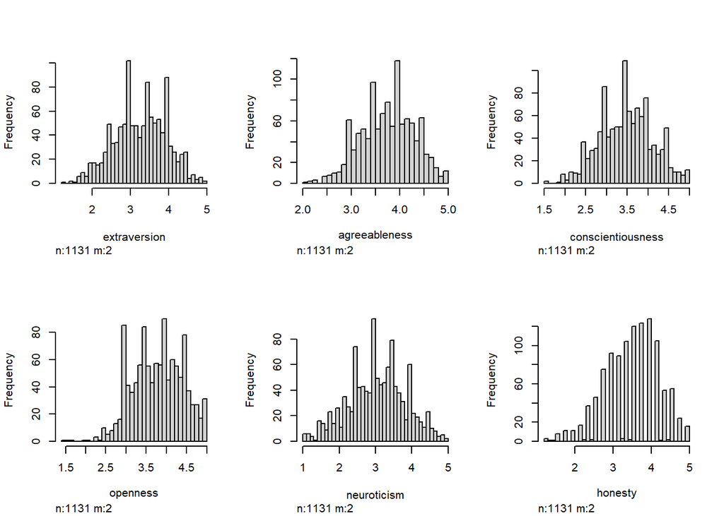

```r
data_R %>%
  dplyr::select(extraversion, agreeableness, conscientiousness, openness, neuroticism, honesty) %>%
  hist()
```

## Clothing Interest

### Reverse-code

```r
data_R <- data_R %>%
  mutate(across(c(clothing_interest_3,
                  clothing_interest_5,
                  clothing_interest_7,
                  clothing_interest_9,
                  clothing_interest_12,
                  clothing_interest_14,
                  clothing_interest_15,
                  clothing_interest_16,
                  clothing_interest_18,
                  clothing_interest_20), ~6 - .)) # replace '#' with the max possible value plus 1 for any particular scale
```

### Average items

```r
data_R$clothing_interest <- data_R %>%
  dplyr::select(clothing_interest_1:clothing_interest_20) %>%
  rowMeans(na.rm = TRUE)
```

### Visually Inspect

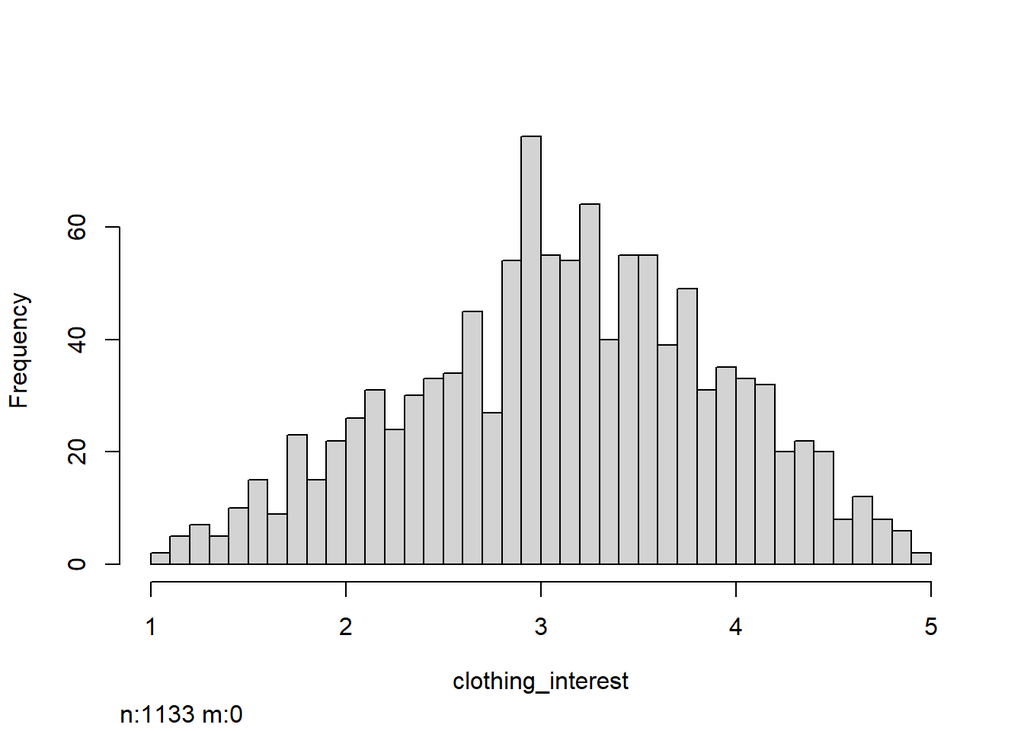

```r
data_R %>%
  dplyr::select(clothing_interest) %>%
  hist()
```

## In-group Identification

### Reverse-code

No items need to be reverse-coded.

### Average items

```r
data_R$ingroup_identification <- data_R %>%
  dplyr::select(ingroup_ident_1:ingroup_ident_14) %>%
  rowMeans(na.rm = TRUE)
```

### Visually Inspect

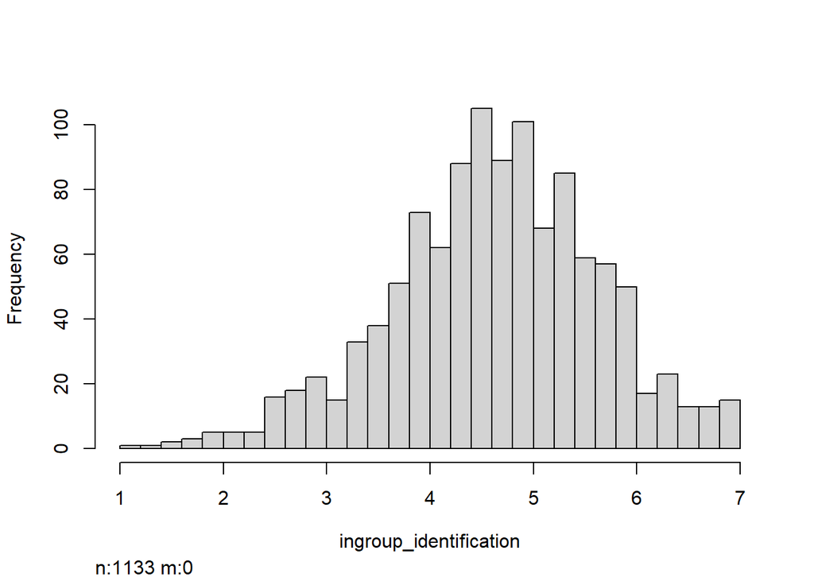

```r
data_R %>%
  dplyr::select(ingroup_identification) %>%
  hist()
```

## Values

### Reverse-code

No items need to be reverse-coded.

### Recoding scale options

Recoding values:

- -3 = 1
- -2 = 2
- -1 = 3
- 0 = 4
- +1 = 5
- +2 = 6
- +3 = 7

```r
table(data_R$values_1)
```

```
##
##  -3  -2  -1   0   1   2   3
##   5  10  17  40 176 362 508
```

```r
data_R$values_1_rec <- dplyr::recode(data_R$values_1, `-3` = 1, `-2` = 2, `-1` = 3, `0` = 4, `1` = 5, `2` = 6, `3` = 7)

table(data_R$values_1_rec)
```

```
##
##   1   2   3   4   5   6   7
##   5  10  17  40 176 362 508
```

```r
data_R$values_2_rec <- dplyr::recode(data_R$values_2, `-3` = 1, `-2` = 2, `-1` = 3, `0` = 4, `1` = 5, `2` = 6, `3` = 7)
data_R$values_3_rec <- dplyr::recode(data_R$values_3, `-3` = 1, `-2` = 2, `-1` = 3, `0` = 4, `1` = 5, `2` = 6, `3` = 7)
data_R$values_4_rec <- dplyr::recode(data_R$values_4, `-3` = 1, `-2` = 2, `-1` = 3, `0` = 4, `1` = 5, `2` = 6, `3` = 7)
data_R$values_5_rec <- dplyr::recode(data_R$values_5, `-3` = 1, `-2` = 2, `-1` = 3, `0` = 4, `1` = 5, `2` = 6, `3` = 7)
data_R$values_6_rec <- dplyr::recode(data_R$values_6, `-3` = 1, `-2` = 2, `-1` = 3, `0` = 4, `1` = 5, `2` = 6, `3` = 7)
data_R$values_7_rec <- dplyr::recode(data_R$values_7, `-3` = 1, `-2` = 2, `-1` = 3, `0` = 4, `1` = 5, `2` = 6, `3` = 7)
data_R$values_8_rec <- dplyr::recode(data_R$values_8, `-3` = 1, `-2` = 2, `-1` = 3, `0` = 4, `1` = 5, `2` = 6, `3` = 7)
data_R$values_9_rec <- dplyr::recode(data_R$values_9, `-3` = 1, `-2` = 2, `-1` = 3, `0` = 4, `1` = 5, `2` = 6, `3` = 7)
data_R$values_10_rec <- dplyr::recode(data_R$values_10, `-3` = 1, `-2` = 2, `-1` = 3, `0` = 4, `1` = 5, `2` = 6, `3` = 7)
data_R$values_11_rec <- dplyr::recode(data_R$values_11, `-3` = 1, `-2` = 2, `-1` = 3, `0` = 4, `1` = 5, `2` = 6, `3` = 7)
data_R$values_12_rec <- dplyr::recode(data_R$values_12, `-3` = 1, `-2` = 2, `-1` = 3, `0` = 4, `1` = 5, `2` = 6, `3` = 7)
data_R$values_13_rec <- dplyr::recode(data_R$values_13, `-3` = 1, `-2` = 2, `-1` = 3, `0` = 4, `1` = 5, `2` = 6, `3` = 7)
data_R$values_14_rec <- dplyr::recode(data_R$values_14, `-3` = 1, `-2` = 2, `-1` = 3, `0` = 4, `1` = 5, `2` = 6, `3` = 7)
data_R$values_15_rec <- dplyr::recode(data_R$values_15, `-3` = 1, `-2` = 2, `-1` = 3, `0` = 4, `1` = 5, `2` = 6, `3` = 7)
data_R$values_16_rec <- dplyr::recode(data_R$values_16, `-3` = 1, `-2` = 2, `-1` = 3, `0` = 4, `1` = 5, `2` = 6, `3` = 7)

table(data_R$values_16)
```

```
##
##  -3  -2  -1   0   1   2   3
##   4  11  29 116 250 394 312
```

```r
table(data_R$values_16_rec)
```

```
##
##   1   2   3   4   5   6   7
##   4  11  29 116 250 394 312
```

### Average items

```r
data_R$biospheric <- data_R %>%
  dplyr::select(values_1_rec:values_4_rec) %>%
  rowMeans(na.rm = TRUE)

data_R$altruistic <- data_R %>%
  dplyr::select(values_5_rec:values_8_rec) %>%
  rowMeans(na.rm = TRUE)

data_R$egoistic <- data_R %>%
  dplyr::select(values_9_rec:values_13_rec) %>%
  rowMeans(na.rm = TRUE)

data_R$hedonic <- data_R %>%
  dplyr::select(values_14_rec:values_16_rec) %>%
  rowMeans(na.rm = TRUE)
```

### Visually inspect

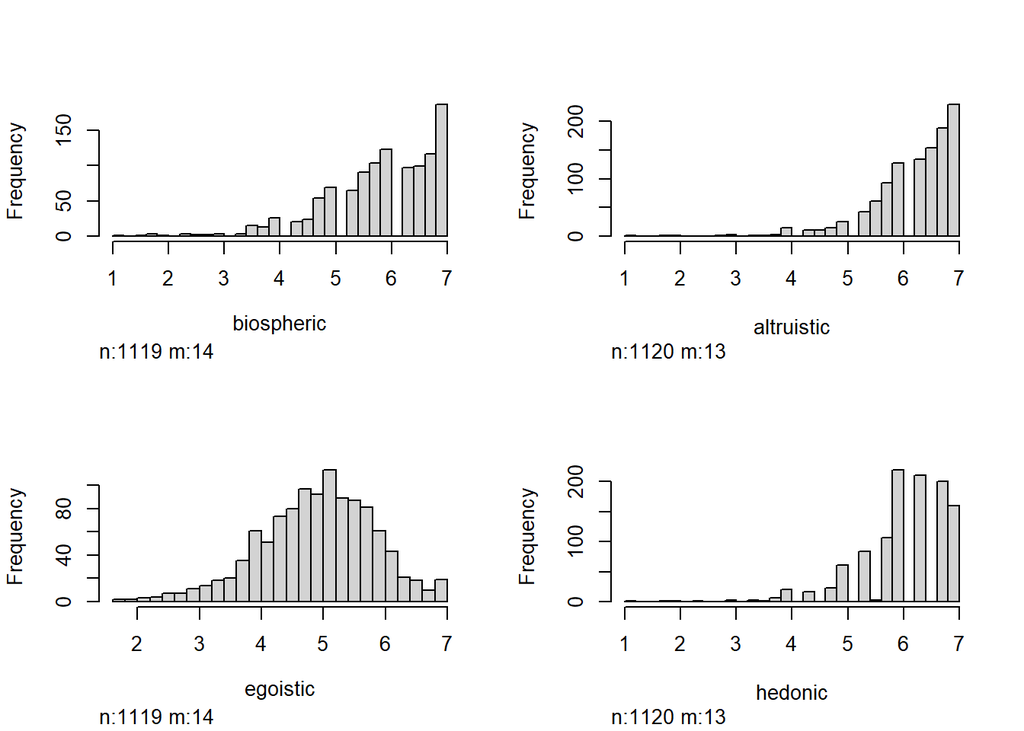

```r
values_df <- data_R %>%
  dplyr::select(biospheric, altruistic, egoistic, hedonic)

values_df %>%
  hist()
```

### Frequency tables

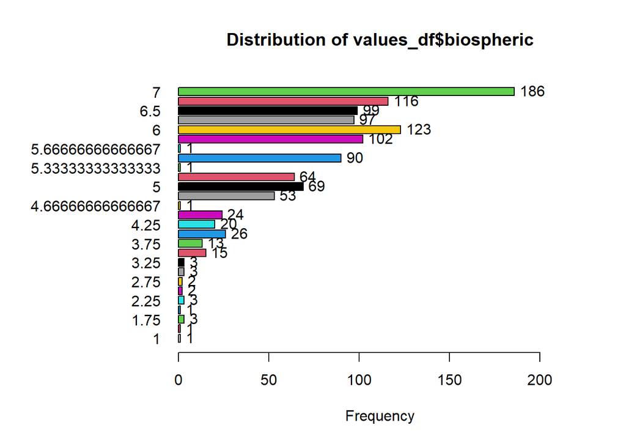

```
## values_df$biospheric :
##                  Frequency   %(NA+) cum.%(NA+)   %(NA-) cum.%(NA-)
## 1                        1      0.1        0.1      0.1        0.1
## 1.5                      1      0.1        0.2      0.1        0.2
## 1.75                     3      0.3        0.4      0.3        0.4
## 2                        1      0.1        0.5      0.1        0.5
## 2.25                     3      0.3        0.8      0.3        0.8
## 2.5                      2      0.2        1.0      0.2        1.0
## 2.75                     2      0.2        1.1      0.2        1.2
## 3                        3      0.3        1.4      0.3        1.4
## 3.25                     3      0.3        1.7      0.3        1.7
## 3.5                     15      1.3        3.0      1.3        3.0
## 3.75                    13      1.1        4.1      1.2        4.2
## 4                       26      2.3        6.4      2.3        6.5
## 4.25                    20      1.8        8.2      1.8        8.3
## 4.5                     24      2.1       10.3      2.1       10.5
## 4.66666666666667         1      0.1       10.4      0.1       10.5
## 4.75                    53      4.7       15.1      4.7       15.3
## 5                       69      6.1       21.2      6.2       21.4
## 5.25                    64      5.6       26.8      5.7       27.2
## 5.33333333333333         1      0.1       26.9      0.1       27.3
## 5.5                     90      7.9       34.9      8.0       35.3
## 5.66666666666667         1      0.1       35.0      0.1       35.4
## 5.75                   102      9.0       44.0      9.1       44.5
## 6                      123     10.9       54.8     11.0       55.5
## 6.25                    97      8.6       63.4      8.7       64.2
## 6.5                     99      8.7       72.1      8.8       73.0
## 6.75                   116     10.2       82.3     10.4       83.4
## 7                      186     16.4       98.8     16.6      100.0
## NaN                     14      1.2      100.0      0.0      100.0
##   Total               1133    100.0      100.0    100.0      100.0
```

```r
# Biospheric values
tab1(values_df$biospheric, sort.group = "descending", cum.percent = TRUE, missing = FALSE, horiz = TRUE)
```

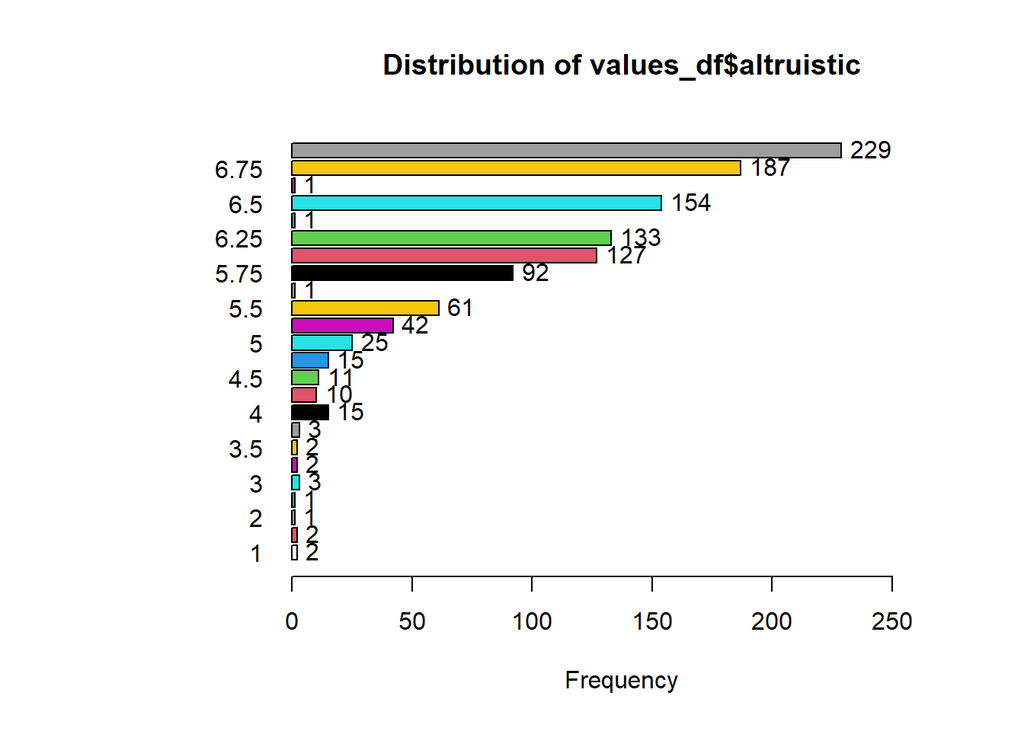

```
## values_df$altruistic :
##                  Frequency   %(NA+) cum.%(NA+)   %(NA-) cum.%(NA-)
## 1                        2      0.2        0.2      0.2        0.2
## 1.75                     2      0.2        0.4      0.2        0.4
## 2                        1      0.1        0.4      0.1        0.4
## 2.75                     1      0.1        0.5      0.1        0.5
## 3                        3      0.3        0.8      0.3        0.8
## 3.25                     2      0.2        1.0      0.2        1.0
## 3.5                      2      0.2        1.1      0.2        1.2
## 3.75                     3      0.3        1.4      0.3        1.4
## 4                       15      1.3        2.7      1.3        2.8
## 4.25                    10      0.9        3.6      0.9        3.7
## 4.5                     11      1.0        4.6      1.0        4.6
## 4.75                    15      1.3        5.9      1.3        6.0
## 5                       25      2.2        8.1      2.2        8.2
## 5.25                    42      3.7       11.8      3.8       12.0
## 5.5                     61      5.4       17.2      5.4       17.4
## 5.66666666666667         1      0.1       17.3      0.1       17.5
## 5.75                    92      8.1       25.4      8.2       25.7
## 6                      127     11.2       36.6     11.3       37.1
## 6.25                   133     11.7       48.4     11.9       48.9
## 6.33333333333333         1      0.1       48.5      0.1       49.0
## 6.5                    154     13.6       62.0     13.8       62.8
## 6.66666666666667         1      0.1       62.1      0.1       62.9
## 6.75                   187     16.5       78.6     16.7       79.6
## 7                      229     20.2       98.9     20.4      100.0
## NaN                     13      1.1      100.0      0.0      100.0
##   Total               1133    100.0      100.0    100.0      100.0
```

```r
# Altruistic values
tab1(values_df$altruistic, sort.group = "descending", cum.percent = TRUE, missing = FALSE, horiz = TRUE)
```

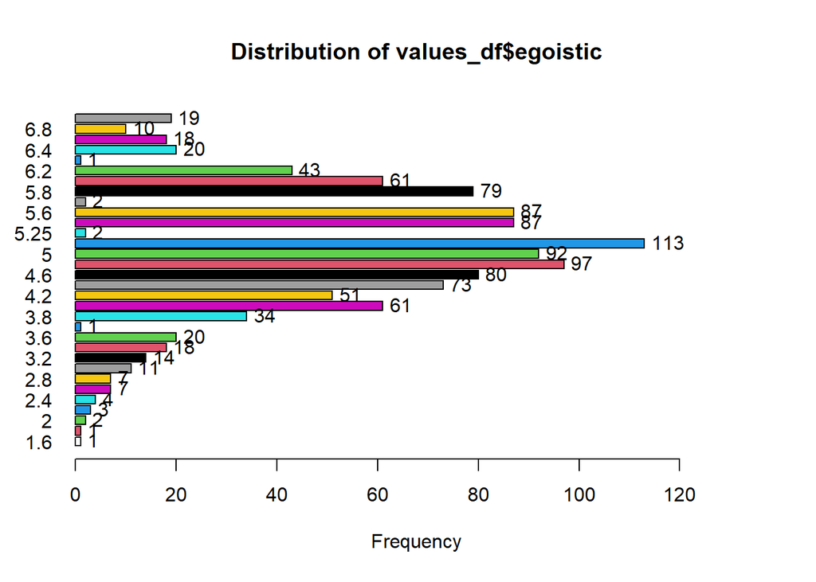

```
## values_df$egoistic :
##         Frequency   %(NA+) cum.%(NA+)   %(NA-) cum.%(NA-)
## 1.6             1      0.1        0.1      0.1        0.1
## 1.8             1      0.1        0.2      0.1        0.2
## 2               2      0.2        0.4      0.2        0.4
## 2.2             3      0.3        0.6      0.3        0.6
## 2.4             4      0.4        1.0      0.4        1.0
## 2.6             7      0.6        1.6      0.6        1.6
## 2.8             7      0.6        2.2      0.6        2.2
## 3              11      1.0        3.2      1.0        3.2
## 3.2            14      1.2        4.4      1.3        4.5
## 3.4            18      1.6        6.0      1.6        6.1
## 3.6            20      1.8        7.8      1.8        7.9
## 3.75            1      0.1        7.9      0.1        8.0
## 3.8            34      3.0       10.9      3.0       11.0
## 4              61      5.4       16.2      5.5       16.4
## 4.2            51      4.5       20.7      4.6       21.0
## 4.4            73      6.4       27.2      6.5       27.5
## 4.6            80      7.1       34.2      7.1       34.7
## 4.8            97      8.6       42.8      8.7       43.3
## 5              92      8.1       50.9      8.2       51.6
## 5.2           113     10.0       60.9     10.1       61.7
## 5.25            2      0.2       61.1      0.2       61.8
## 5.4            87      7.7       68.8      7.8       69.6
## 5.6            87      7.7       76.4      7.8       77.4
## 5.75            2      0.2       76.6      0.2       77.6
## 5.8            79      7.0       83.6      7.1       84.6
## 6              61      5.4       89.0      5.5       90.1
## 6.2            43      3.8       92.8      3.8       93.9
## 6.25            1      0.1       92.9      0.1       94.0
## 6.4            20      1.8       94.6      1.8       95.8
## 6.6            18      1.6       96.2      1.6       97.4
## 6.8            10      0.9       97.1      0.9       98.3
## 7              19      1.7       98.8      1.7      100.0
## NaN            14      1.2      100.0      0.0      100.0
##   Total      1133    100.0      100.0    100.0      100.0
```

```r
# Egoistic values
tab1(values_df$egoistic, sort.group = "descending", cum.percent = TRUE, missing = FALSE, horiz = TRUE)
```

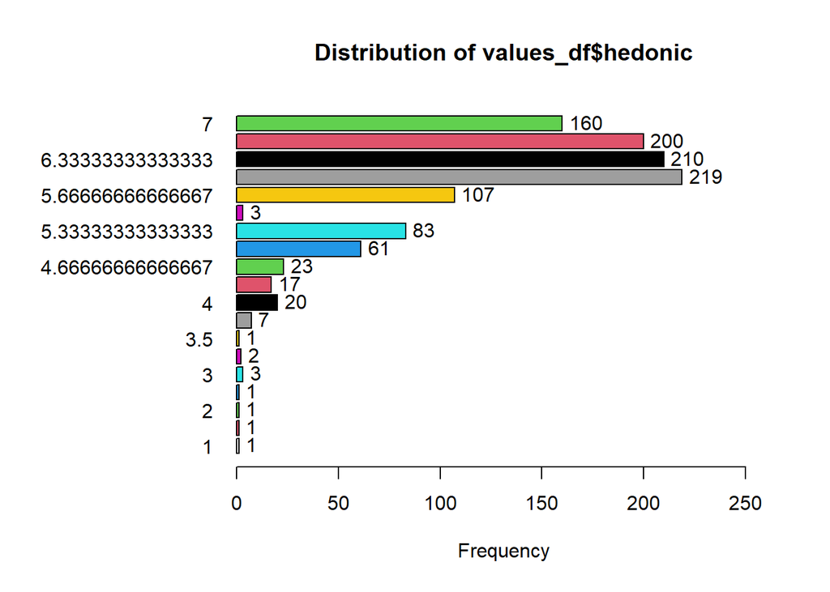

```
## values_df$hedonic :
##                  Frequency   %(NA+) cum.%(NA+)   %(NA-) cum.%(NA-)
## 1                        1      0.1        0.1      0.1        0.1
## 1.66666666666667         1      0.1        0.2      0.1        0.2
## 2                        1      0.1        0.3      0.1        0.3
## 2.33333333333333         1      0.1        0.4      0.1        0.4
## 3                        3      0.3        0.6      0.3        0.6
## 3.33333333333333         2      0.2        0.8      0.2        0.8
## 3.5                      1      0.1        0.9      0.1        0.9
## 3.66666666666667         7      0.6        1.5      0.6        1.5
## 4                       20      1.8        3.3      1.8        3.3
## 4.33333333333333        17      1.5        4.8      1.5        4.8
## 4.66666666666667        23      2.0        6.8      2.1        6.9
## 5                       61      5.4       12.2      5.4       12.3
## 5.33333333333333        83      7.3       19.5      7.4       19.7
## 5.5                      3      0.3       19.8      0.3       20.0
## 5.66666666666667       107      9.4       29.2      9.6       29.6
## 6                      219     19.3       48.5     19.6       49.1
## 6.33333333333333       210     18.5       67.1     18.8       67.9
## 6.66666666666667       200     17.7       84.7     17.9       85.7
## 7                      160     14.1       98.9     14.3      100.0
## NaN                     13      1.1      100.0      0.0      100.0
##   Total               1133    100.0      100.0    100.0      100.0
```

```r
# Hedonic values
tab1(values_df$hedonic, sort.group = "descending", cum.percent = TRUE, missing = FALSE, horiz = TRUE)
```

## Socially Desirable Responding

### Reverse-code

```r
data_R <- data_R %>%
  mutate(across(c(socially_desirable_1,
                  socially_desirable_3,
                  socially_desirable_5,
                  socially_desirable_8,
                  socially_desirable_9,
                  socially_desirable_11,
                  socially_desirable_12,
                  socially_desirable_13), ~8 - .)) # replace '#' with the max possible value plus 1 for any particular scale
```

### Average items

```r
data_R$self_deceptive_sdr <- data_R %>%
  dplyr::select(socially_desirable_1:socially_desirable_8) %>%
  rowMeans(na.rm = TRUE)

data_R$impress_manag_sdr <- data_R %>%
  dplyr::select(socially_desirable_9:socially_desirable_16) %>%
  rowMeans(na.rm = TRUE)
```

### Visually inspect

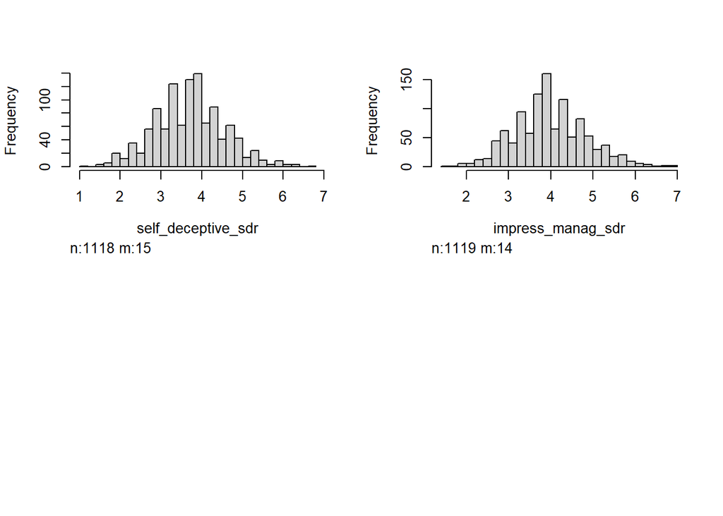

```r
data_R %>%
  dplyr::select(self_deceptive_sdr, impress_manag_sdr) %>%
  hist()
```

## Consumer Intentions

### Reverse-code

Higher scores mean better consumer intentions (intentions to *reduce* future consumption):

```r
data_R <- data_R %>%
  mutate(across(c(consumer_intentions_2,
                  consumer_intentions_4,
                  consumer_intentions_7,
                  consumer_intentions_9), ~8 - .)) # replace '#' with the max possible value plus 1 for any particular scale
```

### Average items

```r
data_R$consumer_intentions <- data_R %>%
  dplyr::select(consumer_intentions_1:consumer_intentions_9) %>%
  rowMeans(na.rm = TRUE)
```

### Visually inspect

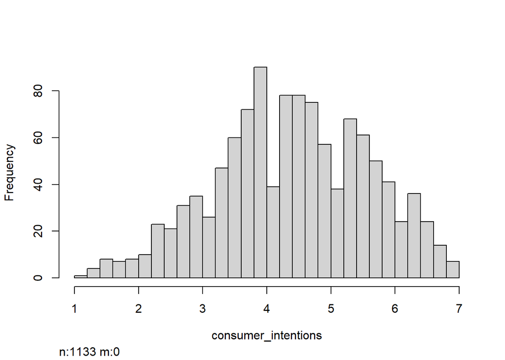

```r
data_R %>%
  dplyr::select(consumer_intentions) %>%
  hist()
```

# Contrast Coding

Subset variables

Contrast Coding using ifelse() approach:

```r
# Framing
data_R_alt$FramingCode1 <- ifelse(data_R_alt$framing_condition == "control_framing", -1/2, ifelse(data_R_alt$framing_condition == "self_enh_framing", 1/2, 0))

data_R_alt$FramingCode2 <- ifelse(data_R_alt$framing_condition == "pro_env_framing", 2/3, -1/3)


# Norm
data_R_alt$NormCode1 <- ifelse(data_R_alt$norm_condition == "moral_norm", 4, -1)

data_R_alt$NormCode2 <- ifelse(data_R_alt$norm_condition == "social_norm", 3, ifelse(data_R_alt$norm_condition == "moral_norm", 0, -1))

data_R_alt$NormCode3 <- ifelse(data_R_alt$norm_condition == "convention_norm", 2, ifelse(data_R_alt$norm_condition == "moral_norm", 0, ifelse(data_R_alt$norm_condition == "social_norm", 0, -1)))
data_R_alt$NormCode4 <- ifelse(data_R_alt$norm_condition == "descriptive_norm", 1, ifelse(data_R_alt$norm_condition == "control_norm", -1, 0))


## Adding contrast codes to Framing & Norm Condition
# Framing
FrameCode1 <- c(-1/2, 0, 1/2) # control vs self-enhancing
FrameCode2 <- c(-1/3, 2/3, -1/3) # arbitrary code

contrasts(data_R_alt$framing_condition) <- cbind(FrameCode1, FrameCode2)
contrasts(data_R_alt$framing_condition)
```

```
##                  FrameCode1 FrameCode2
## control_framing        -0.5 -0.3333333
## pro_env_framing         0.0  0.6666667
## self_enh_framing        0.5 -0.3333333
```

```r
# Norm
contrasts(data_R_alt$norm_condition) <- contr.helmert(5)
contrasts(data_R_alt$norm_condition) # control vs DN
```

```
##                  [,1] [,2] [,3] [,4]
## control_norm       -1   -1   -1   -1
## descriptive_norm    1   -1   -1   -1
## convention_norm     0    2   -1   -1
## social_norm         0    0    3   -1
## moral_norm          0    0    0    4
```

```r
# Gender
levels(data_R_alt$Gender) <- c("Woman", "Man", "Non-binary", "I prefer not to identify", "Other")

data_R_alt$Gender[data_R_alt$Gender == "Non-binary"] <- NA
data_R_alt$Gender[data_R_alt$Gender == "I prefer not to identify"] <- NA
data_R_alt$Gender[data_R_alt$Gender == "Other"] <- NA

data_R_alt$Gender <- droplevels(data_R_alt$Gender)


contrasts(data_R_alt$Gender) <- c(1, 0)
levels(data_R_alt$Gender)
```

```
## [1] "Woman" "Man"
```

# Multiple Imputation

## Examine Missingness

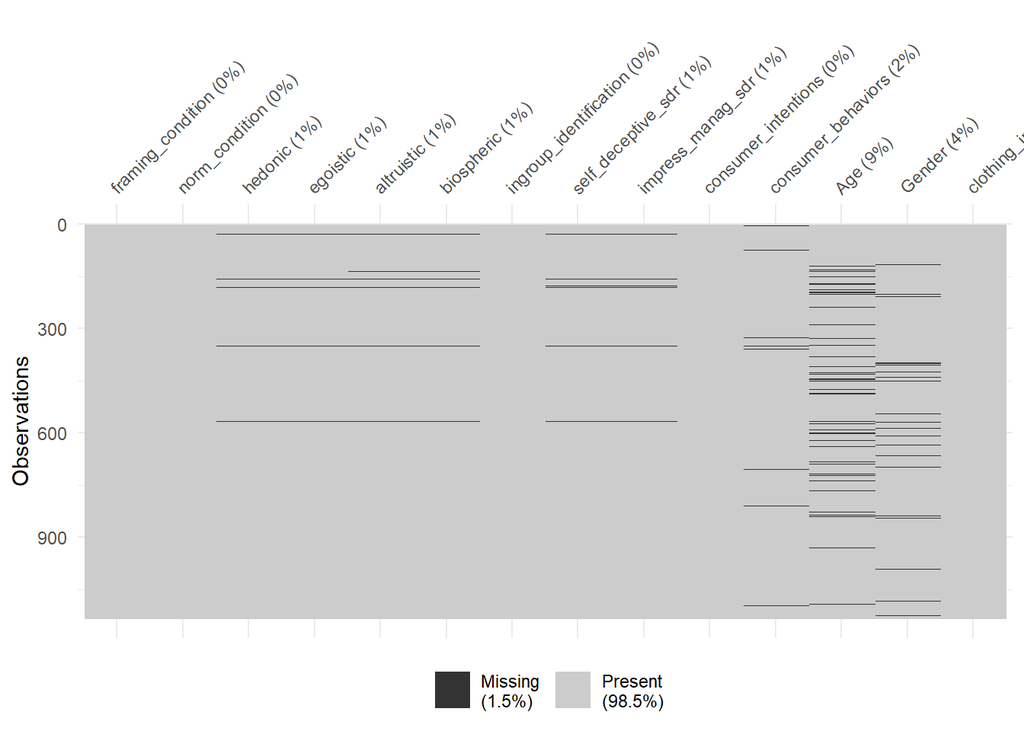

```r
data_R_alt %>%
  dplyr::select(framing_condition, norm_condition, hedonic, egoistic, altruistic, biospheric, ingroup_identification, self_deceptive_sdr, impress_manag_sdr, consumer_intentions, consumer_behaviors, Age, Gender, clothing_interest) %>%
  vis_miss()
```

```r
n_missing <- data_R_alt %>%
  dplyr::select(framing_condition, norm_condition, hedonic, egoistic, altruistic, biospheric, ingroup_identification, self_deceptive_sdr, impress_manag_sdr, consumer_intentions, consumer_behaviors, Age, Gender, clothing_interest) %>%
  lapply(function(x) sum(is.na(x)))

n_missing
```

```
## $framing_condition
## [1] 0
##
## $norm_condition
## [1] 0
##
## $hedonic
## [1] 13
##
## $egoistic
## [1] 14
##
## $altruistic
## [1] 13
##
## $biospheric
## [1] 14
##
## $ingroup_identification
## [1] 0
##
## $self_deceptive_sdr
## [1] 15
##
## $impress_manag_sdr
## [1] 14
##
## $consumer_intentions
## [1] 0
##
## $consumer_behaviors
## [1] 18
##
## $Age
## [1] 103
##
## $Gender
## [1] 41
##
## $clothing_interest
## [1] 0
```

```r
# percent missing
lapply(n_missing, function(x) (x/nrow(data_R_alt))*100)
```

```
## $framing_condition
## [1] 0
##
## $norm_condition
## [1] 0
##
## $hedonic
## [1] 1.147396
##
## $egoistic
## [1] 1.235658
##
## $altruistic
## [1] 1.147396
##
## $biospheric
## [1] 1.235658
##
## $ingroup_identification
## [1] 0
##
## $self_deceptive_sdr
## [1] 1.323919
##
## $impress_manag_sdr
## [1] 1.235658
##
## $consumer_intentions
## [1] 0
##
## $consumer_behaviors
## [1] 1.588703
##
## $Age
## [1] 9.090909
##
## $Gender
## [1] 3.618711
##
## $clothing_interest
## [1] 0
```

Variables with NO missing data:

- ingroup_identification
- clothing_interest
- consumer_intentions
- framing_condition
- norm_condition

## Imputation model

```r
set.seed(114950518)
```

- check out mice.impute.smcfcs

[output not shown]

Storing imputed data sets

Restrict range of values on imputed variables

```r
# bio values
impobject$imputations[[1]]$biospheric <- ifelse(impobject$imputations[[1]]$biospheric > 7, 7, impobject$imputations[[1]]$biospheric)

impobject$imputations[[2]]$biospheric <- ifelse(impobject$imputations[[2]]$biospheric > 7, 7, impobject$imputations[[2]]$biospheric)

impobject$imputations[[3]]$biospheric <- ifelse(impobject$imputations[[3]]$biospheric > 7, 7, impobject$imputations[[3]]$biospheric)

impobject$imputations[[4]]$biospheric <- ifelse(impobject$imputations[[4]]$biospheric > 7, 7, impobject$imputations[[4]]$biospheric)

impobject$imputations[[5]]$biospheric <- ifelse(impobject$imputations[[5]]$biospheric > 7, 7, impobject$imputations[[5]]$biospheric)


# alt values
impobject$imputations[[1]]$altruistic <- ifelse(impobject$imputations[[1]]$altruistic > 7, 7, impobject$imputations[[1]]$altruistic)

impobject$imputations[[2]]$altruistic <- ifelse(impobject$imputations[[2]]$altruistic > 7, 7, impobject$imputations[[2]]$altruistic)

impobject$imputations[[3]]$altruistic <- ifelse(impobject$imputations[[3]]$altruistic > 7, 7, impobject$imputations[[3]]$altruistic)

impobject$imputations[[4]]$altruistic <- ifelse(impobject$imputations[[4]]$altruistic > 7, 7, impobject$imputations[[4]]$altruistic)

impobject$imputations[[5]]$altruistic <- ifelse(impobject$imputations[[5]]$altruistic > 7, 7, impobject$imputations[[5]]$altruistic)


# ego values
impobject$imputations[[1]]$egoistic <- ifelse(impobject$imputations[[1]]$egoistic > 7, 7, impobject$imputations[[1]]$egoistic)

impobject$imputations[[2]]$egoistic <- ifelse(impobject$imputations[[2]]$egoistic > 7, 7, impobject$imputations[[2]]$egoistic)

impobject$imputations[[3]]$egoistic <- ifelse(impobject$imputations[[3]]$egoistic > 7, 7, impobject$imputations[[3]]$egoistic)

impobject$imputations[[4]]$egoistic <- ifelse(impobject$imputations[[4]]$egoistic > 7, 7, impobject$imputations[[4]]$egoistic)

impobject$imputations[[5]]$egoistic <- ifelse(impobject$imputations[[5]]$egoistic > 7, 7, impobject$imputations[[5]]$egoistic)


# hed values
impobject$imputations[[1]]$hedonic <- ifelse(impobject$imputations[[1]]$hedonic > 7, 7, impobject$imputations[[1]]$hedonic)

impobject$imputations[[2]]$hedonic <- ifelse(impobject$imputations[[2]]$hedonic > 7, 7, impobject$imputations[[2]]$hedonic)

impobject$imputations[[3]]$hedonic <- ifelse(impobject$imputations[[3]]$hedonic > 7, 7, impobject$imputations[[3]]$hedonic)

impobject$imputations[[4]]$hedonic <- ifelse(impobject$imputations[[4]]$hedonic > 7, 7, impobject$imputations[[4]]$hedonic)

impobject$imputations[[5]]$hedonic <- ifelse(impobject$imputations[[5]]$hedonic > 7, 7, impobject$imputations[[5]]$hedonic)


# self-deceptive enhancement
with(impobject, describe(self_deceptive_sdr))
```

```
## [[1]]
##    vars    n mean   sd median trimmed  mad min  max range skew kurtosis   se
## X1    1 1133 3.72 0.85   3.75    3.71 0.74   1 6.62  5.62 0.14     0.14 0.03
##
## [[2]]
##    vars    n mean   sd median trimmed  mad min  max range skew kurtosis   se
## X1    1 1133 3.72 0.86   3.75    3.71 0.74   1 6.62  5.62 0.15     0.13 0.03
##
## [[3]]
##    vars    n mean   sd median trimmed  mad min  max range skew kurtosis   se
## X1    1 1133 3.72 0.85   3.75    3.71 0.74   1 6.62  5.62 0.16     0.18 0.03
##
## [[4]]
##    vars    n mean   sd median trimmed  mad  min  max range skew kurtosis   se
## X1    1 1133 3.72 0.85   3.75    3.71 0.74 0.89 6.62  5.73 0.11     0.19 0.03
##
## [[5]]
##    vars    n mean   sd median trimmed  mad min  max range skew kurtosis   se
## X1    1 1133 3.72 0.86   3.75    3.71 0.74   1 6.62  5.62 0.15     0.15 0.03
##
## attr(,"call")
## with(impobject, describe(self_deceptive_sdr))
```

```r
impobject$imputations[[4]]$self_deceptive_sdr <- ifelse(impobject$imputations[[4]]$self_deceptive_sdr < 1, 1, impobject$imputations[[4]]$self_deceptive_sdr)


# impr manag
with(impobject, describe(impress_manag_sdr))
```

```
## [[1]]
##    vars    n mean   sd median trimmed  mad min max range skew kurtosis   se
## X1    1 1133 4.01 0.85      4    3.99 0.74 1.5   7   5.5 0.26     0.15 0.03
##
## [[2]]
##    vars    n mean   sd median trimmed  mad min max range skew kurtosis   se
## X1    1 1133 4.01 0.85      4    3.98 0.74 1.5   7   5.5 0.26     0.16 0.03
##
## [[3]]
##    vars    n mean   sd median trimmed  mad min max range skew kurtosis   se
## X1    1 1133 4.01 0.85      4    3.99 0.74 1.5   7   5.5 0.25     0.15 0.03
##
## [[4]]
##    vars    n mean   sd median trimmed  mad min max range skew kurtosis   se
## X1    1 1133    4 0.85      4    3.98 0.74 1.5   7   5.5 0.24     0.15 0.03
##
## [[5]]
##    vars    n mean   sd median trimmed  mad min max range skew kurtosis   se
## X1    1 1133    4 0.85      4    3.98 0.74 1.5   7   5.5 0.26     0.17 0.03
##
## attr(,"call")
## with(impobject, describe(impress_manag_sdr))
```

```r
# Age
describe(data_R_alt$Age)
```

```
##    vars    n  mean   sd median trimmed  mad min max range skew kurtosis   se
## X1    1 1030 19.87 1.95     19   19.67 1.48  18  50    32 4.91    59.29 0.06
```

```r
with(impobject, describe(Age))
```

```
## [[1]]
##    vars    n  mean   sd median trimmed  mad   min max range skew kurtosis   se
## X1    1 1133 19.88 1.95  19.18   19.69 1.76 15.42  50 34.58 4.51    54.36 0.06
##
## [[2]]
##    vars    n  mean   sd median trimmed  mad   min max range skew kurtosis   se
## X1    1 1133 19.85 1.96     19   19.67 1.48 14.79  50 35.21 4.39    53.26 0.06
##
## [[3]]
##    vars    n  mean   sd median trimmed  mad   min max range skew kurtosis   se
## X1    1 1133 19.88 1.96  19.29   19.69 1.92 15.83  50 34.17 4.42    52.66 0.06
##
## [[4]]
##    vars    n  mean   sd median trimmed  mad   min max range skew kurtosis   se
## X1    1 1133 19.87 1.95     19   19.68 1.48 15.63  50 34.37 4.51    54.13 0.06
##
## [[5]]
##    vars    n  mean   sd median trimmed  mad   min max range skew kurtosis   se
## X1    1 1133 19.87 1.95  19.14   19.69 1.69 14.17  50 35.83 4.48    54.54 0.06
##
## attr(,"call")
## with(impobject, describe(Age))
```

```r
impobject$imputations[[1]]$Age <- ifelse(impobject$imputations[[1]]$Age < 18, 18, impobject$imputations[[1]]$Age)

impobject$imputations[[2]]$Age <- ifelse(impobject$imputations[[2]]$Age < 18, 18, impobject$imputations[[2]]$Age)

impobject$imputations[[3]]$Age <- ifelse(impobject$imputations[[3]]$Age < 18, 18, impobject$imputations[[3]]$Age)

impobject$imputations[[4]]$Age <- ifelse(impobject$imputations[[4]]$Age < 18, 18, impobject$imputations[[4]]$Age)

impobject$imputations[[5]]$Age <- ifelse(impobject$imputations[[5]]$Age < 18, 18, impobject$imputations[[5]]$Age)
```

## Centering continuous predictors

Convert `scmfcs` object to a `mids` object (to make the object compatible with `mice`, and thus, `emmeans`):

```r
mids_obj <- datlist2mids(impobject)
```

Complete data set:

# Regression Analysis (DV = Consumer Intentions)

## Running Model

Averaging scores across imputations

```r
complete_data_subset <- complete_data %>%
  dplyr::select(.imp, .id, consumer_intentions, consumer_behaviors, Gender, framing_condition, norm_condition, biospheric_center, altruistic_center, egoistic_center, hedonic_center, ingroup_center, Age_center, clothing_center, self_dec_center, impress_manag_center)

average_df <- complete_data_subset %>%
  group_by(.id) %>%
  transmute(.imp = .imp,
            consumer_behaviors = consumer_behaviors,
            Gender = Gender,
            framing_condition = framing_condition,
            norm_condition = norm_condition,
            biospheric_center = mean(biospheric_center),
         altruistic_center = mean(altruistic_center),
         egoistic_center = mean(egoistic_center),
         hedonic_center = mean(hedonic_center),
         ingroup_center = mean(ingroup_center),
         Age_center = mean(Age_center),
         clothing_center = mean(clothing_center),
         self_dec_center = mean(self_dec_center),
         impress_manag_center = mean(impress_manag_center),
         consumer_intentions = mean(consumer_intentions))


average_df <- average_df %>%
  filter(.imp == 1)
```

# Simple effects

Averaging scores across imputations

```r
complete_data_subset <- complete_data %>%
  dplyr::select(.imp, .id, consumer_intentions, consumer_behaviors, Gender, framing_condition, norm_condition, biospheric_center, altruistic_center, egoistic_center, hedonic_center, ingroup_center, Age_center, clothing_center, self_dec_center, impress_manag_center)

average_df <- complete_data_subset %>%
  group_by(.id) %>%
  transmute(.imp = .imp,
            consumer_behaviors = consumer_behaviors,
            Gender = Gender,
            framing_condition = framing_condition,
            norm_condition = norm_condition,
            biospheric_center = mean(biospheric_center),
         altruistic_center = mean(altruistic_center),
         egoistic_center = mean(egoistic_center),
         hedonic_center = mean(hedonic_center),
         ingroup_center = mean(ingroup_center),
         Age_center = mean(Age_center),
         clothing_center = mean(clothing_center),
         self_dec_center = mean(self_dec_center),
         impress_manag_center = mean(impress_manag_center),
         consumer_intentions = mean(consumer_intentions))


average_df <- average_df %>%
  filter(.imp == 1)
```

Labels to use with facet_wrap

```r
norm_labs <- c("Control Norm", "Descriptive Norm", "Convention", "Social Norm", "Moral Norm")
names(norm_labs) <- c("control_norm","descriptive_norm", "convention_norm", "social_norm", "moral_norm")

frame_labs <- c("Control Framing", "Pro-environmental Framing", "Self-enhancing Framing")
names(frame_labs) <- c("control_framing","pro_env_framing","self_enh_framing")
```

Text Settings

```r
text_settings <- theme(text = element_text(size = 20)) +
  theme(plot.title = element_text(size = 20, face = 'bold')) +
  theme(axis.title.x = element_text(face = 'bold')) +
  theme(axis.title.y = element_text(face = 'bold')) +
  theme(axis.text.x = element_text(size = 20)) +
  theme(axis.text.y = element_text(size = 20)) +
  theme(axis.ticks = element_blank())
```

## Estimated Marginal Means

```r
cell_emmeans <- emmeans(mod_mice, ~ norm_condition*framing_condition)
cell_emmeans %>%
  knitr::kable(digits = c(NA,NA,2,2,2,2,3))
```

| norm_condition | framing_condition | emmean | SE | df | lower.CL | upper.CL |
| --- | --- | --- | --- | --- | --- | --- |
| control_norm | control_framing | 4.45 | 0.12 | 1038 | 4.21 | 4.692 |
| descriptive_norm | control_framing | 4.29 | 0.13 | 1038 | 4.03 | 4.553 |
| convention_norm | control_framing | 4.50 | 0.14 | 1038 | 4.23 | 4.769 |
| social_norm | control_framing | 4.16 | 0.12 | 1038 | 3.93 | 4.388 |
| moral_norm | control_framing | 4.23 | 0.14 | 1038 | 3.95 | 4.512 |
| control_norm | pro_env_framing | 4.61 | 0.13 | 1038 | 4.36 | 4.863 |
| descriptive_norm | pro_env_framing | 4.44 | 0.13 | 1038 | 4.19 | 4.693 |
| convention_norm | pro_env_framing | 4.54 | 0.12 | 1038 | 4.30 | 4.770 |
| social_norm | pro_env_framing | 4.42 | 0.13 | 1038 | 4.16 | 4.687 |
| moral_norm | pro_env_framing | 4.38 | 0.12 | 1038 | 4.14 | 4.614 |
| control_norm | self_enh_framing | 4.24 | 0.13 | 1038 | 3.99 | 4.485 |
| descriptive_norm | self_enh_framing | 4.47 | 0.12 | 1038 | 4.24 | 4.713 |
| convention_norm | self_enh_framing | 4.47 | 0.13 | 1038 | 4.21 | 4.724 |
| social_norm | self_enh_framing | 4.24 | 0.14 | 1038 | 3.98 | 4.513 |
| moral_norm | self_enh_framing | 4.38 | 0.13 | 1038 | 4.12 | 4.629 |

```r
frame_emmeans <- emmeans(mod_mice, ~ framing_condition)
frame_emmeans %>%
  knitr::kable(digits = 2)
```

| framing_condition | emmean | SE | df | lower.CL | upper.CL |
| --- | --- | --- | --- | --- | --- |
| control_framing | 4.33 | 0.06 | 1038 | 4.21 | 4.44 |
| pro_env_framing | 4.48 | 0.06 | 1038 | 4.37 | 4.59 |
| self_enh_framing | 4.36 | 0.06 | 1038 | 4.25 | 4.47 |

```r
norm_emmeans <- emmeans(mod_mice, ~ norm_condition)
norm_emmeans %>%
  knitr::kable(digits = 2)
```

| norm_condition | emmean | SE | df | lower.CL | upper.CL |
| --- | --- | --- | --- | --- | --- |
| control_norm | 4.43 | 0.07 | 1038 | 4.29 | 4.58 |
| descriptive_norm | 4.40 | 0.07 | 1038 | 4.26 | 4.55 |
| convention_norm | 4.50 | 0.07 | 1038 | 4.36 | 4.65 |
| social_norm | 4.28 | 0.08 | 1038 | 4.13 | 4.42 |
| moral_norm | 4.33 | 0.08 | 1038 | 4.18 | 4.48 |

## Simples Slopes for Values & Ingroup Id across Norm and Framing Conditions

```r
# Biospheric slopes
bio_slopes <- emtrends(mod_mice, ~norm_condition*framing_condition, var = "biospheric_center")

bio_slopes %>%
  knitr::kable(digits = 2)
```

| norm_condition | framing_condition | biospheric_center.trend | SE | df | lower.CL | upper.CL |
| --- | --- | --- | --- | --- | --- | --- |
| control_norm | control_framing | 0.57 | 0.16 | 1038 | 0.26 | 0.88 |
| descriptive_norm | control_framing | 0.47 | 0.19 | 1038 | 0.08 | 0.85 |
| convention_norm | control_framing | 0.83 | 0.19 | 1038 | 0.46 | 1.20 |
| social_norm | control_framing | 0.04 | 0.16 | 1038 | -0.28 | 0.36 |
| moral_norm | control_framing | -0.08 | 0.24 | 1038 | -0.55 | 0.39 |
| control_norm | pro_env_framing | 0.27 | 0.16 | 1038 | -0.04 | 0.58 |
| descriptive_norm | pro_env_framing | 0.18 | 0.16 | 1038 | -0.14 | 0.49 |
| convention_norm | pro_env_framing | 0.68 | 0.16 | 1038 | 0.36 | 1.00 |
| social_norm | pro_env_framing | 0.35 | 0.14 | 1038 | 0.07 | 0.64 |
| moral_norm | pro_env_framing | 0.54 | 0.15 | 1038 | 0.25 | 0.83 |
| control_norm | self_enh_framing | 0.50 | 0.19 | 1038 | 0.13 | 0.87 |
| descriptive_norm | self_enh_framing | 0.28 | 0.18 | 1038 | -0.08 | 0.63 |
| convention_norm | self_enh_framing | 0.32 | 0.18 | 1038 | -0.04 | 0.68 |
| social_norm | self_enh_framing | 0.38 | 0.21 | 1038 | -0.03 | 0.78 |
| moral_norm | self_enh_framing | 0.11 | 0.20 | 1038 | -0.29 | 0.51 |

```r
# Altruistic values
alt_slopes <- emtrends(mod_mice, ~norm_condition*framing_condition, var = "altruistic_center")

alt_slopes %>%
  knitr::kable(digits = 2)
```

| norm_condition | framing_condition | altruistic_center.trend | SE | df | lower.CL | upper.CL |
| --- | --- | --- | --- | --- | --- | --- |
| control_norm | control_framing | 0.18 | 0.20 | 1038 | -0.21 | 0.56 |
| descriptive_norm | control_framing | -0.13 | 0.24 | 1038 | -0.61 | 0.35 |
| convention_norm | control_framing | -0.40 | 0.23 | 1038 | -0.85 | 0.06 |
| social_norm | control_framing | 0.41 | 0.24 | 1038 | -0.05 | 0.87 |
| moral_norm | control_framing | 0.50 | 0.27 | 1038 | -0.02 | 1.03 |
| control_norm | pro_env_framing | -0.01 | 0.25 | 1038 | -0.49 | 0.47 |
| descriptive_norm | pro_env_framing | 0.02 | 0.23 | 1038 | -0.42 | 0.47 |
| convention_norm | pro_env_framing | -0.04 | 0.21 | 1038 | -0.45 | 0.38 |
| social_norm | pro_env_framing | -0.06 | 0.23 | 1038 | -0.51 | 0.39 |
| moral_norm | pro_env_framing | 0.03 | 0.19 | 1038 | -0.33 | 0.40 |
| control_norm | self_enh_framing | 0.20 | 0.34 | 1038 | -0.47 | 0.88 |
| descriptive_norm | self_enh_framing | -0.28 | 0.21 | 1038 | -0.71 | 0.14 |
| convention_norm | self_enh_framing | 0.28 | 0.24 | 1038 | -0.20 | 0.76 |
| social_norm | self_enh_framing | -0.04 | 0.30 | 1038 | -0.62 | 0.54 |
| moral_norm | self_enh_framing | 0.50 | 0.21 | 1038 | 0.09 | 0.91 |

```r
# Egoistic values
ego_slopes <- emtrends(mod_mice, ~norm_condition*framing_condition, var = "egoistic_center")

ego_slopes %>%
  knitr::kable(digits = 2)
```

| norm_condition | framing_condition | egoistic_center.trend | SE | df | lower.CL | upper.CL |
| --- | --- | --- | --- | --- | --- | --- |
| control_norm | control_framing | -0.24 | 0.15 | 1038 | -0.53 | 0.05 |
| descriptive_norm | control_framing | -0.28 | 0.18 | 1038 | -0.62 | 0.07 |
| convention_norm | control_framing | -0.44 | 0.15 | 1038 | -0.73 | -0.16 |
| social_norm | control_framing | -0.45 | 0.14 | 1038 | -0.73 | -0.17 |
| moral_norm | control_framing | -0.06 | 0.19 | 1038 | -0.44 | 0.31 |
| control_norm | pro_env_framing | -0.52 | 0.14 | 1038 | -0.79 | -0.24 |
| descriptive_norm | pro_env_framing | -0.24 | 0.16 | 1038 | -0.56 | 0.07 |
| convention_norm | pro_env_framing | -0.11 | 0.16 | 1038 | -0.42 | 0.21 |
| social_norm | pro_env_framing | -0.15 | 0.16 | 1038 | -0.46 | 0.16 |
| moral_norm | pro_env_framing | -0.31 | 0.15 | 1038 | -0.60 | -0.02 |
| control_norm | self_enh_framing | -0.33 | 0.17 | 1038 | -0.67 | 0.01 |
| descriptive_norm | self_enh_framing | -0.27 | 0.21 | 1038 | -0.67 | 0.14 |
| convention_norm | self_enh_framing | -0.54 | 0.13 | 1038 | -0.80 | -0.27 |
| social_norm | self_enh_framing | -0.18 | 0.16 | 1038 | -0.50 | 0.14 |
| moral_norm | self_enh_framing | -0.33 | 0.15 | 1038 | -0.62 | -0.05 |

```r
# Hedonic values
hed_slopes <- emtrends(mod_mice, ~norm_condition*framing_condition, var = "hedonic_center")

hed_slopes %>%
  knitr::kable(digits = 2)
```

| norm_condition | framing_condition | hedonic_center.trend | SE | df | lower.CL | upper.CL |
| --- | --- | --- | --- | --- | --- | --- |
| control_norm | control_framing | -0.34 | 0.18 | 1038 | -0.70 | 0.02 |
| descriptive_norm | control_framing | -0.14 | 0.22 | 1038 | -0.57 | 0.29 |
| convention_norm | control_framing | 0.15 | 0.21 | 1038 | -0.27 | 0.57 |
| social_norm | control_framing | -0.05 | 0.19 | 1038 | -0.42 | 0.32 |
| moral_norm | control_framing | -0.36 | 0.22 | 1038 | -0.79 | 0.06 |
| control_norm | pro_env_framing | 0.15 | 0.21 | 1038 | -0.27 | 0.57 |
| descriptive_norm | pro_env_framing | -0.12 | 0.22 | 1038 | -0.54 | 0.31 |
| convention_norm | pro_env_framing | 0.20 | 0.20 | 1038 | -0.20 | 0.60 |
| social_norm | pro_env_framing | -0.11 | 0.19 | 1038 | -0.49 | 0.27 |
| moral_norm | pro_env_framing | -0.08 | 0.18 | 1038 | -0.44 | 0.28 |
| control_norm | self_enh_framing | -0.06 | 0.25 | 1038 | -0.56 | 0.44 |
| descriptive_norm | self_enh_framing | 0.12 | 0.24 | 1038 | -0.36 | 0.59 |
| convention_norm | self_enh_framing | 0.02 | 0.17 | 1038 | -0.32 | 0.35 |
| social_norm | self_enh_framing | -0.38 | 0.25 | 1038 | -0.87 | 0.10 |
| moral_norm | self_enh_framing | -0.39 | 0.17 | 1038 | -0.72 | -0.06 |

```r
# Ingroup identification
ing_slopes <- emtrends(mod_mice, ~norm_condition*framing_condition, var = "ingroup_center")

ing_slopes %>%
  knitr::kable(digits = 2)
```

| norm_condition | framing_condition | ingroup_center.trend | SE | df | lower.CL | upper.CL |
| --- | --- | --- | --- | --- | --- | --- |
| control_norm | control_framing | 0.18 | 0.12 | 1038 | -0.05 | 0.41 |
| descriptive_norm | control_framing | -0.01 | 0.15 | 1038 | -0.31 | 0.28 |
| convention_norm | control_framing | -0.10 | 0.13 | 1038 | -0.36 | 0.16 |
| social_norm | control_framing | 0.01 | 0.11 | 1038 | -0.21 | 0.22 |
| moral_norm | control_framing | 0.10 | 0.12 | 1038 | -0.13 | 0.33 |
| control_norm | pro_env_framing | -0.01 | 0.13 | 1038 | -0.26 | 0.25 |
| descriptive_norm | pro_env_framing | 0.06 | 0.13 | 1038 | -0.20 | 0.31 |
| convention_norm | pro_env_framing | -0.07 | 0.12 | 1038 | -0.32 | 0.17 |
| social_norm | pro_env_framing | -0.07 | 0.13 | 1038 | -0.33 | 0.19 |
| moral_norm | pro_env_framing | 0.04 | 0.13 | 1038 | -0.22 | 0.29 |
| control_norm | self_enh_framing | -0.05 | 0.13 | 1038 | -0.29 | 0.20 |
| descriptive_norm | self_enh_framing | 0.13 | 0.12 | 1038 | -0.10 | 0.36 |
| convention_norm | self_enh_framing | 0.22 | 0.14 | 1038 | -0.07 | 0.50 |
| social_norm | self_enh_framing | 0.23 | 0.15 | 1038 | -0.06 | 0.51 |
| moral_norm | self_enh_framing | -0.23 | 0.13 | 1038 | -0.49 | 0.03 |

> > H4: There will be a three-way interaction between values (biospheric, egoistic, altruistic, hedonic), framing condition, & norm condition such that when a pro-environmental or control framing is used, values will moderate the effect of each norm condition, but not when a self-enhancing framing is used.

## Biospheric values

Is the difference between Control Norm and Other Norm different for people low vs high on biospheric values? Does this vary across framing conditions?

### Storing low (-1SD) and high (+1SD) biospheric values

```r
sd_below <- mean(average_df$biospheric_center) - sd(average_df$biospheric_center)
sd_above <- mean(average_df$biospheric_center) + sd(average_df$biospheric_center)
```

### Calculate EM Means at low and high bio

```r
atlist <- list(biospheric_center = c(sd_below, sd_above))

combinations <- emmeans(mod_mice, ~ norm_condition*biospheric_center*framing_condition, at=atlist)

combinations %>% knitr::kable(digits = 2)
```

| norm_condition | biospheric_center | framing_condition | emmean | SE | df | lower.CL | upper.CL |
| --- | --- | --- | --- | --- | --- | --- | --- |
| control_norm | -0.99 | control_framing | 3.89 | 0.20 | 1038 | 3.50 | 4.28 |
| descriptive_norm | -0.99 | control_framing | 3.83 | 0.23 | 1038 | 3.37 | 4.29 |
| convention_norm | -0.99 | control_framing | 3.68 | 0.22 | 1038 | 3.25 | 4.10 |
| social_norm | -0.99 | control_framing | 4.12 | 0.20 | 1038 | 3.73 | 4.51 |
| moral_norm | -0.99 | control_framing | 4.31 | 0.32 | 1038 | 3.69 | 4.93 |
| control_norm | 0.99 | control_framing | 5.01 | 0.20 | 1038 | 4.62 | 5.40 |
| descriptive_norm | 0.99 | control_framing | 4.75 | 0.24 | 1038 | 4.29 | 5.22 |
| convention_norm | 0.99 | control_framing | 5.32 | 0.24 | 1038 | 4.85 | 5.80 |
| social_norm | 0.99 | control_framing | 4.20 | 0.20 | 1038 | 3.80 | 4.60 |
| moral_norm | 0.99 | control_framing | 4.15 | 0.23 | 1038 | 3.70 | 4.60 |
| control_norm | -0.99 | pro_env_framing | 4.34 | 0.19 | 1038 | 3.97 | 4.72 |
| descriptive_norm | -0.99 | pro_env_framing | 4.27 | 0.20 | 1038 | 3.88 | 4.66 |
| convention_norm | -0.99 | pro_env_framing | 3.86 | 0.21 | 1038 | 3.46 | 4.26 |
| social_norm | -0.99 | pro_env_framing | 4.07 | 0.18 | 1038 | 3.72 | 4.42 |
| moral_norm | -0.99 | pro_env_framing | 3.85 | 0.19 | 1038 | 3.47 | 4.22 |
| control_norm | 0.99 | pro_env_framing | 4.88 | 0.21 | 1038 | 4.46 | 5.30 |
| descriptive_norm | 0.99 | pro_env_framing | 4.62 | 0.21 | 1038 | 4.21 | 5.02 |
| convention_norm | 0.99 | pro_env_framing | 5.21 | 0.20 | 1038 | 4.83 | 5.60 |
| social_norm | 0.99 | pro_env_framing | 4.77 | 0.21 | 1038 | 4.36 | 5.19 |
| moral_norm | 0.99 | pro_env_framing | 4.91 | 0.19 | 1038 | 4.54 | 5.28 |
| control_norm | -0.99 | self_enh_framing | 3.74 | 0.22 | 1038 | 3.31 | 4.17 |
| descriptive_norm | -0.99 | self_enh_framing | 4.20 | 0.23 | 1038 | 3.75 | 4.64 |
| convention_norm | -0.99 | self_enh_framing | 4.15 | 0.22 | 1038 | 3.72 | 4.58 |
| social_norm | -0.99 | self_enh_framing | 3.87 | 0.24 | 1038 | 3.41 | 4.33 |
| moral_norm | -0.99 | self_enh_framing | 4.26 | 0.26 | 1038 | 3.75 | 4.78 |
| control_norm | 0.99 | self_enh_framing | 4.73 | 0.23 | 1038 | 4.28 | 5.18 |
| descriptive_norm | 0.99 | self_enh_framing | 4.75 | 0.21 | 1038 | 4.34 | 5.16 |
| convention_norm | 0.99 | self_enh_framing | 4.79 | 0.23 | 1038 | 4.34 | 5.23 |
| social_norm | 0.99 | self_enh_framing | 4.62 | 0.26 | 1038 | 4.11 | 5.13 |
| moral_norm | 0.99 | self_enh_framing | 4.49 | 0.21 | 1038 | 4.07 | 4.91 |

### Custom contrasts

```r
cf_cn_low_bio <- c(1, rep(0,29)) # control framing
cf_dn_low_bio <- c(0,1,rep(0,28))
cf_conv_low_bio <- c(0,0,1,rep(0,27))
cf_sn_low_bio <- c(0,0,0,1,rep(0,26))
cf_mn_low_bio <- c(rep(0,4),1,(rep(0,25)))

cf_cn_hi_bio <- c(rep(0,5),1,(rep(0,24)))
cf_dn_hi_bio <- c(rep(0,6),1,(rep(0,23)))
cf_conv_hi_bio <- c(rep(0,7),1,(rep(0,22)))
cf_sn_hi_bio <- c(rep(0,8),1,(rep(0,21)))
cf_mn_hi_bio <- c(rep(0,9),1,(rep(0,20)))


pf_cn_low_bio <- c(rep(0,10),1,(rep(0,19))) # pro-environmental framing
pf_dn_low_bio <- c(rep(0,11),1,(rep(0,18)))
pf_conv_low_bio <- c(rep(0,12),1,(rep(0,17)))
pf_sn_low_bio <- c(rep(0,13),1,(rep(0,16)))
pf_mn_low_bio <- c(rep(0,14),1,(rep(0,15)))

pf_cn_hi_bio <- c(rep(0,15),1,(rep(0,14)))
pf_dn_hi_bio <- c(rep(0,16),1,(rep(0,13)))
pf_conv_hi_bio <- c(rep(0,17),1,(rep(0,12)))
pf_sn_hi_bio <- c(rep(0,18),1,(rep(0,11)))
pf_mn_hi_bio <- c(rep(0,19),1,(rep(0,10)))


sf_cn_low_bio <- c(rep(0,20),1,(rep(0,9))) # self-enhancing framing
sf_dn_low_bio <- c(rep(0,21),1,(rep(0,8)))
sf_conv_low_bio <- c(rep(0,22),1,(rep(0,7)))
sf_sn_low_bio <- c(rep(0,23),1,(rep(0,6)))
sf_mn_low_bio <- c(rep(0,24),1,(rep(0,5)))

sf_cn_hi_bio <- c(rep(0,25),1,(rep(0,4)))
sf_dn_hi_bio <- c(rep(0,26),1,(rep(0,3)))
sf_conv_hi_bio <- c(rep(0,27),1,(rep(0,2)))
sf_sn_hi_bio <- c(rep(0,28),1,(rep(0,1)))
sf_mn_hi_bio <- c(rep(0,29),1)
```

Effect of norm for people low vs high on biospheric values across framing conditions

#### Control framing

```r
controlframe_lowvshi_bio <- contrast(combinations,
                       method = list("CF/DN/LowBio - CF/CN/LowBio" = cf_dn_low_bio - cf_cn_low_bio,
                                     "CF/Conv/LowBio - CF/CN/LowBio" = cf_conv_low_bio - cf_cn_low_bio,
                                     "CF/SN/LowBio - CF/CN/LowBio" = cf_sn_low_bio - cf_cn_low_bio,
                                     "CF/MN/LowBio - CF/CN/LowBio" = cf_mn_low_bio - cf_cn_low_bio,
                                     "CF/DN/HiBio - CF/CN/HiBio" = cf_dn_hi_bio - cf_cn_hi_bio,
                                     "CF/Conv/HiBio - CF/CN/HiBio" = cf_conv_hi_bio - cf_cn_hi_bio,
                                     "CF/SN/HiBio - CF/CN/HiBio" = cf_sn_hi_bio - cf_cn_hi_bio,
                                     "CF/MN/HiBio - CF/CN/HiBio" = cf_mn_hi_bio - cf_cn_hi_bio),
                       adjust = "none")

controlframe_lowvshi_bio %>% knitr::kable(digits = c(NA,2,2,2,2,3))
```

| contrast | estimate | SE | df | t.ratio | p.value |
| --- | --- | --- | --- | --- | --- |
| CF/DN/LowBio - CF/CN/LowBio | -0.06 | 0.31 | 1038 | -0.19 | 0.853 |
| CF/Conv/LowBio - CF/CN/LowBio | -0.21 | 0.29 | 1038 | -0.71 | 0.475 |
| CF/SN/LowBio - CF/CN/LowBio | 0.23 | 0.28 | 1038 | 0.83 | 0.407 |
| CF/MN/LowBio - CF/CN/LowBio | 0.42 | 0.37 | 1038 | 1.13 | 0.258 |
| CF/DN/HiBio - CF/CN/HiBio | -0.26 | 0.31 | 1038 | -0.84 | 0.403 |
| CF/Conv/HiBio - CF/CN/HiBio | 0.31 | 0.31 | 1038 | 0.99 | 0.321 |
| CF/SN/HiBio - CF/CN/HiBio | -0.81 | 0.28 | 1038 | -2.86 | 0.004 |
| CF/MN/HiBio - CF/CN/HiBio | -0.86 | 0.30 | 1038 | -2.83 | 0.005 |

```r
# confidence intervals
controlframe_lowvshi_bio %>% confint() %>%
  knitr::kable(digits = 2)
```

| contrast | estimate | SE | df | lower.CL | upper.CL |
| --- | --- | --- | --- | --- | --- |
| CF/DN/LowBio - CF/CN/LowBio | -0.06 | 0.31 | 1038 | -0.66 | 0.54 |
| CF/Conv/LowBio - CF/CN/LowBio | -0.21 | 0.29 | 1038 | -0.79 | 0.37 |
| CF/SN/LowBio - CF/CN/LowBio | 0.23 | 0.28 | 1038 | -0.32 | 0.78 |
| CF/MN/LowBio - CF/CN/LowBio | 0.42 | 0.37 | 1038 | -0.31 | 1.16 |
| CF/DN/HiBio - CF/CN/HiBio | -0.26 | 0.31 | 1038 | -0.87 | 0.35 |
| CF/Conv/HiBio - CF/CN/HiBio | 0.31 | 0.31 | 1038 | -0.30 | 0.93 |
| CF/SN/HiBio - CF/CN/HiBio | -0.81 | 0.28 | 1038 | -1.37 | -0.25 |
| CF/MN/HiBio - CF/CN/HiBio | -0.86 | 0.30 | 1038 | -1.46 | -0.26 |

```r
# effect sizes
sigma_pool <- mean(pool_obj$glanced$sigma)
df_resid_pool <- mean(pool_obj$glanced$df.residual)

eff_size(combinations, method = list("CF/DN/LowBio - CF/CN/LowBio" = cf_dn_low_bio - cf_cn_low_bio,
                                     "CF/Conv/LowBio - CF/CN/LowBio" = cf_conv_low_bio - cf_cn_low_bio,
                                     "CF/SN/LowBio - CF/CN/LowBio" = cf_sn_low_bio - cf_cn_low_bio,
                                     "CF/MN/LowBio - CF/CN/LowBio" = cf_mn_low_bio - cf_cn_low_bio,
                                     "CF/DN/HiBio - CF/CN/HiBio" = cf_dn_hi_bio - cf_cn_hi_bio,
                                     "CF/Conv/HiBio - CF/CN/HiBio" = cf_conv_hi_bio - cf_cn_hi_bio,
                                     "CF/SN/HiBio - CF/CN/HiBio" = cf_sn_hi_bio - cf_cn_hi_bio,
                                     "CF/MN/HiBio - CF/CN/HiBio" = cf_mn_hi_bio - cf_cn_hi_bio), sigma = sigma_pool, edf = df_resid_pool) %>% knitr::kable(digits = 2) # need to fix
```

| contrast | effect.size | SE | df | lower.CL | upper.CL |
| --- | --- | --- | --- | --- | --- |
| CF/DN/LowBio - CF/CN/LowBio | -0.05 | 0.29 | 1038 | -0.61 | 0.51 |
| CF/Conv/LowBio - CF/CN/LowBio | -0.20 | 0.28 | 1038 | -0.74 | 0.34 |
| CF/SN/LowBio - CF/CN/LowBio | 0.22 | 0.26 | 1038 | -0.30 | 0.73 |
| CF/MN/LowBio - CF/CN/LowBio | 0.40 | 0.35 | 1038 | -0.29 | 1.08 |
| CF/DN/HiBio - CF/CN/HiBio | -0.24 | 0.29 | 1038 | -0.81 | 0.33 |
| CF/Conv/HiBio - CF/CN/HiBio | 0.29 | 0.29 | 1038 | -0.29 | 0.87 |
| CF/SN/HiBio - CF/CN/HiBio | -0.76 | 0.27 | 1038 | -1.28 | -0.24 |
| CF/MN/HiBio - CF/CN/HiBio | -0.81 | 0.29 | 1038 | -1.37 | -0.25 |

Pairwise comparisons

Custom contrasts

```r
controlframe_lowvshi_bio
```

```
##  contrast                      estimate    SE   df t.ratio p.value
##  CF/DN/LowBio - CF/CN/LowBio    -0.0567 0.305 1038  -0.186  0.8527
##  CF/Conv/LowBio - CF/CN/LowBio  -0.2105 0.295 1038  -0.714  0.4753
##  CF/SN/LowBio - CF/CN/LowBio     0.2323 0.280 1038   0.829  0.4074
##  CF/MN/LowBio - CF/CN/LowBio     0.4227 0.373 1038   1.133  0.2576
##  CF/DN/HiBio - CF/CN/HiBio      -0.2585 0.309 1038  -0.836  0.4033
##  CF/Conv/HiBio - CF/CN/HiBio     0.3118 0.314 1038   0.993  0.3211
##  CF/SN/HiBio - CF/CN/HiBio      -0.8111 0.284 1038  -2.859  0.0043
##  CF/MN/HiBio - CF/CN/HiBio      -0.8618 0.305 1038  -2.828  0.0048
##
## Results are averaged over the levels of: Gender
```

```r
dn_vs_c_lowbio <- c(1,rep(0,7))
conv_vs_c_lowbio <- c(0,1,rep(0,6))
sn_vs_c_lowbio <- c(0,0,1,rep(0,5))
mn_vs_c_lowbio <- c(0,0,0,1,rep(0,4))

dn_vs_c_hibio <- c(rep(0,4),1,rep(0,3))
conv_vs_c_hibio <- c(rep(0,5),1,rep(0,2))
sn_vs_c_hibio <- c(rep(0,6),1,rep(0,1))
mn_vs_c_hibio <- c(rep(0,7),1)
```

```r
compare_bio <- contrast(controlframe_lowvshi_bio, method = list("Effect of DN (Low - High Bio)" = dn_vs_c_lowbio - dn_vs_c_hibio,
                                                                "Effect of Conv (Low - High Bio)" = conv_vs_c_lowbio - conv_vs_c_hibio,
                                                                "Effect of SN (Low - High Bio)" = sn_vs_c_lowbio - sn_vs_c_hibio,
                                                                "Effect of MN (Low - High Bio)" = mn_vs_c_lowbio - mn_vs_c_hibio), adjust = "none")

compare_bio %>% knitr::kable(digits = c(NA,2,2,2,2,3))
```

| contrast | estimate | SE | df | t.ratio | p.value |
| --- | --- | --- | --- | --- | --- |
| Effect of DN (Low - High Bio) | 0.20 | 0.50 | 1038 | 0.41 | 0.684 |
| Effect of Conv (Low - High Bio) | -0.52 | 0.48 | 1038 | -1.08 | 0.282 |
| Effect of SN (Low - High Bio) | 1.04 | 0.45 | 1038 | 2.31 | 0.021 |
| Effect of MN (Low - High Bio) | 1.28 | 0.57 | 1038 | 2.27 | 0.024 |

```r
# confidence intervals
compare_bio %>% confint() %>%
  knitr::kable(digits = 2)
```

| contrast | estimate | SE | df | lower.CL | upper.CL |
| --- | --- | --- | --- | --- | --- |
| Effect of DN (Low - High Bio) | 0.20 | 0.50 | 1038 | -0.77 | 1.18 |
| Effect of Conv (Low - High Bio) | -0.52 | 0.48 | 1038 | -1.47 | 0.43 |
| Effect of SN (Low - High Bio) | 1.04 | 0.45 | 1038 | 0.16 | 1.93 |
| Effect of MN (Low - High Bio) | 1.28 | 0.57 | 1038 | 0.17 | 2.40 |

```r
# effect sizes
eff_size(controlframe_lowvshi_bio, method = list("Effect of DN (Low - High Bio)" = dn_vs_c_lowbio - dn_vs_c_hibio,
                                                                "Effect of Conv (Low - High Bio)" = conv_vs_c_lowbio - conv_vs_c_hibio,
                                                                "Effect of SN (Low - High Bio)" = sn_vs_c_lowbio - sn_vs_c_hibio,
                                                                "Effect of MN (Low - High Bio)" = mn_vs_c_lowbio - mn_vs_c_hibio), sigma = sigma_pool, edf = df_resid_pool) %>% knitr::kable(digits = 2)
```

| contrast | effect.size | SE | df | lower.CL | upper.CL |
| --- | --- | --- | --- | --- | --- |
| Effect of DN (Low - High Bio) | 0.19 | 0.46 | 1038 | -0.72 | 1.10 |
| Effect of Conv (Low - High Bio) | -0.49 | 0.45 | 1038 | -1.38 | 0.40 |
| Effect of SN (Low - High Bio) | 0.98 | 0.42 | 1038 | 0.15 | 1.80 |
| Effect of MN (Low - High Bio) | 1.20 | 0.53 | 1038 | 0.16 | 2.24 |

#### Pro-environmental framing

```r
proenvframe_lowvshi_bio <- contrast(combinations,
                       method = list("PF/DN/LowBio - PF/CN/LowBio" = pf_dn_low_bio - pf_cn_low_bio,
                                     "PF/Conv/LowBio - PF/CN/LowBio" = pf_conv_low_bio - pf_cn_low_bio,
                                     "PF/SN/LowBio - PF/CN/LowBio" = pf_sn_low_bio - pf_cn_low_bio,
                                     "PF/MN/LowBio - PF/CN/LowBio" = pf_mn_low_bio - pf_cn_low_bio,
                                     "PF/DN/HiBio - PF/CN/HiBio" = pf_dn_hi_bio - pf_cn_hi_bio,
                                     "PF/Conv/HiBio - PF/CN/HiBio" = pf_conv_hi_bio - pf_cn_hi_bio,
                                     "PF/SN/HiBio - PF/CN/HiBio" = pf_sn_hi_bio - pf_cn_hi_bio,
                                     "PF/MN/HiBio - PF/CN/HiBio" = pf_mn_hi_bio - pf_cn_hi_bio),
                       adjust = "none")

proenvframe_lowvshi_bio %>% knitr::kable(digits = c(NA,2,2,2,2,3))
```

| contrast | estimate | SE | df | t.ratio | p.value |
| --- | --- | --- | --- | --- | --- |
| PF/DN/LowBio - PF/CN/LowBio | -0.08 | 0.28 | 1038 | -0.27 | 0.785 |
| PF/Conv/LowBio - PF/CN/LowBio | -0.48 | 0.28 | 1038 | -1.72 | 0.087 |
| PF/SN/LowBio - PF/CN/LowBio | -0.27 | 0.26 | 1038 | -1.04 | 0.299 |
| PF/MN/LowBio - PF/CN/LowBio | -0.50 | 0.27 | 1038 | -1.83 | 0.067 |
| PF/DN/HiBio - PF/CN/HiBio | -0.26 | 0.30 | 1038 | -0.89 | 0.375 |
| PF/Conv/HiBio - PF/CN/HiBio | 0.34 | 0.29 | 1038 | 1.16 | 0.248 |
| PF/SN/HiBio - PF/CN/HiBio | -0.10 | 0.30 | 1038 | -0.35 | 0.730 |
| PF/MN/HiBio - PF/CN/HiBio | 0.03 | 0.28 | 1038 | 0.10 | 0.917 |

```r
# confidence intervals
proenvframe_lowvshi_bio %>% confint() %>%
  knitr::kable(digits = 2)
```

| contrast | estimate | SE | df | lower.CL | upper.CL |
| --- | --- | --- | --- | --- | --- |
| PF/DN/LowBio - PF/CN/LowBio | -0.08 | 0.28 | 1038 | -0.62 | 0.47 |
| PF/Conv/LowBio - PF/CN/LowBio | -0.48 | 0.28 | 1038 | -1.04 | 0.07 |
| PF/SN/LowBio - PF/CN/LowBio | -0.27 | 0.26 | 1038 | -0.78 | 0.24 |
| PF/MN/LowBio - PF/CN/LowBio | -0.50 | 0.27 | 1038 | -1.03 | 0.04 |
| PF/DN/HiBio - PF/CN/HiBio | -0.26 | 0.30 | 1038 | -0.85 | 0.32 |
| PF/Conv/HiBio - PF/CN/HiBio | 0.34 | 0.29 | 1038 | -0.23 | 0.90 |
| PF/SN/HiBio - PF/CN/HiBio | -0.10 | 0.30 | 1038 | -0.69 | 0.49 |
| PF/MN/HiBio - PF/CN/HiBio | 0.03 | 0.28 | 1038 | -0.53 | 0.59 |

```r
# effect sizes
eff_size(combinations, method = list("PF/DN/LowBio - PF/CN/LowBio" = pf_dn_low_bio - pf_cn_low_bio,
                                     "PF/Conv/LowBio - PF/CN/LowBio" = pf_conv_low_bio - pf_cn_low_bio,
                                     "PF/SN/LowBio - PF/CN/LowBio" = pf_sn_low_bio - pf_cn_low_bio,
                                     "PF/MN/LowBio - PF/CN/LowBio" = pf_mn_low_bio - pf_cn_low_bio,
                                     "PF/DN/HiBio - PF/CN/HiBio" = pf_dn_hi_bio - pf_cn_hi_bio,
                                     "PF/Conv/HiBio - PF/CN/HiBio" = pf_conv_hi_bio - pf_cn_hi_bio,
                                     "PF/SN/HiBio - PF/CN/HiBio" = pf_sn_hi_bio - pf_cn_hi_bio,
                                     "PF/MN/HiBio - PF/CN/HiBio" = pf_mn_hi_bio - pf_cn_hi_bio), sigma = sigma_pool, edf = df_resid_pool) %>% knitr::kable(digits = 2) # need to fix
```

| contrast | effect.size | SE | df | lower.CL | upper.CL |
| --- | --- | --- | --- | --- | --- |
| PF/DN/LowBio - PF/CN/LowBio | -0.07 | 0.26 | 1038 | -0.58 | 0.44 |
| PF/Conv/LowBio - PF/CN/LowBio | -0.45 | 0.26 | 1038 | -0.97 | 0.07 |
| PF/SN/LowBio - PF/CN/LowBio | -0.25 | 0.24 | 1038 | -0.73 | 0.23 |
| PF/MN/LowBio - PF/CN/LowBio | -0.47 | 0.25 | 1038 | -0.97 | 0.03 |
| PF/DN/HiBio - PF/CN/HiBio | -0.25 | 0.28 | 1038 | -0.79 | 0.30 |
| PF/Conv/HiBio - PF/CN/HiBio | 0.31 | 0.27 | 1038 | -0.22 | 0.85 |
| PF/SN/HiBio - PF/CN/HiBio | -0.10 | 0.28 | 1038 | -0.65 | 0.46 |
| PF/MN/HiBio - PF/CN/HiBio | 0.03 | 0.27 | 1038 | -0.49 | 0.55 |

Pairwise comparisons

Custom contrasts

```r
proenvframe_lowvshi_bio
```

```
##  contrast                      estimate    SE   df t.ratio p.value
##  PF/DN/LowBio - PF/CN/LowBio    -0.0755 0.277 1038  -0.272  0.7854
##  PF/Conv/LowBio - PF/CN/LowBio  -0.4834 0.282 1038  -1.715  0.0866
##  PF/SN/LowBio - PF/CN/LowBio    -0.2718 0.261 1038  -1.040  0.2987
##  PF/MN/LowBio - PF/CN/LowBio    -0.4982 0.272 1038  -1.833  0.0671
##  PF/DN/HiBio - PF/CN/HiBio      -0.2635 0.297 1038  -0.888  0.3749
##  PF/Conv/HiBio - PF/CN/HiBio     0.3354 0.290 1038   1.156  0.2481
##  PF/SN/HiBio - PF/CN/HiBio      -0.1039 0.301 1038  -0.345  0.7300
##  PF/MN/HiBio - PF/CN/HiBio       0.0296 0.284 1038   0.104  0.9171
##
## Results are averaged over the levels of: Gender
```

```r
dn_vs_c_lowbio <- c(1,rep(0,7))
conv_vs_c_lowbio <- c(0,1,rep(0,6))
sn_vs_c_lowbio <- c(0,0,1,rep(0,5))
mn_vs_c_lowbio <- c(0,0,0,1,rep(0,4))

dn_vs_c_hibio <- c(rep(0,4),1,rep(0,3))
conv_vs_c_hibio <- c(rep(0,5),1,rep(0,2))
sn_vs_c_hibio <- c(rep(0,6),1,rep(0,1))
mn_vs_c_hibio <- c(rep(0,7),1)
```

```r
compare_bio <- contrast(proenvframe_lowvshi_bio, method = list("Effect of DN (Low - High Bio)" = dn_vs_c_lowbio - dn_vs_c_hibio,
                                                                "Effect of Conv (Low - High Bio)" = conv_vs_c_lowbio - conv_vs_c_hibio,
                                                                "Effect of SN (Low - High Bio)" = sn_vs_c_lowbio - sn_vs_c_hibio,
                                                                "Effect of MN (Low - High Bio)" = mn_vs_c_lowbio - mn_vs_c_hibio), adjust = "none")

compare_bio %>% knitr::kable(digits = c(NA,2,2,2,2,3))
```

| contrast | estimate | SE | df | t.ratio | p.value |
| --- | --- | --- | --- | --- | --- |
| Effect of DN (Low - High Bio) | 0.19 | 0.45 | 1038 | 0.42 | 0.674 |
| Effect of Conv (Low - High Bio) | -0.82 | 0.45 | 1038 | -1.80 | 0.071 |
| Effect of SN (Low - High Bio) | -0.17 | 0.43 | 1038 | -0.39 | 0.693 |
| Effect of MN (Low - High Bio) | -0.53 | 0.43 | 1038 | -1.23 | 0.221 |

```r
# confidence intervals
compare_bio %>% confint() %>%
  knitr::kable(digits = 2)
```

| contrast | estimate | SE | df | lower.CL | upper.CL |
| --- | --- | --- | --- | --- | --- |
| Effect of DN (Low - High Bio) | 0.19 | 0.45 | 1038 | -0.69 | 1.06 |
| Effect of Conv (Low - High Bio) | -0.82 | 0.45 | 1038 | -1.71 | 0.07 |
| Effect of SN (Low - High Bio) | -0.17 | 0.43 | 1038 | -1.00 | 0.67 |
| Effect of MN (Low - High Bio) | -0.53 | 0.43 | 1038 | -1.37 | 0.32 |

```r
# effect sizes
eff_size(proenvframe_lowvshi_bio, method = list("Effect of DN (Low - High Bio)" = dn_vs_c_lowbio - dn_vs_c_hibio,
                                                                "Effect of Conv (Low - High Bio)" = conv_vs_c_lowbio - conv_vs_c_hibio,
                                                                "Effect of SN (Low - High Bio)" = sn_vs_c_lowbio - sn_vs_c_hibio,
                                                                "Effect of MN (Low - High Bio)" = mn_vs_c_lowbio - mn_vs_c_hibio), sigma = sigma_pool, edf = df_resid_pool) %>% knitr::kable(digits = 2)
```

| contrast | effect.size | SE | df | lower.CL | upper.CL |
| --- | --- | --- | --- | --- | --- |
| Effect of DN (Low - High Bio) | 0.18 | 0.42 | 1038 | -0.64 | 0.99 |
| Effect of Conv (Low - High Bio) | -0.77 | 0.42 | 1038 | -1.60 | 0.07 |
| Effect of SN (Low - High Bio) | -0.16 | 0.40 | 1038 | -0.94 | 0.62 |
| Effect of MN (Low - High Bio) | -0.49 | 0.40 | 1038 | -1.29 | 0.30 |

#### Self-enhancing framing

```r
selfenhframe_lowvshi_bio <- contrast(combinations,
                       method = list("SF/DN/LowBio - SF/CN/LowBio" = sf_dn_low_bio - sf_cn_low_bio,
                                     "SF/Conv/LowBio - SF/CN/LowBio" = sf_conv_low_bio - sf_cn_low_bio,
                                     "SF/SN/LowBio - SF/CN/LowBio" = sf_sn_low_bio - sf_cn_low_bio,
                                     "SF/MN/LowBio - SF/CN/LowBio" = sf_mn_low_bio - sf_cn_low_bio,
                                     "SF/DN/HiBio - SF/CN/HiBio" = sf_dn_hi_bio - sf_cn_hi_bio,
                                     "SF/Conv/HiBio - SF/CN/HiBio" = sf_conv_hi_bio - sf_cn_hi_bio,
                                     "SF/SN/HiBio - SF/CN/HiBio" = sf_sn_hi_bio - sf_cn_hi_bio,
                                     "SF/MN/HiBio - SF/CN/HiBio" = sf_mn_hi_bio - sf_cn_hi_bio),
                       adjust = "none")

selfenhframe_lowvshi_bio %>% knitr::kable(digits = c(NA,2,2,2,2,3))
```

| contrast | estimate | SE | df | t.ratio | p.value |
| --- | --- | --- | --- | --- | --- |
| SF/DN/LowBio - SF/CN/LowBio | 0.46 | 0.32 | 1038 | 1.44 | 0.150 |
| SF/Conv/LowBio - SF/CN/LowBio | 0.41 | 0.31 | 1038 | 1.33 | 0.183 |
| SF/SN/LowBio - SF/CN/LowBio | 0.13 | 0.32 | 1038 | 0.41 | 0.680 |
| SF/MN/LowBio - SF/CN/LowBio | 0.52 | 0.34 | 1038 | 1.53 | 0.125 |
| SF/DN/HiBio - SF/CN/HiBio | 0.02 | 0.31 | 1038 | 0.05 | 0.958 |
| SF/Conv/HiBio - SF/CN/HiBio | 0.05 | 0.32 | 1038 | 0.17 | 0.869 |
| SF/SN/HiBio - SF/CN/HiBio | -0.12 | 0.35 | 1038 | -0.33 | 0.739 |
| SF/MN/HiBio - SF/CN/HiBio | -0.24 | 0.31 | 1038 | -0.77 | 0.439 |

```r
# confidence intervals
selfenhframe_lowvshi_bio %>% confint() %>%
  knitr::kable(digits = 2)
```

| contrast | estimate | SE | df | lower.CL | upper.CL |
| --- | --- | --- | --- | --- | --- |
| SF/DN/LowBio - SF/CN/LowBio | 0.46 | 0.32 | 1038 | -0.17 | 1.09 |
| SF/Conv/LowBio - SF/CN/LowBio | 0.41 | 0.31 | 1038 | -0.20 | 1.02 |
| SF/SN/LowBio - SF/CN/LowBio | 0.13 | 0.32 | 1038 | -0.50 | 0.77 |
| SF/MN/LowBio - SF/CN/LowBio | 0.52 | 0.34 | 1038 | -0.15 | 1.19 |
| SF/DN/HiBio - SF/CN/HiBio | 0.02 | 0.31 | 1038 | -0.60 | 0.63 |
| SF/Conv/HiBio - SF/CN/HiBio | 0.05 | 0.32 | 1038 | -0.58 | 0.68 |
| SF/SN/HiBio - SF/CN/HiBio | -0.12 | 0.35 | 1038 | -0.80 | 0.57 |
| SF/MN/HiBio - SF/CN/HiBio | -0.24 | 0.31 | 1038 | -0.86 | 0.37 |

```r
# effect sizes
eff_size(combinations, method = list("SF/DN/LowBio - SF/CN/LowBio" = sf_dn_low_bio - sf_cn_low_bio,
                                     "SF/Conv/LowBio - SF/CN/LowBio" = sf_conv_low_bio - sf_cn_low_bio,
                                     "SF/SN/LowBio - SF/CN/LowBio" = sf_sn_low_bio - sf_cn_low_bio,
                                     "SF/MN/LowBio - SF/CN/LowBio" = sf_mn_low_bio - sf_cn_low_bio,
                                     "SF/DN/HiBio - SF/CN/HiBio" = sf_dn_hi_bio - sf_cn_hi_bio,
                                     "SF/Conv/HiBio - SF/CN/HiBio" = sf_conv_hi_bio - sf_cn_hi_bio,
                                     "SF/SN/HiBio - SF/CN/HiBio" = sf_sn_hi_bio - sf_cn_hi_bio,
                                     "SF/MN/HiBio - SF/CN/HiBio" = sf_mn_hi_bio - sf_cn_hi_bio), sigma = sigma_pool, edf = df_resid_pool) %>% knitr::kable(digits = 2) # need to fix
```

| contrast | effect.size | SE | df | lower.CL | upper.CL |
| --- | --- | --- | --- | --- | --- |
| SF/DN/LowBio - SF/CN/LowBio | 0.43 | 0.30 | 1038 | -0.16 | 1.02 |
| SF/Conv/LowBio - SF/CN/LowBio | 0.39 | 0.29 | 1038 | -0.18 | 0.96 |
| SF/SN/LowBio - SF/CN/LowBio | 0.12 | 0.30 | 1038 | -0.47 | 0.72 |
| SF/MN/LowBio - SF/CN/LowBio | 0.49 | 0.32 | 1038 | -0.14 | 1.12 |
| SF/DN/HiBio - SF/CN/HiBio | 0.02 | 0.29 | 1038 | -0.56 | 0.59 |
| SF/Conv/HiBio - SF/CN/HiBio | 0.05 | 0.30 | 1038 | -0.54 | 0.64 |
| SF/SN/HiBio - SF/CN/HiBio | -0.11 | 0.33 | 1038 | -0.75 | 0.53 |
| SF/MN/HiBio - SF/CN/HiBio | -0.23 | 0.29 | 1038 | -0.80 | 0.35 |

Pairwise comparisons

Custom contrasts

```r
selfenhframe_lowvshi_bio
```

```
##  contrast                      estimate    SE   df t.ratio p.value
##  SF/DN/LowBio - SF/CN/LowBio     0.4601 0.319 1038   1.442  0.1496
##  SF/Conv/LowBio - SF/CN/LowBio   0.4144 0.311 1038   1.333  0.1827
##  SF/SN/LowBio - SF/CN/LowBio     0.1335 0.324 1038   0.413  0.6800
##  SF/MN/LowBio - SF/CN/LowBio     0.5238 0.341 1038   1.535  0.1251
##  SF/DN/HiBio - SF/CN/HiBio       0.0164 0.312 1038   0.053  0.9581
##  SF/Conv/HiBio - SF/CN/HiBio     0.0532 0.322 1038   0.165  0.8689
##  SF/SN/HiBio - SF/CN/HiBio      -0.1159 0.348 1038  -0.333  0.7391
##  SF/MN/HiBio - SF/CN/HiBio      -0.2424 0.313 1038  -0.773  0.4394
##
## Results are averaged over the levels of: Gender
```

```r
dn_vs_c_lowbio <- c(1,rep(0,7))
conv_vs_c_lowbio <- c(0,1,rep(0,6))
sn_vs_c_lowbio <- c(0,0,1,rep(0,5))
mn_vs_c_lowbio <- c(0,0,0,1,rep(0,4))

dn_vs_c_hibio <- c(rep(0,4),1,rep(0,3))
conv_vs_c_hibio <- c(rep(0,5),1,rep(0,2))
sn_vs_c_hibio <- c(rep(0,6),1,rep(0,1))
mn_vs_c_hibio <- c(rep(0,7),1)
```

```r
compare_bio <- contrast(selfenhframe_lowvshi_bio, method = list("Effect of DN (Low - High Bio)" = dn_vs_c_lowbio - dn_vs_c_hibio,
                                                                "Effect of Conv (Low - High Bio)" = conv_vs_c_lowbio - conv_vs_c_hibio,
                                                                "Effect of SN (Low - High Bio)" = sn_vs_c_lowbio - sn_vs_c_hibio,
                                                                "Effect of MN (Low - High Bio)" = mn_vs_c_lowbio - mn_vs_c_hibio), adjust = "none")

compare_bio %>% knitr::kable(digits = c(NA,2,2,2,2,3))
```

| contrast | estimate | SE | df | t.ratio | p.value |
| --- | --- | --- | --- | --- | --- |
| Effect of DN (Low - High Bio) | 0.44 | 0.52 | 1038 | 0.85 | 0.398 |
| Effect of Conv (Low - High Bio) | 0.36 | 0.52 | 1038 | 0.70 | 0.486 |
| Effect of SN (Low - High Bio) | 0.25 | 0.56 | 1038 | 0.45 | 0.655 |
| Effect of MN (Low - High Bio) | 0.77 | 0.55 | 1038 | 1.40 | 0.162 |

```r
# confidence intervals
compare_bio %>% confint() %>%
  knitr::kable(digits = 2)
```

| contrast | estimate | SE | df | lower.CL | upper.CL |
| --- | --- | --- | --- | --- | --- |
| Effect of DN (Low - High Bio) | 0.44 | 0.52 | 1038 | -0.59 | 1.47 |
| Effect of Conv (Low - High Bio) | 0.36 | 0.52 | 1038 | -0.66 | 1.38 |
| Effect of SN (Low - High Bio) | 0.25 | 0.56 | 1038 | -0.85 | 1.35 |
| Effect of MN (Low - High Bio) | 0.77 | 0.55 | 1038 | -0.31 | 1.84 |

```r
# effect sizes
eff_size(selfenhframe_lowvshi_bio, method = list("Effect of DN (Low - High Bio)" = dn_vs_c_lowbio - dn_vs_c_hibio,
                                                                "Effect of Conv (Low - High Bio)" = conv_vs_c_lowbio - conv_vs_c_hibio,
                                                                "Effect of SN (Low - High Bio)" = sn_vs_c_lowbio - sn_vs_c_hibio,
                                                                "Effect of MN (Low - High Bio)" = mn_vs_c_lowbio - mn_vs_c_hibio), sigma = sigma_pool, edf = df_resid_pool) %>% knitr::kable(digits = 2)
```

| contrast | effect.size | SE | df | lower.CL | upper.CL |
| --- | --- | --- | --- | --- | --- |
| Effect of DN (Low - High Bio) | 0.42 | 0.49 | 1038 | -0.55 | 1.38 |
| Effect of Conv (Low - High Bio) | 0.34 | 0.49 | 1038 | -0.61 | 1.29 |
| Effect of SN (Low - High Bio) | 0.23 | 0.52 | 1038 | -0.79 | 1.26 |
| Effect of MN (Low - High Bio) | 0.72 | 0.51 | 1038 | -0.29 | 1.72 |

## Altruistic values

Is the difference between Control Norm and Other Norm different for people low vs high on altruistic values? Does this vary across framing conditions?

### Storing low (-1SD) and high (+1SD) altspheric values

```r
sd_below <- mean(average_df$altruistic_center) - sd(average_df$altruistic_center)
sd_above <- mean(average_df$altruistic_center) + sd(average_df$altruistic_center)
```

### Calculate EM Means at low and high alt

```r
atlist <- list(altruistic_center = c(sd_below, sd_above))

combinations <- emmeans(mod_mice, ~ norm_condition*altruistic_center*framing_condition, at=atlist)

combinations %>% knitr::kable(digits = 2)
```

| norm_condition | altruistic_center | framing_condition | emmean | SE | df | lower.CL | upper.CL |
| --- | --- | --- | --- | --- | --- | --- | --- |
| control_norm | -0.8 | control_framing | 4.31 | 0.21 | 1038 | 3.90 | 4.71 |
| descriptive_norm | -0.8 | control_framing | 4.40 | 0.22 | 1038 | 3.96 | 4.83 |
| convention_norm | -0.8 | control_framing | 4.82 | 0.23 | 1038 | 4.37 | 5.27 |
| social_norm | -0.8 | control_framing | 3.83 | 0.24 | 1038 | 3.37 | 4.29 |
| moral_norm | -0.8 | control_framing | 3.82 | 0.21 | 1038 | 3.41 | 4.24 |
| control_norm | 0.8 | control_framing | 4.59 | 0.19 | 1038 | 4.21 | 4.97 |
| descriptive_norm | 0.8 | control_framing | 4.19 | 0.25 | 1038 | 3.70 | 4.67 |
| convention_norm | 0.8 | control_framing | 4.18 | 0.23 | 1038 | 3.73 | 4.63 |
| social_norm | 0.8 | control_framing | 4.49 | 0.21 | 1038 | 4.08 | 4.90 |
| moral_norm | 0.8 | control_framing | 4.64 | 0.30 | 1038 | 4.05 | 5.22 |
| control_norm | -0.8 | pro_env_framing | 4.62 | 0.24 | 1038 | 4.15 | 5.09 |
| descriptive_norm | -0.8 | pro_env_framing | 4.42 | 0.24 | 1038 | 3.94 | 4.90 |
| convention_norm | -0.8 | pro_env_framing | 4.57 | 0.21 | 1038 | 4.16 | 4.98 |
| social_norm | -0.8 | pro_env_framing | 4.47 | 0.23 | 1038 | 4.01 | 4.93 |
| moral_norm | -0.8 | pro_env_framing | 4.35 | 0.19 | 1038 | 3.98 | 4.72 |
| control_norm | 0.8 | pro_env_framing | 4.61 | 0.23 | 1038 | 4.15 | 5.06 |
| descriptive_norm | 0.8 | pro_env_framing | 4.46 | 0.20 | 1038 | 4.07 | 4.85 |
| convention_norm | 0.8 | pro_env_framing | 4.51 | 0.21 | 1038 | 4.10 | 4.91 |
| social_norm | 0.8 | pro_env_framing | 4.38 | 0.22 | 1038 | 3.94 | 4.81 |
| moral_norm | 0.8 | pro_env_framing | 4.40 | 0.20 | 1038 | 4.02 | 4.79 |
| control_norm | -0.8 | self_enh_framing | 4.07 | 0.31 | 1038 | 3.47 | 4.68 |
| descriptive_norm | -0.8 | self_enh_framing | 4.70 | 0.20 | 1038 | 4.30 | 5.10 |
| convention_norm | -0.8 | self_enh_framing | 4.24 | 0.25 | 1038 | 3.75 | 4.73 |
| social_norm | -0.8 | self_enh_framing | 4.28 | 0.29 | 1038 | 3.72 | 4.84 |
| moral_norm | -0.8 | self_enh_framing | 3.98 | 0.20 | 1038 | 3.59 | 4.36 |
| control_norm | 0.8 | self_enh_framing | 4.40 | 0.30 | 1038 | 3.81 | 4.98 |
| descriptive_norm | 0.8 | self_enh_framing | 4.25 | 0.22 | 1038 | 3.82 | 4.67 |
| convention_norm | 0.8 | self_enh_framing | 4.70 | 0.22 | 1038 | 4.26 | 5.13 |
| social_norm | 0.8 | self_enh_framing | 4.21 | 0.26 | 1038 | 3.70 | 4.73 |
| moral_norm | 0.8 | self_enh_framing | 4.78 | 0.23 | 1038 | 4.33 | 5.22 |

### Custom contrasts

```r
cf_cn_low_alt <- c(1, rep(0,29)) # control framing
cf_dn_low_alt <- c(0,1,rep(0,28))
cf_conv_low_alt <- c(0,0,1,rep(0,27))
cf_sn_low_alt <- c(0,0,0,1,rep(0,26))
cf_mn_low_alt <- c(rep(0,4),1,(rep(0,25)))

cf_cn_hi_alt <- c(rep(0,5),1,(rep(0,24)))
cf_dn_hi_alt <- c(rep(0,6),1,(rep(0,23)))
cf_conv_hi_alt <- c(rep(0,7),1,(rep(0,22)))
cf_sn_hi_alt <- c(rep(0,8),1,(rep(0,21)))
cf_mn_hi_alt <- c(rep(0,9),1,(rep(0,20)))


pf_cn_low_alt <- c(rep(0,10),1,(rep(0,19))) # pro-environmental framing
pf_dn_low_alt <- c(rep(0,11),1,(rep(0,18)))
pf_conv_low_alt <- c(rep(0,12),1,(rep(0,17)))
pf_sn_low_alt <- c(rep(0,13),1,(rep(0,16)))
pf_mn_low_alt <- c(rep(0,14),1,(rep(0,15)))

pf_cn_hi_alt <- c(rep(0,15),1,(rep(0,14)))
pf_dn_hi_alt <- c(rep(0,16),1,(rep(0,13)))
pf_conv_hi_alt <- c(rep(0,17),1,(rep(0,12)))
pf_sn_hi_alt <- c(rep(0,18),1,(rep(0,11)))
pf_mn_hi_alt <- c(rep(0,19),1,(rep(0,10)))


sf_cn_low_alt <- c(rep(0,20),1,(rep(0,9))) # self-enhancing framing
sf_dn_low_alt <- c(rep(0,21),1,(rep(0,8)))
sf_conv_low_alt <- c(rep(0,22),1,(rep(0,7)))
sf_sn_low_alt <- c(rep(0,23),1,(rep(0,6)))
sf_mn_low_alt <- c(rep(0,24),1,(rep(0,5)))

sf_cn_hi_alt <- c(rep(0,25),1,(rep(0,4)))
sf_dn_hi_alt <- c(rep(0,26),1,(rep(0,3)))
sf_conv_hi_alt <- c(rep(0,27),1,(rep(0,2)))
sf_sn_hi_alt <- c(rep(0,28),1,(rep(0,1)))
sf_mn_hi_alt <- c(rep(0,29),1)
```

Effect of norm for people low vs high on altruistic values across framing conditions

#### Control framing

```r
controlframe_lowvshi_alt <- contrast(combinations,
                       method = list("CF/DN/LowAlt - CF/CN/LowAlt" = cf_dn_low_alt - cf_cn_low_alt,
                                     "CF/Conv/LowAlt - CF/CN/LowAlt" = cf_conv_low_alt - cf_cn_low_alt,
                                     "CF/SN/LowAlt - CF/CN/LowAlt" = cf_sn_low_alt - cf_cn_low_alt,
                                     "CF/MN/LowAlt - CF/CN/LowAlt" = cf_mn_low_alt - cf_cn_low_alt,
                                     "CF/DN/HiAlt - CF/CN/HiAlt" = cf_dn_hi_alt - cf_cn_hi_alt,
                                     "CF/Conv/HiAlt - CF/CN/HiAlt" = cf_conv_hi_alt - cf_cn_hi_alt,
                                     "CF/SN/HiAlt - CF/CN/HiAlt" = cf_sn_hi_alt - cf_cn_hi_alt,
                                     "CF/MN/HiAlt - CF/CN/HiAlt" = cf_mn_hi_alt - cf_cn_hi_alt),
                       adjust = "none")

controlframe_lowvshi_alt %>% knitr::kable(digits = c(NA,2,2,2,2,3))
```

| contrast | estimate | SE | df | t.ratio | p.value |
| --- | --- | --- | --- | --- | --- |
| CF/DN/LowAlt - CF/CN/LowAlt | 0.09 | 0.30 | 1038 | 0.29 | 0.772 |
| CF/Conv/LowAlt - CF/CN/LowAlt | 0.51 | 0.31 | 1038 | 1.66 | 0.097 |
| CF/SN/LowAlt - CF/CN/LowAlt | -0.48 | 0.31 | 1038 | -1.53 | 0.127 |
| CF/MN/LowAlt - CF/CN/LowAlt | -0.48 | 0.29 | 1038 | -1.64 | 0.101 |
| CF/DN/HiAlt - CF/CN/HiAlt | -0.40 | 0.31 | 1038 | -1.29 | 0.199 |
| CF/Conv/HiAlt - CF/CN/HiAlt | -0.41 | 0.30 | 1038 | -1.36 | 0.173 |
| CF/SN/HiAlt - CF/CN/HiAlt | -0.10 | 0.28 | 1038 | -0.36 | 0.719 |
| CF/MN/HiAlt - CF/CN/HiAlt | 0.04 | 0.35 | 1038 | 0.12 | 0.902 |

```r
# confidence intervals
controlframe_lowvshi_alt %>% confint() %>%
  knitr::kable(digits = 2)
```

| contrast | estimate | SE | df | lower.CL | upper.CL |
| --- | --- | --- | --- | --- | --- |
| CF/DN/LowAlt - CF/CN/LowAlt | 0.09 | 0.30 | 1038 | -0.51 | 0.68 |
| CF/Conv/LowAlt - CF/CN/LowAlt | 0.51 | 0.31 | 1038 | -0.09 | 1.12 |
| CF/SN/LowAlt - CF/CN/LowAlt | -0.48 | 0.31 | 1038 | -1.09 | 0.14 |
| CF/MN/LowAlt - CF/CN/LowAlt | -0.48 | 0.29 | 1038 | -1.06 | 0.09 |
| CF/DN/HiAlt - CF/CN/HiAlt | -0.40 | 0.31 | 1038 | -1.02 | 0.21 |
| CF/Conv/HiAlt - CF/CN/HiAlt | -0.41 | 0.30 | 1038 | -1.00 | 0.18 |
| CF/SN/HiAlt - CF/CN/HiAlt | -0.10 | 0.28 | 1038 | -0.66 | 0.45 |
| CF/MN/HiAlt - CF/CN/HiAlt | 0.04 | 0.35 | 1038 | -0.65 | 0.74 |

```r
# effect sizes
sigma_pool <- mean(pool_obj$glanced$sigma)
df_resid_pool <- mean(pool_obj$glanced$df.residual)

eff_size(combinations, method = list("CF/DN/LowAlt - CF/CN/LowAlt" = cf_dn_low_alt - cf_cn_low_alt,
                                     "CF/Conv/LowAlt - CF/CN/LowAlt" = cf_conv_low_alt - cf_cn_low_alt,
                                     "CF/SN/LowAlt - CF/CN/LowAlt" = cf_sn_low_alt - cf_cn_low_alt,
                                     "CF/MN/LowAlt - CF/CN/LowAlt" = cf_mn_low_alt - cf_cn_low_alt,
                                     "CF/DN/HiAlt - CF/CN/HiAlt" = cf_dn_hi_alt - cf_cn_hi_alt,
                                     "CF/Conv/HiAlt - CF/CN/HiAlt" = cf_conv_hi_alt - cf_cn_hi_alt,
                                     "CF/SN/HiAlt - CF/CN/HiAlt" = cf_sn_hi_alt - cf_cn_hi_alt,
                                     "CF/MN/HiAlt - CF/CN/HiAlt" = cf_mn_hi_alt - cf_cn_hi_alt), sigma = sigma_pool, edf = df_resid_pool) %>% knitr::kable(digits = 2) # need to fix
```

| contrast | effect.size | SE | df | lower.CL | upper.CL |
| --- | --- | --- | --- | --- | --- |
| CF/DN/LowAlt - CF/CN/LowAlt | 0.08 | 0.28 | 1038 | -0.48 | 0.64 |
| CF/Conv/LowAlt - CF/CN/LowAlt | 0.48 | 0.29 | 1038 | -0.09 | 1.05 |
| CF/SN/LowAlt - CF/CN/LowAlt | -0.45 | 0.29 | 1038 | -1.02 | 0.13 |
| CF/MN/LowAlt - CF/CN/LowAlt | -0.45 | 0.28 | 1038 | -0.99 | 0.09 |
| CF/DN/HiAlt - CF/CN/HiAlt | -0.38 | 0.29 | 1038 | -0.95 | 0.20 |
| CF/Conv/HiAlt - CF/CN/HiAlt | -0.38 | 0.28 | 1038 | -0.94 | 0.17 |
| CF/SN/HiAlt - CF/CN/HiAlt | -0.10 | 0.27 | 1038 | -0.62 | 0.43 |
| CF/MN/HiAlt - CF/CN/HiAlt | 0.04 | 0.33 | 1038 | -0.61 | 0.69 |

Pairwise comparisons

Custom contrasts

```r
controlframe_lowvshi_alt
```

```
##  contrast                      estimate    SE   df t.ratio p.value
##  CF/DN/LowAlt - CF/CN/LowAlt     0.0881 0.304 1038   0.290  0.7718
##  CF/Conv/LowAlt - CF/CN/LowAlt   0.5126 0.308 1038   1.663  0.0967
##  CF/SN/LowAlt - CF/CN/LowAlt    -0.4767 0.312 1038  -1.526  0.1274
##  CF/MN/LowAlt - CF/CN/LowAlt    -0.4829 0.294 1038  -1.641  0.1012
##  CF/DN/HiAlt - CF/CN/HiAlt      -0.4033 0.314 1038  -1.285  0.1991
##  CF/Conv/HiAlt - CF/CN/HiAlt    -0.4113 0.302 1038  -1.363  0.1730
##  CF/SN/HiAlt - CF/CN/HiAlt      -0.1021 0.284 1038  -0.360  0.7192
##  CF/MN/HiAlt - CF/CN/HiAlt       0.0438 0.354 1038   0.124  0.9015
##
## Results are averaged over the levels of: Gender
```

```r
dn_vs_c_LowAlt <- c(1,rep(0,7))
conv_vs_c_LowAlt <- c(0,1,rep(0,6))
sn_vs_c_LowAlt <- c(0,0,1,rep(0,5))
mn_vs_c_LowAlt <- c(0,0,0,1,rep(0,4))

dn_vs_c_HiAlt <- c(rep(0,4),1,rep(0,3))
conv_vs_c_HiAlt <- c(rep(0,5),1,rep(0,2))
sn_vs_c_HiAlt <- c(rep(0,6),1,rep(0,1))
mn_vs_c_HiAlt <- c(rep(0,7),1)
```

```r
compare_alt <- contrast(controlframe_lowvshi_alt, method = list("Effect of DN (Low - High alt)" = dn_vs_c_LowAlt - dn_vs_c_HiAlt,
                                                                "Effect of Conv (Low - High alt)" = conv_vs_c_LowAlt - conv_vs_c_HiAlt,
                                                                "Effect of SN (Low - High alt)" = sn_vs_c_LowAlt - sn_vs_c_HiAlt,
                                                                "Effect of MN (Low - High alt)" = mn_vs_c_LowAlt - mn_vs_c_HiAlt), adjust = "none")

compare_alt %>% knitr::kable(digits = c(NA,2,2,2,2,3))
```

| contrast | estimate | SE | df | t.ratio | p.value |
| --- | --- | --- | --- | --- | --- |
| Effect of DN (Low - High alt) | 0.49 | 0.50 | 1038 | 0.98 | 0.326 |
| Effect of Conv (Low - High alt) | 0.92 | 0.49 | 1038 | 1.90 | 0.058 |
| Effect of SN (Low - High alt) | -0.37 | 0.49 | 1038 | -0.76 | 0.446 |
| Effect of MN (Low - High alt) | -0.53 | 0.53 | 1038 | -0.99 | 0.321 |

```r
# confidence intervals
compare_alt %>% confint() %>%
  knitr::kable(digits = 2)
```

| contrast | estimate | SE | df | lower.CL | upper.CL |
| --- | --- | --- | --- | --- | --- |
| Effect of DN (Low - High alt) | 0.49 | 0.50 | 1038 | -0.49 | 1.47 |
| Effect of Conv (Low - High alt) | 0.92 | 0.49 | 1038 | -0.03 | 1.88 |
| Effect of SN (Low - High alt) | -0.37 | 0.49 | 1038 | -1.34 | 0.59 |
| Effect of MN (Low - High alt) | -0.53 | 0.53 | 1038 | -1.57 | 0.51 |

```r
# effect sizes
eff_size(controlframe_lowvshi_alt, method = list("Effect of DN (Low - High alt)" = dn_vs_c_LowAlt - dn_vs_c_HiAlt,
                                                                "Effect of Conv (Low - High alt)" = conv_vs_c_LowAlt - conv_vs_c_HiAlt,
                                                                "Effect of SN (Low - High alt)" = sn_vs_c_LowAlt - sn_vs_c_HiAlt,
                                                                "Effect of MN (Low - High alt)" = mn_vs_c_LowAlt - mn_vs_c_HiAlt), sigma = sigma_pool, edf = df_resid_pool) %>% knitr::kable(digits = 2)
```

| contrast | effect.size | SE | df | lower.CL | upper.CL |
| --- | --- | --- | --- | --- | --- |
| Effect of DN (Low - High alt) | 0.46 | 0.47 | 1038 | -0.46 | 1.38 |
| Effect of Conv (Low - High alt) | 0.86 | 0.45 | 1038 | -0.03 | 1.76 |
| Effect of SN (Low - High alt) | -0.35 | 0.46 | 1038 | -1.25 | 0.55 |
| Effect of MN (Low - High alt) | -0.49 | 0.50 | 1038 | -1.47 | 0.48 |

#### Pro-environmental framing

```r
proenvframe_lowvshi_alt <- contrast(combinations,
                       method = list("PF/DN/LowAlt - PF/CN/LowAlt" = pf_dn_low_alt - pf_cn_low_alt,
                                     "PF/Conv/LowAlt - PF/CN/LowAlt" = pf_conv_low_alt - pf_cn_low_alt,
                                     "PF/SN/LowAlt - PF/CN/LowAlt" = pf_sn_low_alt - pf_cn_low_alt,
                                     "PF/MN/LowAlt - PF/CN/LowAlt" = pf_mn_low_alt - pf_cn_low_alt,
                                     "PF/DN/HiAlt - PF/CN/HiAlt" = pf_dn_hi_alt - pf_cn_hi_alt,
                                     "PF/Conv/HiAlt - PF/CN/HiAlt" = pf_conv_hi_alt - pf_cn_hi_alt,
                                     "PF/SN/HiAlt - PF/CN/HiAlt" = pf_sn_hi_alt - pf_cn_hi_alt,
                                     "PF/MN/HiAlt - PF/CN/HiAlt" = pf_mn_hi_alt - pf_cn_hi_alt),
                       adjust = "none")

proenvframe_lowvshi_alt %>% knitr::kable(digits = c(NA,2,2,2,2,3))
```

| contrast | estimate | SE | df | t.ratio | p.value |
| --- | --- | --- | --- | --- | --- |
| PF/DN/LowAlt - PF/CN/LowAlt | -0.19 | 0.34 | 1038 | -0.57 | 0.570 |
| PF/Conv/LowAlt - PF/CN/LowAlt | -0.05 | 0.32 | 1038 | -0.16 | 0.877 |
| PF/SN/LowAlt - PF/CN/LowAlt | -0.15 | 0.33 | 1038 | -0.44 | 0.663 |
| PF/MN/LowAlt - PF/CN/LowAlt | -0.27 | 0.31 | 1038 | -0.87 | 0.385 |
| PF/DN/HiAlt - PF/CN/HiAlt | -0.14 | 0.30 | 1038 | -0.48 | 0.634 |
| PF/Conv/HiAlt - PF/CN/HiAlt | -0.10 | 0.31 | 1038 | -0.32 | 0.748 |
| PF/SN/HiAlt - PF/CN/HiAlt | -0.23 | 0.32 | 1038 | -0.72 | 0.471 |
| PF/MN/HiAlt - PF/CN/HiAlt | -0.20 | 0.30 | 1038 | -0.67 | 0.502 |

```r
# confidence intervals
proenvframe_lowvshi_alt %>% confint() %>%
  knitr::kable(digits = 2)
```

| contrast | estimate | SE | df | lower.CL | upper.CL |
| --- | --- | --- | --- | --- | --- |
| PF/DN/LowAlt - PF/CN/LowAlt | -0.19 | 0.34 | 1038 | -0.86 | 0.48 |
| PF/Conv/LowAlt - PF/CN/LowAlt | -0.05 | 0.32 | 1038 | -0.67 | 0.57 |
| PF/SN/LowAlt - PF/CN/LowAlt | -0.15 | 0.33 | 1038 | -0.80 | 0.51 |
| PF/MN/LowAlt - PF/CN/LowAlt | -0.27 | 0.31 | 1038 | -0.87 | 0.33 |
| PF/DN/HiAlt - PF/CN/HiAlt | -0.14 | 0.30 | 1038 | -0.74 | 0.45 |
| PF/Conv/HiAlt - PF/CN/HiAlt | -0.10 | 0.31 | 1038 | -0.70 | 0.50 |
| PF/SN/HiAlt - PF/CN/HiAlt | -0.23 | 0.32 | 1038 | -0.86 | 0.40 |
| PF/MN/HiAlt - PF/CN/HiAlt | -0.20 | 0.30 | 1038 | -0.79 | 0.39 |

```r
# effect sizes
eff_size(combinations,
                       method = list("PF/DN/LowAlt - PF/CN/LowAlt" = pf_dn_low_alt - pf_cn_low_alt,
                                     "PF/Conv/LowAlt - PF/CN/LowAlt" = pf_conv_low_alt - pf_cn_low_alt,
                                     "PF/SN/LowAlt - PF/CN/LowAlt" = pf_sn_low_alt - pf_cn_low_alt,
                                     "PF/MN/LowAlt - PF/CN/LowAlt" = pf_mn_low_alt - pf_cn_low_alt,
                                     "PF/DN/HiAlt - PF/CN/HiAlt" = pf_dn_hi_alt - pf_cn_hi_alt,
                                     "PF/Conv/HiAlt - PF/CN/HiAlt" = pf_conv_hi_alt - pf_cn_hi_alt,
                                     "PF/SN/HiAlt - PF/CN/HiAlt" = pf_sn_hi_alt - pf_cn_hi_alt,
                                     "PF/MN/HiAlt - PF/CN/HiAlt" = pf_mn_hi_alt - pf_cn_hi_alt), sigma = sigma_pool, edf = df_resid_pool) %>% knitr::kable(digits = 2) # need to fix
```

| contrast | effect.size | SE | df | lower.CL | upper.CL |
| --- | --- | --- | --- | --- | --- |
| PF/DN/LowAlt - PF/CN/LowAlt | -0.18 | 0.32 | 1038 | -0.81 | 0.45 |
| PF/Conv/LowAlt - PF/CN/LowAlt | -0.05 | 0.30 | 1038 | -0.63 | 0.54 |
| PF/SN/LowAlt - PF/CN/LowAlt | -0.14 | 0.31 | 1038 | -0.75 | 0.48 |
| PF/MN/LowAlt - PF/CN/LowAlt | -0.25 | 0.29 | 1038 | -0.81 | 0.31 |
| PF/DN/HiAlt - PF/CN/HiAlt | -0.14 | 0.28 | 1038 | -0.69 | 0.42 |
| PF/Conv/HiAlt - PF/CN/HiAlt | -0.09 | 0.29 | 1038 | -0.66 | 0.47 |
| PF/SN/HiAlt - PF/CN/HiAlt | -0.22 | 0.30 | 1038 | -0.80 | 0.37 |
| PF/MN/HiAlt - PF/CN/HiAlt | -0.19 | 0.28 | 1038 | -0.74 | 0.36 |

Pairwise comparisons

Custom contrasts

```r
proenvframe_lowvshi_alt
```

```
##  contrast                      estimate    SE   df t.ratio p.value
##  PF/DN/LowAlt - PF/CN/LowAlt    -0.1942 0.342 1038  -0.568  0.5700
##  PF/Conv/LowAlt - PF/CN/LowAlt  -0.0493 0.318 1038  -0.155  0.8766
##  PF/SN/LowAlt - PF/CN/LowAlt    -0.1455 0.334 1038  -0.436  0.6628
##  PF/MN/LowAlt - PF/CN/LowAlt    -0.2664 0.306 1038  -0.870  0.3845
##  PF/DN/HiAlt - PF/CN/HiAlt      -0.1448 0.304 1038  -0.476  0.6341
##  PF/Conv/HiAlt - PF/CN/HiAlt    -0.0986 0.307 1038  -0.321  0.7482
##  PF/SN/HiAlt - PF/CN/HiAlt      -0.2302 0.319 1038  -0.722  0.4706
##  PF/MN/HiAlt - PF/CN/HiAlt      -0.2022 0.301 1038  -0.672  0.5020
##
## Results are averaged over the levels of: Gender
```

```r
dn_vs_c_LowAlt <- c(1,rep(0,7))
conv_vs_c_LowAlt <- c(0,1,rep(0,6))
sn_vs_c_LowAlt <- c(0,0,1,rep(0,5))
mn_vs_c_LowAlt <- c(0,0,0,1,rep(0,4))

dn_vs_c_HiAlt <- c(rep(0,4),1,rep(0,3))
conv_vs_c_HiAlt <- c(rep(0,5),1,rep(0,2))
sn_vs_c_HiAlt <- c(rep(0,6),1,rep(0,1))
mn_vs_c_HiAlt <- c(rep(0,7),1)
```

```r
compare_alt <- contrast(proenvframe_lowvshi_alt, method = list("Effect of DN (Low - High alt)" = dn_vs_c_LowAlt - dn_vs_c_HiAlt,
                                                                "Effect of Conv (Low - High alt)" = conv_vs_c_LowAlt - conv_vs_c_HiAlt,
                                                                "Effect of SN (Low - High alt)" = sn_vs_c_LowAlt - sn_vs_c_HiAlt,
                                                                "Effect of MN (Low - High alt)" = mn_vs_c_LowAlt - mn_vs_c_HiAlt), adjust = "none")

compare_alt %>% knitr::kable(digits = c(NA,2,2,2,2,3))
```

| contrast | estimate | SE | df | t.ratio | p.value |
| --- | --- | --- | --- | --- | --- |
| Effect of DN (Low - High alt) | -0.05 | 0.54 | 1038 | -0.09 | 0.927 |
| Effect of Conv (Low - High alt) | 0.05 | 0.52 | 1038 | 0.10 | 0.924 |
| Effect of SN (Low - High alt) | 0.08 | 0.54 | 1038 | 0.16 | 0.875 |
| Effect of MN (Low - High alt) | -0.06 | 0.50 | 1038 | -0.13 | 0.897 |

```r
# confidence intervals
compare_alt %>% confint() %>%
  knitr::kable(digits = 2)
```

| contrast | estimate | SE | df | lower.CL | upper.CL |
| --- | --- | --- | --- | --- | --- |
| Effect of DN (Low - High alt) | -0.05 | 0.54 | 1038 | -1.10 | 1.00 |
| Effect of Conv (Low - High alt) | 0.05 | 0.52 | 1038 | -0.97 | 1.07 |
| Effect of SN (Low - High alt) | 0.08 | 0.54 | 1038 | -0.97 | 1.14 |
| Effect of MN (Low - High alt) | -0.06 | 0.50 | 1038 | -1.04 | 0.91 |

```r
# effect sizes
eff_size(proenvframe_lowvshi_alt, method = list("Effect of DN (Low - High alt)" = dn_vs_c_LowAlt - dn_vs_c_HiAlt,
                                                                "Effect of Conv (Low - High alt)" = conv_vs_c_LowAlt - conv_vs_c_HiAlt,
                                                                "Effect of SN (Low - High alt)" = sn_vs_c_LowAlt - sn_vs_c_HiAlt,
                                                                "Effect of MN (Low - High alt)" = mn_vs_c_LowAlt - mn_vs_c_HiAlt), sigma = sigma_pool, edf = df_resid_pool) %>% knitr::kable(digits = 2)
```

| contrast | effect.size | SE | df | lower.CL | upper.CL |
| --- | --- | --- | --- | --- | --- |
| Effect of DN (Low - High alt) | -0.05 | 0.50 | 1038 | -1.03 | 0.94 |
| Effect of Conv (Low - High alt) | 0.05 | 0.49 | 1038 | -0.91 | 1.00 |
| Effect of SN (Low - High alt) | 0.08 | 0.50 | 1038 | -0.91 | 1.07 |
| Effect of MN (Low - High alt) | -0.06 | 0.46 | 1038 | -0.97 | 0.85 |

#### Self-enhancing framing

```r
selfenhframe_lowvshi_alt <- contrast(combinations,
                       method = list("SF/DN/LowAlt - SF/CN/LowAlt" = sf_dn_low_alt - sf_cn_low_alt,
                                     "SF/Conv/LowAlt - SF/CN/LowAlt" = sf_conv_low_alt - sf_cn_low_alt,
                                     "SF/SN/LowAlt - SF/CN/LowAlt" = sf_sn_low_alt - sf_cn_low_alt,
                                     "SF/MN/LowAlt - SF/CN/LowAlt" = sf_mn_low_alt - sf_cn_low_alt,
                                     "SF/DN/HiAlt - SF/CN/HiAlt" = sf_dn_hi_alt - sf_cn_hi_alt,
                                     "SF/Conv/HiAlt - SF/CN/HiAlt" = sf_conv_hi_alt - sf_cn_hi_alt,
                                     "SF/SN/HiAlt - SF/CN/HiAlt" = sf_sn_hi_alt - sf_cn_hi_alt,
                                     "SF/MN/HiAlt - SF/CN/HiAlt" = sf_mn_hi_alt - sf_cn_hi_alt),
                       adjust = "none")

selfenhframe_lowvshi_alt %>% knitr::kable(digits = c(NA,2,2,2,2,3))
```

| contrast | estimate | SE | df | t.ratio | p.value |
| --- | --- | --- | --- | --- | --- |
| SF/DN/LowAlt - SF/CN/LowAlt | 0.63 | 0.37 | 1038 | 1.69 | 0.091 |
| SF/Conv/LowAlt - SF/CN/LowAlt | 0.17 | 0.39 | 1038 | 0.43 | 0.669 |
| SF/SN/LowAlt - SF/CN/LowAlt | 0.20 | 0.42 | 1038 | 0.49 | 0.628 |
| SF/MN/LowAlt - SF/CN/LowAlt | -0.10 | 0.37 | 1038 | -0.27 | 0.789 |
| SF/DN/HiAlt - SF/CN/HiAlt | -0.15 | 0.37 | 1038 | -0.42 | 0.677 |
| SF/Conv/HiAlt - SF/CN/HiAlt | 0.30 | 0.37 | 1038 | 0.80 | 0.424 |
| SF/SN/HiAlt - SF/CN/HiAlt | -0.19 | 0.40 | 1038 | -0.47 | 0.639 |
| SF/MN/HiAlt - SF/CN/HiAlt | 0.38 | 0.37 | 1038 | 1.04 | 0.301 |

```r
# confidence intervals
selfenhframe_lowvshi_alt %>% confint() %>%
  knitr::kable(digits = 2)
```

| contrast | estimate | SE | df | lower.CL | upper.CL |
| --- | --- | --- | --- | --- | --- |
| SF/DN/LowAlt - SF/CN/LowAlt | 0.63 | 0.37 | 1038 | -0.10 | 1.36 |
| SF/Conv/LowAlt - SF/CN/LowAlt | 0.17 | 0.39 | 1038 | -0.60 | 0.94 |
| SF/SN/LowAlt - SF/CN/LowAlt | 0.20 | 0.42 | 1038 | -0.62 | 1.03 |
| SF/MN/LowAlt - SF/CN/LowAlt | -0.10 | 0.37 | 1038 | -0.81 | 0.62 |
| SF/DN/HiAlt - SF/CN/HiAlt | -0.15 | 0.37 | 1038 | -0.88 | 0.57 |
| SF/Conv/HiAlt - SF/CN/HiAlt | 0.30 | 0.37 | 1038 | -0.44 | 1.03 |
| SF/SN/HiAlt - SF/CN/HiAlt | -0.19 | 0.40 | 1038 | -0.97 | 0.59 |
| SF/MN/HiAlt - SF/CN/HiAlt | 0.38 | 0.37 | 1038 | -0.34 | 1.10 |

```r
# effect sizes
eff_size(combinations,
                       method = list("SF/DN/LowAlt - SF/CN/LowAlt" = sf_dn_low_alt - sf_cn_low_alt,
                                     "SF/Conv/LowAlt - SF/CN/LowAlt" = sf_conv_low_alt - sf_cn_low_alt,
                                     "SF/SN/LowAlt - SF/CN/LowAlt" = sf_sn_low_alt - sf_cn_low_alt,
                                     "SF/MN/LowAlt - SF/CN/LowAlt" = sf_mn_low_alt - sf_cn_low_alt,
                                     "SF/DN/HiAlt - SF/CN/HiAlt" = sf_dn_hi_alt - sf_cn_hi_alt,
                                     "SF/Conv/HiAlt - SF/CN/HiAlt" = sf_conv_hi_alt - sf_cn_hi_alt,
                                     "SF/SN/HiAlt - SF/CN/HiAlt" = sf_sn_hi_alt - sf_cn_hi_alt,
                                     "SF/MN/HiAlt - SF/CN/HiAlt" = sf_mn_hi_alt - sf_cn_hi_alt), sigma = sigma_pool, edf = df_resid_pool) %>% knitr::kable(digits = 2) # need to fix
```

| contrast | effect.size | SE | df | lower.CL | upper.CL |
| --- | --- | --- | --- | --- | --- |
| SF/DN/LowAlt - SF/CN/LowAlt | 0.59 | 0.35 | 1038 | -0.10 | 1.27 |
| SF/Conv/LowAlt - SF/CN/LowAlt | 0.16 | 0.37 | 1038 | -0.57 | 0.88 |
| SF/SN/LowAlt - SF/CN/LowAlt | 0.19 | 0.39 | 1038 | -0.58 | 0.96 |
| SF/MN/LowAlt - SF/CN/LowAlt | -0.09 | 0.34 | 1038 | -0.76 | 0.58 |
| SF/DN/HiAlt - SF/CN/HiAlt | -0.14 | 0.35 | 1038 | -0.82 | 0.53 |
| SF/Conv/HiAlt - SF/CN/HiAlt | 0.28 | 0.35 | 1038 | -0.41 | 0.97 |
| SF/SN/HiAlt - SF/CN/HiAlt | -0.17 | 0.37 | 1038 | -0.90 | 0.55 |
| SF/MN/HiAlt - SF/CN/HiAlt | 0.36 | 0.34 | 1038 | -0.32 | 1.03 |

Pairwise comparisons

Custom contrasts

```r
selfenhframe_lowvshi_alt
```

```
##  contrast                      estimate    SE   df t.ratio p.value
##  SF/DN/LowAlt - SF/CN/LowAlt      0.630 0.373 1038   1.689  0.0915
##  SF/Conv/LowAlt - SF/CN/LowAlt    0.168 0.394 1038   0.427  0.6695
##  SF/SN/LowAlt - SF/CN/LowAlt      0.204 0.421 1038   0.485  0.6278
##  SF/MN/LowAlt - SF/CN/LowAlt     -0.098 0.365 1038  -0.268  0.7885
##  SF/DN/HiAlt - SF/CN/HiAlt       -0.153 0.369 1038  -0.416  0.6774
##  SF/Conv/HiAlt - SF/CN/HiAlt      0.299 0.374 1038   0.800  0.4242
##  SF/SN/HiAlt - SF/CN/HiAlt       -0.186 0.397 1038  -0.470  0.6387
##  SF/MN/HiAlt - SF/CN/HiAlt        0.379 0.366 1038   1.036  0.3006
##
## Results are averaged over the levels of: Gender
```

```r
dn_vs_c_LowAlt <- c(1,rep(0,7))
conv_vs_c_LowAlt <- c(0,1,rep(0,6))
sn_vs_c_LowAlt <- c(0,0,1,rep(0,5))
mn_vs_c_LowAlt <- c(0,0,0,1,rep(0,4))

dn_vs_c_HiAlt <- c(rep(0,4),1,rep(0,3))
conv_vs_c_HiAlt <- c(rep(0,5),1,rep(0,2))
sn_vs_c_HiAlt <- c(rep(0,6),1,rep(0,1))
mn_vs_c_HiAlt <- c(rep(0,7),1)
```

```r
compare_alt <- contrast(selfenhframe_lowvshi_alt, method = list("Effect of DN (Low - High alt)" = dn_vs_c_LowAlt - dn_vs_c_HiAlt,
                                                                "Effect of Conv (Low - High alt)" = conv_vs_c_LowAlt - conv_vs_c_HiAlt,
                                                                "Effect of SN (Low - High alt)" = sn_vs_c_LowAlt - sn_vs_c_HiAlt,
                                                                "Effect of MN (Low - High alt)" = mn_vs_c_LowAlt - mn_vs_c_HiAlt), adjust = "none")

compare_alt %>% knitr::kable(digits = c(NA,2,2,2,2,3))
```

| contrast | estimate | SE | df | t.ratio | p.value |
| --- | --- | --- | --- | --- | --- |
| Effect of DN (Low - High alt) | 0.78 | 0.65 | 1038 | 1.20 | 0.231 |
| Effect of Conv (Low - High alt) | -0.13 | 0.68 | 1038 | -0.19 | 0.846 |
| Effect of SN (Low - High alt) | 0.39 | 0.73 | 1038 | 0.54 | 0.592 |
| Effect of MN (Low - High alt) | -0.48 | 0.64 | 1038 | -0.75 | 0.454 |

```r
# confidence intervals
compare_alt %>% confint() %>%
  knitr::kable(digits = 2)
```

| contrast | estimate | SE | df | lower.CL | upper.CL |
| --- | --- | --- | --- | --- | --- |
| Effect of DN (Low - High alt) | 0.78 | 0.65 | 1038 | -0.50 | 2.07 |
| Effect of Conv (Low - High alt) | -0.13 | 0.68 | 1038 | -1.46 | 1.20 |
| Effect of SN (Low - High alt) | 0.39 | 0.73 | 1038 | -1.04 | 1.82 |
| Effect of MN (Low - High alt) | -0.48 | 0.64 | 1038 | -1.73 | 0.77 |

```r
# effect sizes
eff_size(selfenhframe_lowvshi_alt, method = list("Effect of DN (Low - High alt)" = dn_vs_c_LowAlt - dn_vs_c_HiAlt,
                                                                "Effect of Conv (Low - High alt)" = conv_vs_c_LowAlt - conv_vs_c_HiAlt,
                                                                "Effect of SN (Low - High alt)" = sn_vs_c_LowAlt - sn_vs_c_HiAlt,
                                                                "Effect of MN (Low - High alt)" = mn_vs_c_LowAlt - mn_vs_c_HiAlt), sigma = sigma_pool, edf = df_resid_pool) %>% knitr::kable(digits = 2)
```

| contrast | effect.size | SE | df | lower.CL | upper.CL |
| --- | --- | --- | --- | --- | --- |
| Effect of DN (Low - High alt) | 0.73 | 0.61 | 1038 | -0.47 | 1.93 |
| Effect of Conv (Low - High alt) | -0.12 | 0.63 | 1038 | -1.37 | 1.12 |
| Effect of SN (Low - High alt) | 0.37 | 0.68 | 1038 | -0.97 | 1.70 |
| Effect of MN (Low - High alt) | -0.45 | 0.60 | 1038 | -1.62 | 0.72 |

## Egoistic values

Is the difference between Control Norm and Other Norm different for people low vs high on egoistic values? Does this vary across framing conditions?

### Storing low (-1SD) and high (+1SD) egoistic values

```r
sd_below <- mean(average_df$egoistic_center) - sd(average_df$egoistic_center)
sd_above <- mean(average_df$egoistic_center) + sd(average_df$egoistic_center)
```

### Calculate EM Means at low and high ego

```r
atlist <- list(egoistic_center = c(sd_below, sd_above))

combinations <- emmeans(mod_mice, ~ norm_condition*egoistic_center*framing_condition, at=atlist)

combinations %>% knitr::kable(digits = 2)
```

| norm_condition | egoistic_center | framing_condition | emmean | SE | df | lower.CL | upper.CL |
| --- | --- | --- | --- | --- | --- | --- | --- |
| control_norm | -0.92 | control_framing | 4.67 | 0.17 | 1038 | 4.34 | 5.00 |
| descriptive_norm | -0.92 | control_framing | 4.54 | 0.22 | 1038 | 4.12 | 4.97 |
| convention_norm | -0.92 | control_framing | 4.91 | 0.18 | 1038 | 4.55 | 5.26 |
| social_norm | -0.92 | control_framing | 4.57 | 0.17 | 1038 | 4.24 | 4.90 |
| moral_norm | -0.92 | control_framing | 4.29 | 0.24 | 1038 | 3.82 | 4.76 |
| control_norm | 0.92 | control_framing | 4.23 | 0.20 | 1038 | 3.84 | 4.62 |
| descriptive_norm | 0.92 | control_framing | 4.04 | 0.20 | 1038 | 3.64 | 4.44 |
| convention_norm | 0.92 | control_framing | 4.09 | 0.20 | 1038 | 3.70 | 4.49 |
| social_norm | 0.92 | control_framing | 3.75 | 0.18 | 1038 | 3.39 | 4.11 |
| moral_norm | 0.92 | control_framing | 4.17 | 0.21 | 1038 | 3.76 | 4.58 |
| control_norm | -0.92 | pro_env_framing | 5.08 | 0.18 | 1038 | 4.74 | 5.43 |
| descriptive_norm | -0.92 | pro_env_framing | 4.67 | 0.21 | 1038 | 4.25 | 5.08 |
| convention_norm | -0.92 | pro_env_framing | 4.63 | 0.18 | 1038 | 4.27 | 4.99 |
| social_norm | -0.92 | pro_env_framing | 4.56 | 0.19 | 1038 | 4.18 | 4.94 |
| moral_norm | -0.92 | pro_env_framing | 4.66 | 0.19 | 1038 | 4.29 | 5.03 |
| control_norm | 0.92 | pro_env_framing | 4.14 | 0.19 | 1038 | 3.77 | 4.50 |
| descriptive_norm | 0.92 | pro_env_framing | 4.22 | 0.18 | 1038 | 3.87 | 4.57 |
| convention_norm | 0.92 | pro_env_framing | 4.44 | 0.19 | 1038 | 4.06 | 4.82 |
| social_norm | 0.92 | pro_env_framing | 4.28 | 0.20 | 1038 | 3.89 | 4.68 |
| moral_norm | 0.92 | pro_env_framing | 4.09 | 0.18 | 1038 | 3.75 | 4.44 |
| control_norm | -0.92 | self_enh_framing | 4.54 | 0.21 | 1038 | 4.13 | 4.95 |
| descriptive_norm | -0.92 | self_enh_framing | 4.72 | 0.22 | 1038 | 4.29 | 5.15 |
| convention_norm | -0.92 | self_enh_framing | 4.96 | 0.18 | 1038 | 4.61 | 5.31 |
| social_norm | -0.92 | self_enh_framing | 4.41 | 0.21 | 1038 | 3.99 | 4.83 |
| moral_norm | -0.92 | self_enh_framing | 4.68 | 0.18 | 1038 | 4.32 | 5.04 |
| control_norm | 0.92 | self_enh_framing | 3.93 | 0.20 | 1038 | 3.55 | 4.32 |
| descriptive_norm | 0.92 | self_enh_framing | 4.23 | 0.23 | 1038 | 3.78 | 4.68 |
| convention_norm | 0.92 | self_enh_framing | 3.98 | 0.18 | 1038 | 3.62 | 4.33 |
| social_norm | 0.92 | self_enh_framing | 4.08 | 0.19 | 1038 | 3.70 | 4.46 |
| moral_norm | 0.92 | self_enh_framing | 4.07 | 0.19 | 1038 | 3.70 | 4.44 |

### Custom contrasts

```r
cf_cn_low_ego <- c(1, rep(0,29)) # control framing
cf_dn_low_ego <- c(0,1,rep(0,28))
cf_conv_low_ego <- c(0,0,1,rep(0,27))
cf_sn_low_ego <- c(0,0,0,1,rep(0,26))
cf_mn_low_ego <- c(rep(0,4),1,(rep(0,25)))

cf_cn_hi_ego <- c(rep(0,5),1,(rep(0,24)))
cf_dn_hi_ego <- c(rep(0,6),1,(rep(0,23)))
cf_conv_hi_ego <- c(rep(0,7),1,(rep(0,22)))
cf_sn_hi_ego <- c(rep(0,8),1,(rep(0,21)))
cf_mn_hi_ego <- c(rep(0,9),1,(rep(0,20)))


pf_cn_low_ego <- c(rep(0,10),1,(rep(0,19))) # pro-environmental framing
pf_dn_low_ego <- c(rep(0,11),1,(rep(0,18)))
pf_conv_low_ego <- c(rep(0,12),1,(rep(0,17)))
pf_sn_low_ego <- c(rep(0,13),1,(rep(0,16)))
pf_mn_low_ego <- c(rep(0,14),1,(rep(0,15)))

pf_cn_hi_ego <- c(rep(0,15),1,(rep(0,14)))
pf_dn_hi_ego <- c(rep(0,16),1,(rep(0,13)))
pf_conv_hi_ego <- c(rep(0,17),1,(rep(0,12)))
pf_sn_hi_ego <- c(rep(0,18),1,(rep(0,11)))
pf_mn_hi_ego <- c(rep(0,19),1,(rep(0,10)))


sf_cn_low_ego <- c(rep(0,20),1,(rep(0,9))) # self-enhancing framing
sf_dn_low_ego <- c(rep(0,21),1,(rep(0,8)))
sf_conv_low_ego <- c(rep(0,22),1,(rep(0,7)))
sf_sn_low_ego <- c(rep(0,23),1,(rep(0,6)))
sf_mn_low_ego <- c(rep(0,24),1,(rep(0,5)))

sf_cn_hi_ego <- c(rep(0,25),1,(rep(0,4)))
sf_dn_hi_ego <- c(rep(0,26),1,(rep(0,3)))
sf_conv_hi_ego <- c(rep(0,27),1,(rep(0,2)))
sf_sn_hi_ego <- c(rep(0,28),1,(rep(0,1)))
sf_mn_hi_ego <- c(rep(0,29),1)
```

Effect of norm for people low vs high on egoistic values across framing conditions

#### Control framing

```r
controlframe_lowvshi_ego <- contrast(combinations,
                       method = list("CF/DN/LowEgo - CF/CN/LowEgo" = cf_dn_low_ego - cf_cn_low_ego,
                                     "CF/Conv/LowEgo - CF/CN/LowEgo" = cf_conv_low_ego - cf_cn_low_ego,
                                     "CF/SN/LowEgo - CF/CN/LowEgo" = cf_sn_low_ego - cf_cn_low_ego,
                                     "CF/MN/LowEgo - CF/CN/LowEgo" = cf_mn_low_ego - cf_cn_low_ego,
                                     "CF/DN/HiEgo - CF/CN/HiEgo" = cf_dn_hi_ego - cf_cn_hi_ego,
                                     "CF/Conv/HiEgo - CF/CN/HiEgo" = cf_conv_hi_ego - cf_cn_hi_ego,
                                     "CF/SN/HiEgo - CF/CN/HiEgo" = cf_sn_hi_ego - cf_cn_hi_ego,
                                     "CF/MN/HiEgo - CF/CN/HiEgo" = cf_mn_hi_ego - cf_cn_hi_ego),
                       adjust = "none")

controlframe_lowvshi_ego %>% knitr::kable(digits = c(NA,2,2,2,2,3))
```

| contrast | estimate | SE | df | t.ratio | p.value |
| --- | --- | --- | --- | --- | --- |
| CF/DN/LowEgo - CF/CN/LowEgo | -0.13 | 0.27 | 1038 | -0.47 | 0.640 |
| CF/Conv/LowEgo - CF/CN/LowEgo | 0.24 | 0.25 | 1038 | 0.96 | 0.336 |
| CF/SN/LowEgo - CF/CN/LowEgo | -0.10 | 0.24 | 1038 | -0.42 | 0.674 |
| CF/MN/LowEgo - CF/CN/LowEgo | -0.38 | 0.29 | 1038 | -1.31 | 0.192 |
| CF/DN/HiEgo - CF/CN/HiEgo | -0.19 | 0.28 | 1038 | -0.66 | 0.507 |
| CF/Conv/HiEgo - CF/CN/HiEgo | -0.13 | 0.28 | 1038 | -0.48 | 0.634 |
| CF/SN/HiEgo - CF/CN/HiEgo | -0.48 | 0.27 | 1038 | -1.77 | 0.076 |
| CF/MN/HiEgo - CF/CN/HiEgo | -0.06 | 0.29 | 1038 | -0.20 | 0.844 |

```r
# confidence intervals
controlframe_lowvshi_ego %>% confint() %>%
  knitr::kable(digits = 2)
```

| contrast | estimate | SE | df | lower.CL | upper.CL |
| --- | --- | --- | --- | --- | --- |
| CF/DN/LowEgo - CF/CN/LowEgo | -0.13 | 0.27 | 1038 | -0.66 | 0.41 |
| CF/Conv/LowEgo - CF/CN/LowEgo | 0.24 | 0.25 | 1038 | -0.25 | 0.72 |
| CF/SN/LowEgo - CF/CN/LowEgo | -0.10 | 0.24 | 1038 | -0.56 | 0.36 |
| CF/MN/LowEgo - CF/CN/LowEgo | -0.38 | 0.29 | 1038 | -0.96 | 0.19 |
| CF/DN/HiEgo - CF/CN/HiEgo | -0.19 | 0.28 | 1038 | -0.75 | 0.37 |
| CF/Conv/HiEgo - CF/CN/HiEgo | -0.13 | 0.28 | 1038 | -0.69 | 0.42 |
| CF/SN/HiEgo - CF/CN/HiEgo | -0.48 | 0.27 | 1038 | -1.01 | 0.05 |
| CF/MN/HiEgo - CF/CN/HiEgo | -0.06 | 0.29 | 1038 | -0.62 | 0.51 |

```r
# effect sizes
sigma_pool <- mean(pool_obj$glanced$sigma)
df_resid_pool <- mean(pool_obj$glanced$df.residual)

eff_size(combinations,
                       method = list("CF/DN/LowEgo - CF/CN/LowEgo" = cf_dn_low_ego - cf_cn_low_ego,
                                     "CF/Conv/LowEgo - CF/CN/LowEgo" = cf_conv_low_ego - cf_cn_low_ego,
                                     "CF/SN/LowEgo - CF/CN/LowEgo" = cf_sn_low_ego - cf_cn_low_ego,
                                     "CF/MN/LowEgo - CF/CN/LowEgo" = cf_mn_low_ego - cf_cn_low_ego,
                                     "CF/DN/HiEgo - CF/CN/HiEgo" = cf_dn_hi_ego - cf_cn_hi_ego,
                                     "CF/Conv/HiEgo - CF/CN/HiEgo" = cf_conv_hi_ego - cf_cn_hi_ego,
                                     "CF/SN/HiEgo - CF/CN/HiEgo" = cf_sn_hi_ego - cf_cn_hi_ego,
                                     "CF/MN/HiEgo - CF/CN/HiEgo" = cf_mn_hi_ego - cf_cn_hi_ego), sigma = sigma_pool, edf = df_resid_pool) %>% knitr::kable(digits = 2) # need to fix
```

| contrast | effect.size | SE | df | lower.CL | upper.CL |
| --- | --- | --- | --- | --- | --- |
| CF/DN/LowEgo - CF/CN/LowEgo | -0.12 | 0.25 | 1038 | -0.62 | 0.38 |
| CF/Conv/LowEgo - CF/CN/LowEgo | 0.22 | 0.23 | 1038 | -0.23 | 0.67 |
| CF/SN/LowEgo - CF/CN/LowEgo | -0.09 | 0.22 | 1038 | -0.52 | 0.34 |
| CF/MN/LowEgo - CF/CN/LowEgo | -0.36 | 0.27 | 1038 | -0.89 | 0.18 |
| CF/DN/HiEgo - CF/CN/HiEgo | -0.18 | 0.27 | 1038 | -0.70 | 0.34 |
| CF/Conv/HiEgo - CF/CN/HiEgo | -0.13 | 0.26 | 1038 | -0.65 | 0.39 |
| CF/SN/HiEgo - CF/CN/HiEgo | -0.45 | 0.25 | 1038 | -0.95 | 0.05 |
| CF/MN/HiEgo - CF/CN/HiEgo | -0.05 | 0.27 | 1038 | -0.58 | 0.48 |

Pairwise comparisons

Custom contrasts

```r
controlframe_lowvshi_ego
```

```
##  contrast                      estimate    SE   df t.ratio p.value
##  CF/DN/LowEgo - CF/CN/LowEgo    -0.1268 0.271 1038  -0.468  0.6402
##  CF/Conv/LowEgo - CF/CN/LowEgo   0.2362 0.246 1038   0.962  0.3363
##  CF/SN/LowEgo - CF/CN/LowEgo    -0.0988 0.235 1038  -0.420  0.6744
##  CF/MN/LowEgo - CF/CN/LowEgo    -0.3821 0.292 1038  -1.307  0.1916
##  CF/DN/HiEgo - CF/CN/HiEgo      -0.1884 0.284 1038  -0.664  0.5069
##  CF/Conv/HiEgo - CF/CN/HiEgo    -0.1349 0.283 1038  -0.476  0.6338
##  CF/SN/HiEgo - CF/CN/HiEgo      -0.4799 0.271 1038  -1.774  0.0764
##  CF/MN/HiEgo - CF/CN/HiEgo      -0.0570 0.289 1038  -0.197  0.8436
##
## Results are averaged over the levels of: Gender
```

```r
dn_vs_c_LowEgo <- c(1,rep(0,7))
conv_vs_c_LowEgo <- c(0,1,rep(0,6))
sn_vs_c_LowEgo <- c(0,0,1,rep(0,5))
mn_vs_c_LowEgo <- c(0,0,0,1,rep(0,4))

dn_vs_c_HiEgo <- c(rep(0,4),1,rep(0,3))
conv_vs_c_HiEgo <- c(rep(0,5),1,rep(0,2))
sn_vs_c_HiEgo <- c(rep(0,6),1,rep(0,1))
mn_vs_c_HiEgo <- c(rep(0,7),1)
```

```r
compare_ego <- contrast(controlframe_lowvshi_ego, method = list("Effect of DN (Low - High ego)" = dn_vs_c_LowEgo - dn_vs_c_HiEgo,
                                                                "Effect of Conv (Low - High ego)" = conv_vs_c_LowEgo - conv_vs_c_HiEgo,
                                                                "Effect of SN (Low - High ego)" = sn_vs_c_LowEgo - sn_vs_c_HiEgo,
                                                                "Effect of MN (Low - High ego)" = mn_vs_c_LowEgo - mn_vs_c_HiEgo), adjust = "none")

compare_ego %>% knitr::kable(digits = c(NA,2,2,2,2,3))
```

| contrast | estimate | SE | df | t.ratio | p.value |
| --- | --- | --- | --- | --- | --- |
| Effect of DN (Low - High ego) | 0.06 | 0.42 | 1038 | 0.15 | 0.884 |
| Effect of Conv (Low - High ego) | 0.37 | 0.38 | 1038 | 0.98 | 0.330 |
| Effect of SN (Low - High ego) | 0.38 | 0.38 | 1038 | 1.01 | 0.313 |
| Effect of MN (Low - High ego) | -0.33 | 0.44 | 1038 | -0.74 | 0.462 |

```r
# confidence intervals
compare_ego %>% confint() %>%
  knitr::kable(digits = 2)
```

| contrast | estimate | SE | df | lower.CL | upper.CL |
| --- | --- | --- | --- | --- | --- |
| Effect of DN (Low - High ego) | 0.06 | 0.42 | 1038 | -0.76 | 0.89 |
| Effect of Conv (Low - High ego) | 0.37 | 0.38 | 1038 | -0.38 | 1.12 |
| Effect of SN (Low - High ego) | 0.38 | 0.38 | 1038 | -0.36 | 1.12 |
| Effect of MN (Low - High ego) | -0.33 | 0.44 | 1038 | -1.19 | 0.54 |

```r
# effect sizes
eff_size(controlframe_lowvshi_ego, method = list("Effect of DN (Low - High ego)" = dn_vs_c_LowEgo - dn_vs_c_HiEgo,
                                                                "Effect of Conv (Low - High ego)" = conv_vs_c_LowEgo - conv_vs_c_HiEgo,
                                                                "Effect of SN (Low - High ego)" = sn_vs_c_LowEgo - sn_vs_c_HiEgo,
                                                                "Effect of MN (Low - High ego)" = mn_vs_c_LowEgo - mn_vs_c_HiEgo),  sigma = sigma_pool, edf = df_resid_pool) %>% knitr::kable(digits = 2)
```

| contrast | effect.size | SE | df | lower.CL | upper.CL |
| --- | --- | --- | --- | --- | --- |
| Effect of DN (Low - High ego) | 0.06 | 0.39 | 1038 | -0.72 | 0.83 |
| Effect of Conv (Low - High ego) | 0.35 | 0.36 | 1038 | -0.35 | 1.05 |
| Effect of SN (Low - High ego) | 0.36 | 0.35 | 1038 | -0.34 | 1.05 |
| Effect of MN (Low - High ego) | -0.30 | 0.41 | 1038 | -1.12 | 0.51 |

#### Pro-environmental framing

```r
proenvframe_lowvshi_ego <- contrast(combinations,
                       method = list("PF/DN/LowEgo - PF/CN/LowEgo" = pf_dn_low_ego - pf_cn_low_ego,
                                     "PF/Conv/LowEgo - PF/CN/LowEgo" = pf_conv_low_ego - pf_cn_low_ego,
                                     "PF/SN/LowEgo - PF/CN/LowEgo" = pf_sn_low_ego - pf_cn_low_ego,
                                     "PF/MN/LowEgo - PF/CN/LowEgo" = pf_mn_low_ego - pf_cn_low_ego,
                                     "PF/DN/HiEgo - PF/CN/HiEgo" = pf_dn_hi_ego - pf_cn_hi_ego,
                                     "PF/Conv/HiEgo - PF/CN/HiEgo" = pf_conv_hi_ego - pf_cn_hi_ego,
                                     "PF/SN/HiEgo - PF/CN/HiEgo" = pf_sn_hi_ego - pf_cn_hi_ego,
                                     "PF/MN/HiEgo - PF/CN/HiEgo" = pf_mn_hi_ego - pf_cn_hi_ego),
                       adjust = "none")

proenvframe_lowvshi_ego %>% knitr::kable(digits = c(NA,2,2,2,2,3))
```

| contrast | estimate | SE | df | t.ratio | p.value |
| --- | --- | --- | --- | --- | --- |
| PF/DN/LowEgo - PF/CN/LowEgo | -0.42 | 0.27 | 1038 | -1.53 | 0.126 |
| PF/Conv/LowEgo - PF/CN/LowEgo | -0.45 | 0.25 | 1038 | -1.78 | 0.076 |
| PF/SN/LowEgo - PF/CN/LowEgo | -0.52 | 0.26 | 1038 | -2.00 | 0.045 |
| PF/MN/LowEgo - PF/CN/LowEgo | -0.43 | 0.26 | 1038 | -1.66 | 0.097 |
| PF/DN/HiEgo - PF/CN/HiEgo | 0.08 | 0.26 | 1038 | 0.31 | 0.757 |
| PF/Conv/HiEgo - PF/CN/HiEgo | 0.30 | 0.27 | 1038 | 1.13 | 0.259 |
| PF/SN/HiEgo - PF/CN/HiEgo | 0.15 | 0.27 | 1038 | 0.53 | 0.595 |
| PF/MN/HiEgo - PF/CN/HiEgo | -0.04 | 0.26 | 1038 | -0.17 | 0.868 |

```r
# confidence intervals
proenvframe_lowvshi_ego %>% confint() %>%
  knitr::kable(digits = 2)
```

| contrast | estimate | SE | df | lower.CL | upper.CL |
| --- | --- | --- | --- | --- | --- |
| PF/DN/LowEgo - PF/CN/LowEgo | -0.42 | 0.27 | 1038 | -0.96 | 0.12 |
| PF/Conv/LowEgo - PF/CN/LowEgo | -0.45 | 0.25 | 1038 | -0.95 | 0.05 |
| PF/SN/LowEgo - PF/CN/LowEgo | -0.52 | 0.26 | 1038 | -1.03 | -0.01 |
| PF/MN/LowEgo - PF/CN/LowEgo | -0.43 | 0.26 | 1038 | -0.93 | 0.08 |
| PF/DN/HiEgo - PF/CN/HiEgo | 0.08 | 0.26 | 1038 | -0.43 | 0.59 |
| PF/Conv/HiEgo - PF/CN/HiEgo | 0.30 | 0.27 | 1038 | -0.22 | 0.83 |
| PF/SN/HiEgo - PF/CN/HiEgo | 0.15 | 0.27 | 1038 | -0.39 | 0.68 |
| PF/MN/HiEgo - PF/CN/HiEgo | -0.04 | 0.26 | 1038 | -0.55 | 0.46 |

```r
# effect sizes
eff_size(combinations,
                       method = list("PF/DN/LowEgo - PF/CN/LowEgo" = pf_dn_low_ego - pf_cn_low_ego,
                                     "PF/Conv/LowEgo - PF/CN/LowEgo" = pf_conv_low_ego - pf_cn_low_ego,
                                     "PF/SN/LowEgo - PF/CN/LowEgo" = pf_sn_low_ego - pf_cn_low_ego,
                                     "PF/MN/LowEgo - PF/CN/LowEgo" = pf_mn_low_ego - pf_cn_low_ego,
                                     "PF/DN/HiEgo - PF/CN/HiEgo" = pf_dn_hi_ego - pf_cn_hi_ego,
                                     "PF/Conv/HiEgo - PF/CN/HiEgo" = pf_conv_hi_ego - pf_cn_hi_ego,
                                     "PF/SN/HiEgo - PF/CN/HiEgo" = pf_sn_hi_ego - pf_cn_hi_ego,
                                     "PF/MN/HiEgo - PF/CN/HiEgo" = pf_mn_hi_ego - pf_cn_hi_ego),  sigma = sigma_pool, edf = df_resid_pool) %>% knitr::kable(digits = 2) # need to fix
```

| contrast | effect.size | SE | df | lower.CL | upper.CL |
| --- | --- | --- | --- | --- | --- |
| PF/DN/LowEgo - PF/CN/LowEgo | -0.39 | 0.26 | 1038 | -0.89 | 0.11 |
| PF/Conv/LowEgo - PF/CN/LowEgo | -0.42 | 0.24 | 1038 | -0.89 | 0.04 |
| PF/SN/LowEgo - PF/CN/LowEgo | -0.49 | 0.24 | 1038 | -0.97 | -0.01 |
| PF/MN/LowEgo - PF/CN/LowEgo | -0.40 | 0.24 | 1038 | -0.87 | 0.07 |
| PF/DN/HiEgo - PF/CN/HiEgo | 0.07 | 0.24 | 1038 | -0.40 | 0.55 |
| PF/Conv/HiEgo - PF/CN/HiEgo | 0.28 | 0.25 | 1038 | -0.21 | 0.78 |
| PF/SN/HiEgo - PF/CN/HiEgo | 0.14 | 0.26 | 1038 | -0.37 | 0.64 |
| PF/MN/HiEgo - PF/CN/HiEgo | -0.04 | 0.24 | 1038 | -0.51 | 0.43 |

Pairwise comparisons

Custom contrasts

```r
proenvframe_lowvshi_ego
```

```
##  contrast                      estimate    SE   df t.ratio p.value
##  PF/DN/LowEgo - PF/CN/LowEgo    -0.4190 0.273 1038  -1.532  0.1258
##  PF/Conv/LowEgo - PF/CN/LowEgo  -0.4508 0.254 1038  -1.776  0.0760
##  PF/SN/LowEgo - PF/CN/LowEgo    -0.5216 0.260 1038  -2.003  0.0455
##  PF/MN/LowEgo - PF/CN/LowEgo    -0.4258 0.257 1038  -1.660  0.0973
##  PF/DN/HiEgo - PF/CN/HiEgo       0.0800 0.258 1038   0.310  0.7568
##  PF/Conv/HiEgo - PF/CN/HiEgo     0.3029 0.268 1038   1.129  0.2594
##  PF/SN/HiEgo - PF/CN/HiEgo       0.1459 0.275 1038   0.531  0.5953
##  PF/MN/HiEgo - PF/CN/HiEgo      -0.0428 0.257 1038  -0.167  0.8677
##
## Results are averaged over the levels of: Gender
```

```r
dn_vs_c_LowEgo <- c(1,rep(0,7))
conv_vs_c_LowEgo <- c(0,1,rep(0,6))
sn_vs_c_LowEgo <- c(0,0,1,rep(0,5))
mn_vs_c_LowEgo <- c(0,0,0,1,rep(0,4))

dn_vs_c_HiEgo <- c(rep(0,4),1,rep(0,3))
conv_vs_c_HiEgo <- c(rep(0,5),1,rep(0,2))
sn_vs_c_HiEgo <- c(rep(0,6),1,rep(0,1))
mn_vs_c_HiEgo <- c(rep(0,7),1)
```

```r
compare_ego <- contrast(proenvframe_lowvshi_ego, method = list("Effect of DN (Low - High ego)" = dn_vs_c_LowEgo - dn_vs_c_HiEgo,
                                                                "Effect of Conv (Low - High ego)" = conv_vs_c_LowEgo - conv_vs_c_HiEgo,
                                                                "Effect of SN (Low - High ego)" = sn_vs_c_LowEgo - sn_vs_c_HiEgo,
                                                                "Effect of MN (Low - High ego)" = mn_vs_c_LowEgo - mn_vs_c_HiEgo), adjust = "none")

compare_ego %>% knitr::kable(digits = c(NA,2,2,2,2,3))
```

| contrast | estimate | SE | df | t.ratio | p.value |
| --- | --- | --- | --- | --- | --- |
| Effect of DN (Low - High ego) | -0.50 | 0.39 | 1038 | -1.28 | 0.201 |
| Effect of Conv (Low - High ego) | -0.75 | 0.39 | 1038 | -1.94 | 0.053 |
| Effect of SN (Low - High ego) | -0.67 | 0.39 | 1038 | -1.73 | 0.085 |
| Effect of MN (Low - High ego) | -0.38 | 0.37 | 1038 | -1.02 | 0.306 |

```r
# confidence intervals
compare_ego %>% confint() %>%
  knitr::kable(digits = 2)
```

| contrast | estimate | SE | df | lower.CL | upper.CL |
| --- | --- | --- | --- | --- | --- |
| Effect of DN (Low - High ego) | -0.50 | 0.39 | 1038 | -1.26 | 0.27 |
| Effect of Conv (Low - High ego) | -0.75 | 0.39 | 1038 | -1.52 | 0.01 |
| Effect of SN (Low - High ego) | -0.67 | 0.39 | 1038 | -1.43 | 0.09 |
| Effect of MN (Low - High ego) | -0.38 | 0.37 | 1038 | -1.12 | 0.35 |

```r
# effect sizes
eff_size(proenvframe_lowvshi_ego, method = list("Effect of DN (Low - High ego)" = dn_vs_c_LowEgo - dn_vs_c_HiEgo,
                                                                "Effect of Conv (Low - High ego)" = conv_vs_c_LowEgo - conv_vs_c_HiEgo,
                                                                "Effect of SN (Low - High ego)" = sn_vs_c_LowEgo - sn_vs_c_HiEgo,
                                                                "Effect of MN (Low - High ego)" = mn_vs_c_LowEgo - mn_vs_c_HiEgo), sigma = sigma_pool, edf = df_resid_pool) %>% knitr::kable(digits = 2)
```

| contrast | effect.size | SE | df | lower.CL | upper.CL |
| --- | --- | --- | --- | --- | --- |
| Effect of DN (Low - High ego) | -0.47 | 0.36 | 1038 | -1.18 | 0.25 |
| Effect of Conv (Low - High ego) | -0.71 | 0.36 | 1038 | -1.42 | 0.01 |
| Effect of SN (Low - High ego) | -0.62 | 0.36 | 1038 | -1.34 | 0.09 |
| Effect of MN (Low - High ego) | -0.36 | 0.35 | 1038 | -1.05 | 0.33 |

#### Self-enhancing framing

```r
selfenhframe_lowvshi_ego <- contrast(combinations,
                       method = list("SF/DN/LowEgo - SF/CN/LowEgo" = sf_dn_low_ego - sf_cn_low_ego,
                                     "SF/Conv/LowEgo - SF/CN/LowEgo" = sf_conv_low_ego - sf_cn_low_ego,
                                     "SF/SN/LowEgo - SF/CN/LowEgo" = sf_sn_low_ego - sf_cn_low_ego,
                                     "SF/MN/LowEgo - SF/CN/LowEgo" = sf_mn_low_ego - sf_cn_low_ego,
                                     "SF/DN/HiEgo - SF/CN/HiEgo" = sf_dn_hi_ego - sf_cn_hi_ego,
                                     "SF/Conv/HiEgo - SF/CN/HiEgo" = sf_conv_hi_ego - sf_cn_hi_ego,
                                     "SF/SN/HiEgo - SF/CN/HiEgo" = sf_sn_hi_ego - sf_cn_hi_ego,
                                     "SF/MN/HiEgo - SF/CN/HiEgo" = sf_mn_hi_ego - sf_cn_hi_ego),
                       adjust = "none")

selfenhframe_lowvshi_ego %>% knitr::kable(digits = c(NA,2,2,2,2,3))
```

| contrast | estimate | SE | df | t.ratio | p.value |
| --- | --- | --- | --- | --- | --- |
| SF/DN/LowEgo - SF/CN/LowEgo | 0.18 | 0.31 | 1038 | 0.58 | 0.560 |
| SF/Conv/LowEgo - SF/CN/LowEgo | 0.42 | 0.28 | 1038 | 1.53 | 0.126 |
| SF/SN/LowEgo - SF/CN/LowEgo | -0.13 | 0.30 | 1038 | -0.43 | 0.670 |
| SF/MN/LowEgo - SF/CN/LowEgo | 0.14 | 0.28 | 1038 | 0.52 | 0.604 |
| SF/DN/HiEgo - SF/CN/HiEgo | 0.30 | 0.31 | 1038 | 0.97 | 0.331 |
| SF/Conv/HiEgo - SF/CN/HiEgo | 0.04 | 0.27 | 1038 | 0.17 | 0.867 |
| SF/SN/HiEgo - SF/CN/HiEgo | 0.15 | 0.28 | 1038 | 0.53 | 0.597 |
| SF/MN/HiEgo - SF/CN/HiEgo | 0.14 | 0.27 | 1038 | 0.50 | 0.617 |

```r
# confidence intervals
selfenhframe_lowvshi_ego %>% confint() %>%
  knitr::kable(digits = 2)
```

| contrast | estimate | SE | df | lower.CL | upper.CL |
| --- | --- | --- | --- | --- | --- |
| SF/DN/LowEgo - SF/CN/LowEgo | 0.18 | 0.31 | 1038 | -0.42 | 0.78 |
| SF/Conv/LowEgo - SF/CN/LowEgo | 0.42 | 0.28 | 1038 | -0.12 | 0.96 |
| SF/SN/LowEgo - SF/CN/LowEgo | -0.13 | 0.30 | 1038 | -0.72 | 0.46 |
| SF/MN/LowEgo - SF/CN/LowEgo | 0.14 | 0.28 | 1038 | -0.40 | 0.69 |
| SF/DN/HiEgo - SF/CN/HiEgo | 0.30 | 0.31 | 1038 | -0.30 | 0.90 |
| SF/Conv/HiEgo - SF/CN/HiEgo | 0.04 | 0.27 | 1038 | -0.48 | 0.57 |
| SF/SN/HiEgo - SF/CN/HiEgo | 0.15 | 0.28 | 1038 | -0.39 | 0.69 |
| SF/MN/HiEgo - SF/CN/HiEgo | 0.14 | 0.27 | 1038 | -0.40 | 0.67 |

```r
# effect sizes
eff_size(combinations,
                       method = list("SF/DN/LowEgo - SF/CN/LowEgo" = sf_dn_low_ego - sf_cn_low_ego,
                                     "SF/Conv/LowEgo - SF/CN/LowEgo" = sf_conv_low_ego - sf_cn_low_ego,
                                     "SF/SN/LowEgo - SF/CN/LowEgo" = sf_sn_low_ego - sf_cn_low_ego,
                                     "SF/MN/LowEgo - SF/CN/LowEgo" = sf_mn_low_ego - sf_cn_low_ego,
                                     "SF/DN/HiEgo - SF/CN/HiEgo" = sf_dn_hi_ego - sf_cn_hi_ego,
                                     "SF/Conv/HiEgo - SF/CN/HiEgo" = sf_conv_hi_ego - sf_cn_hi_ego,
                                     "SF/SN/HiEgo - SF/CN/HiEgo" = sf_sn_hi_ego - sf_cn_hi_ego,
                                     "SF/MN/HiEgo - SF/CN/HiEgo" = sf_mn_hi_ego - sf_cn_hi_ego), sigma = sigma_pool, edf = df_resid_pool) %>% knitr::kable(digits = 2) # need to fix
```

| contrast | effect.size | SE | df | lower.CL | upper.CL |
| --- | --- | --- | --- | --- | --- |
| SF/DN/LowEgo - SF/CN/LowEgo | 0.17 | 0.29 | 1038 | -0.40 | 0.73 |
| SF/Conv/LowEgo - SF/CN/LowEgo | 0.40 | 0.26 | 1038 | -0.11 | 0.90 |
| SF/SN/LowEgo - SF/CN/LowEgo | -0.12 | 0.28 | 1038 | -0.67 | 0.43 |
| SF/MN/LowEgo - SF/CN/LowEgo | 0.14 | 0.26 | 1038 | -0.38 | 0.65 |
| SF/DN/HiEgo - SF/CN/HiEgo | 0.28 | 0.29 | 1038 | -0.28 | 0.84 |
| SF/Conv/HiEgo - SF/CN/HiEgo | 0.04 | 0.25 | 1038 | -0.45 | 0.53 |
| SF/SN/HiEgo - SF/CN/HiEgo | 0.14 | 0.26 | 1038 | -0.37 | 0.64 |
| SF/MN/HiEgo - SF/CN/HiEgo | 0.13 | 0.26 | 1038 | -0.37 | 0.63 |

Pairwise comparisons

Custom contrasts

```r
selfenhframe_lowvshi_ego
```

```
##  contrast                      estimate    SE   df t.ratio p.value
##  SF/DN/LowEgo - SF/CN/LowEgo     0.1794 0.307 1038   0.584  0.5595
##  SF/Conv/LowEgo - SF/CN/LowEgo   0.4226 0.276 1038   1.533  0.1256
##  SF/SN/LowEgo - SF/CN/LowEgo    -0.1278 0.300 1038  -0.427  0.6697
##  SF/MN/LowEgo - SF/CN/LowEgo     0.1444 0.278 1038   0.519  0.6038
##  SF/DN/HiEgo - SF/CN/HiEgo       0.2971 0.306 1038   0.972  0.3315
##  SF/Conv/HiEgo - SF/CN/HiEgo     0.0449 0.268 1038   0.168  0.8668
##  SF/SN/HiEgo - SF/CN/HiEgo       0.1455 0.275 1038   0.529  0.5971
##  SF/MN/HiEgo - SF/CN/HiEgo       0.1370 0.274 1038   0.501  0.6168
##
## Results are averaged over the levels of: Gender
```

```r
dn_vs_c_LowEgo <- c(1,rep(0,7))
conv_vs_c_LowEgo <- c(0,1,rep(0,6))
sn_vs_c_LowEgo <- c(0,0,1,rep(0,5))
mn_vs_c_LowEgo <- c(0,0,0,1,rep(0,4))

dn_vs_c_HiEgo <- c(rep(0,4),1,rep(0,3))
conv_vs_c_HiEgo <- c(rep(0,5),1,rep(0,2))
sn_vs_c_HiEgo <- c(rep(0,6),1,rep(0,1))
mn_vs_c_HiEgo <- c(rep(0,7),1)
```

```r
compare_ego <- contrast(selfenhframe_lowvshi_ego, method = list("Effect of DN (Low - High ego)" = dn_vs_c_LowEgo - dn_vs_c_HiEgo,
                                                                "Effect of Conv (Low - High ego)" = conv_vs_c_LowEgo - conv_vs_c_HiEgo,
                                                                "Effect of SN (Low - High ego)" = sn_vs_c_LowEgo - sn_vs_c_HiEgo,
                                                                "Effect of MN (Low - High ego)" = mn_vs_c_LowEgo - mn_vs_c_HiEgo), adjust = "none")

compare_ego %>% knitr::kable(digits = c(NA,2,2,2,2,3))
```

| contrast | estimate | SE | df | t.ratio | p.value |
| --- | --- | --- | --- | --- | --- |
| Effect of DN (Low - High ego) | -0.12 | 0.50 | 1038 | -0.23 | 0.815 |
| Effect of Conv (Low - High ego) | 0.38 | 0.40 | 1038 | 0.93 | 0.351 |
| Effect of SN (Low - High ego) | -0.27 | 0.44 | 1038 | -0.62 | 0.533 |
| Effect of MN (Low - High ego) | 0.01 | 0.42 | 1038 | 0.02 | 0.986 |

```r
# confidence intervals
compare_ego %>% confint() %>%
  knitr::kable(digits = 2)
```

| contrast | estimate | SE | df | lower.CL | upper.CL |
| --- | --- | --- | --- | --- | --- |
| Effect of DN (Low - High ego) | -0.12 | 0.50 | 1038 | -1.10 | 0.87 |
| Effect of Conv (Low - High ego) | 0.38 | 0.40 | 1038 | -0.42 | 1.17 |
| Effect of SN (Low - High ego) | -0.27 | 0.44 | 1038 | -1.13 | 0.59 |
| Effect of MN (Low - High ego) | 0.01 | 0.42 | 1038 | -0.81 | 0.83 |

```r
# effect sizes
eff_size(selfenhframe_lowvshi_ego, method = list("Effect of DN (Low - High ego)" = dn_vs_c_LowEgo - dn_vs_c_HiEgo,
                                                                "Effect of Conv (Low - High ego)" = conv_vs_c_LowEgo - conv_vs_c_HiEgo,
                                                                "Effect of SN (Low - High ego)" = sn_vs_c_LowEgo - sn_vs_c_HiEgo,
                                                                "Effect of MN (Low - High ego)" = mn_vs_c_LowEgo - mn_vs_c_HiEgo), sigma = sigma_pool, edf = df_resid_pool) %>% knitr::kable(digits = 2)
```

| contrast | effect.size | SE | df | lower.CL | upper.CL |
| --- | --- | --- | --- | --- | --- |
| Effect of DN (Low - High ego) | -0.11 | 0.47 | 1038 | -1.03 | 0.81 |
| Effect of Conv (Low - High ego) | 0.35 | 0.38 | 1038 | -0.39 | 1.10 |
| Effect of SN (Low - High ego) | -0.26 | 0.41 | 1038 | -1.06 | 0.55 |
| Effect of MN (Low - High ego) | 0.01 | 0.39 | 1038 | -0.76 | 0.77 |

## Hedonic values

Is the difference between Control Norm and Other Norm different for people low vs high on hedonic values? Does this vary across framing conditions?

### Storing low (-1SD) and high (+1SD) hedonic values

```r
sd_below <- mean(average_df$hedonic_center) - sd(average_df$hedonic_center)
sd_above <- mean(average_df$hedonic_center) + sd(average_df$hedonic_center)
```

### Calculate EM Means at low and high hed

```r
atlist <- list(hedonic_center = c(sd_below, sd_above))

combinations <- emmeans(mod_mice, ~ norm_condition*hedonic_center*framing_condition, at=atlist)

combinations %>% knitr::kable(digits = 2)
```

| norm_condition | hedonic_center | framing_condition | emmean | SE | df | lower.CL | upper.CL |
| --- | --- | --- | --- | --- | --- | --- | --- |
| control_norm | -0.79 | control_framing | 4.72 | 0.20 | 1038 | 4.33 | 5.10 |
| descriptive_norm | -0.79 | control_framing | 4.41 | 0.21 | 1038 | 3.98 | 4.83 |
| convention_norm | -0.79 | control_framing | 4.38 | 0.24 | 1038 | 3.91 | 4.85 |
| social_norm | -0.79 | control_framing | 4.20 | 0.20 | 1038 | 3.81 | 4.58 |
| moral_norm | -0.79 | control_framing | 4.52 | 0.23 | 1038 | 4.07 | 4.97 |
| control_norm | 0.79 | control_framing | 4.18 | 0.18 | 1038 | 3.82 | 4.54 |
| descriptive_norm | 0.79 | control_framing | 4.18 | 0.22 | 1038 | 3.74 | 4.61 |
| convention_norm | 0.79 | control_framing | 4.62 | 0.20 | 1038 | 4.24 | 5.00 |
| social_norm | 0.79 | control_framing | 4.12 | 0.18 | 1038 | 3.77 | 4.48 |
| moral_norm | 0.79 | control_framing | 3.94 | 0.22 | 1038 | 3.52 | 4.37 |
| control_norm | -0.79 | pro_env_framing | 4.49 | 0.23 | 1038 | 4.04 | 4.95 |
| descriptive_norm | -0.79 | pro_env_framing | 4.53 | 0.20 | 1038 | 4.15 | 4.92 |
| convention_norm | -0.79 | pro_env_framing | 4.38 | 0.21 | 1038 | 3.96 | 4.79 |
| social_norm | -0.79 | pro_env_framing | 4.51 | 0.20 | 1038 | 4.11 | 4.90 |
| moral_norm | -0.79 | pro_env_framing | 4.44 | 0.18 | 1038 | 4.08 | 4.80 |
| control_norm | 0.79 | pro_env_framing | 4.73 | 0.19 | 1038 | 4.35 | 5.11 |
| descriptive_norm | 0.79 | pro_env_framing | 4.35 | 0.23 | 1038 | 3.89 | 4.81 |
| convention_norm | 0.79 | pro_env_framing | 4.70 | 0.19 | 1038 | 4.33 | 5.07 |
| social_norm | 0.79 | pro_env_framing | 4.34 | 0.21 | 1038 | 3.93 | 4.75 |
| moral_norm | 0.79 | pro_env_framing | 4.31 | 0.20 | 1038 | 3.93 | 4.70 |
| control_norm | -0.79 | self_enh_framing | 4.28 | 0.26 | 1038 | 3.78 | 4.78 |
| descriptive_norm | -0.79 | self_enh_framing | 4.38 | 0.23 | 1038 | 3.94 | 4.83 |
| convention_norm | -0.79 | self_enh_framing | 4.46 | 0.16 | 1038 | 4.13 | 4.78 |
| social_norm | -0.79 | self_enh_framing | 4.55 | 0.24 | 1038 | 4.08 | 5.02 |
| moral_norm | -0.79 | self_enh_framing | 4.68 | 0.17 | 1038 | 4.35 | 5.02 |
| control_norm | 0.79 | self_enh_framing | 4.19 | 0.22 | 1038 | 3.76 | 4.62 |
| descriptive_norm | 0.79 | self_enh_framing | 4.57 | 0.23 | 1038 | 4.12 | 5.01 |
| convention_norm | 0.79 | self_enh_framing | 4.48 | 0.21 | 1038 | 4.08 | 4.89 |
| social_norm | 0.79 | self_enh_framing | 3.94 | 0.24 | 1038 | 3.48 | 4.41 |
| moral_norm | 0.79 | self_enh_framing | 4.07 | 0.20 | 1038 | 3.68 | 4.46 |

### Custom contrasts

```r
cf_cn_low_hed <- c(1, rep(0,29)) # control framing
cf_dn_low_hed <- c(0,1,rep(0,28))
cf_conv_low_hed <- c(0,0,1,rep(0,27))
cf_sn_low_hed <- c(0,0,0,1,rep(0,26))
cf_mn_low_hed <- c(rep(0,4),1,(rep(0,25)))

cf_cn_hi_hed <- c(rep(0,5),1,(rep(0,24)))
cf_dn_hi_hed <- c(rep(0,6),1,(rep(0,23)))
cf_conv_hi_hed <- c(rep(0,7),1,(rep(0,22)))
cf_sn_hi_hed <- c(rep(0,8),1,(rep(0,21)))
cf_mn_hi_hed <- c(rep(0,9),1,(rep(0,20)))


pf_cn_low_hed <- c(rep(0,10),1,(rep(0,19))) # pro-environmental framing
pf_dn_low_hed <- c(rep(0,11),1,(rep(0,18)))
pf_conv_low_hed <- c(rep(0,12),1,(rep(0,17)))
pf_sn_low_hed <- c(rep(0,13),1,(rep(0,16)))
pf_mn_low_hed <- c(rep(0,14),1,(rep(0,15)))

pf_cn_hi_hed <- c(rep(0,15),1,(rep(0,14)))
pf_dn_hi_hed <- c(rep(0,16),1,(rep(0,13)))
pf_conv_hi_hed <- c(rep(0,17),1,(rep(0,12)))
pf_sn_hi_hed <- c(rep(0,18),1,(rep(0,11)))
pf_mn_hi_hed <- c(rep(0,19),1,(rep(0,10)))


sf_cn_low_hed <- c(rep(0,20),1,(rep(0,9))) # self-enhancing framing
sf_dn_low_hed <- c(rep(0,21),1,(rep(0,8)))
sf_conv_low_hed <- c(rep(0,22),1,(rep(0,7)))
sf_sn_low_hed <- c(rep(0,23),1,(rep(0,6)))
sf_mn_low_hed <- c(rep(0,24),1,(rep(0,5)))

sf_cn_hi_hed <- c(rep(0,25),1,(rep(0,4)))
sf_dn_hi_hed <- c(rep(0,26),1,(rep(0,3)))
sf_conv_hi_hed <- c(rep(0,27),1,(rep(0,2)))
sf_sn_hi_hed <- c(rep(0,28),1,(rep(0,1)))
sf_mn_hi_hed <- c(rep(0,29),1)
```

Effect of norm for people low vs high on hedonic values across framing conditions

#### Control framing

```r
controlframe_lowvshi_hed <- contrast(combinations,
                       method = list("CF/DN/LowHed - CF/CN/LowHed" = cf_dn_low_hed - cf_cn_low_hed,
                                     "CF/Conv/LowHed - CF/CN/LowHed" = cf_conv_low_hed - cf_cn_low_hed,
                                     "CF/SN/LowHed - CF/CN/LowHed" = cf_sn_low_hed - cf_cn_low_hed,
                                     "CF/MN/LowHed - CF/CN/LowHed" = cf_mn_low_hed - cf_cn_low_hed,
                                     "CF/DN/HiHed - CF/CN/HiHed" = cf_dn_hi_hed - cf_cn_hi_hed,
                                     "CF/Conv/HiHed - CF/CN/HiHed" = cf_conv_hi_hed - cf_cn_hi_hed,
                                     "CF/SN/HiHed - CF/CN/HiHed" = cf_sn_hi_hed - cf_cn_hi_hed,
                                     "CF/MN/HiHed - CF/CN/HiHed" = cf_mn_hi_hed - cf_cn_hi_hed),
                       adjust = "none")

controlframe_lowvshi_hed %>% knitr::kable(digits = c(NA,2,2,2,2,3))
```

| contrast | estimate | SE | df | t.ratio | p.value |
| --- | --- | --- | --- | --- | --- |
| CF/DN/LowHed - CF/CN/LowHed | -0.31 | 0.29 | 1038 | -1.07 | 0.286 |
| CF/Conv/LowHed - CF/CN/LowHed | -0.34 | 0.31 | 1038 | -1.09 | 0.277 |
| CF/SN/LowHed - CF/CN/LowHed | -0.52 | 0.28 | 1038 | -1.86 | 0.063 |
| CF/MN/LowHed - CF/CN/LowHed | -0.20 | 0.30 | 1038 | -0.66 | 0.511 |
| CF/DN/HiHed - CF/CN/HiHed | 0.00 | 0.29 | 1038 | -0.01 | 0.989 |
| CF/Conv/HiHed - CF/CN/HiHed | 0.44 | 0.27 | 1038 | 1.64 | 0.101 |
| CF/SN/HiHed - CF/CN/HiHed | -0.06 | 0.26 | 1038 | -0.23 | 0.818 |
| CF/MN/HiHed - CF/CN/HiHed | -0.24 | 0.28 | 1038 | -0.85 | 0.395 |

```r
# confidence intervals
controlframe_lowvshi_hed %>% confint() %>%
  knitr::kable(digits = 2)
```

| contrast | estimate | SE | df | lower.CL | upper.CL |
| --- | --- | --- | --- | --- | --- |
| CF/DN/LowHed - CF/CN/LowHed | -0.31 | 0.29 | 1038 | -0.88 | 0.26 |
| CF/Conv/LowHed - CF/CN/LowHed | -0.34 | 0.31 | 1038 | -0.94 | 0.27 |
| CF/SN/LowHed - CF/CN/LowHed | -0.52 | 0.28 | 1038 | -1.07 | 0.03 |
| CF/MN/LowHed - CF/CN/LowHed | -0.20 | 0.30 | 1038 | -0.79 | 0.40 |
| CF/DN/HiHed - CF/CN/HiHed | 0.00 | 0.29 | 1038 | -0.57 | 0.56 |
| CF/Conv/HiHed - CF/CN/HiHed | 0.44 | 0.27 | 1038 | -0.09 | 0.96 |
| CF/SN/HiHed - CF/CN/HiHed | -0.06 | 0.26 | 1038 | -0.56 | 0.45 |
| CF/MN/HiHed - CF/CN/HiHed | -0.24 | 0.28 | 1038 | -0.79 | 0.31 |

```r
# effect sizes

eff_size(combinations,
                       method = list("CF/DN/LowHed - CF/CN/LowHed" = cf_dn_low_hed - cf_cn_low_hed,
                                     "CF/Conv/LowHed - CF/CN/LowHed" = cf_conv_low_hed - cf_cn_low_hed,
                                     "CF/SN/LowHed - CF/CN/LowHed" = cf_sn_low_hed - cf_cn_low_hed,
                                     "CF/MN/LowHed - CF/CN/LowHed" = cf_mn_low_hed - cf_cn_low_hed,
                                     "CF/DN/HiHed - CF/CN/HiHed" = cf_dn_hi_hed - cf_cn_hi_hed,
                                     "CF/Conv/HiHed - CF/CN/HiHed" = cf_conv_hi_hed - cf_cn_hi_hed,
                                     "CF/SN/HiHed - CF/CN/HiHed" = cf_sn_hi_hed - cf_cn_hi_hed,
                                     "CF/MN/HiHed - CF/CN/HiHed" = cf_mn_hi_hed - cf_cn_hi_hed), sigma = sigma_pool, edf = df_resid_pool) %>% knitr::kable(digits = 2) # need to fix
```

| contrast | effect.size | SE | df | lower.CL | upper.CL |
| --- | --- | --- | --- | --- | --- |
| CF/DN/LowHed - CF/CN/LowHed | -0.29 | 0.27 | 1038 | -0.83 | 0.24 |
| CF/Conv/LowHed - CF/CN/LowHed | -0.32 | 0.29 | 1038 | -0.88 | 0.25 |
| CF/SN/LowHed - CF/CN/LowHed | -0.49 | 0.26 | 1038 | -1.00 | 0.03 |
| CF/MN/LowHed - CF/CN/LowHed | -0.19 | 0.28 | 1038 | -0.74 | 0.37 |
| CF/DN/HiHed - CF/CN/HiHed | 0.00 | 0.27 | 1038 | -0.53 | 0.52 |
| CF/Conv/HiHed - CF/CN/HiHed | 0.41 | 0.25 | 1038 | -0.08 | 0.90 |
| CF/SN/HiHed - CF/CN/HiHed | -0.06 | 0.24 | 1038 | -0.53 | 0.42 |
| CF/MN/HiHed - CF/CN/HiHed | -0.22 | 0.26 | 1038 | -0.74 | 0.29 |

Pairwise comparisons

Custom contrasts

```r
controlframe_lowvshi_hed
```

```
##  contrast                      estimate    SE   df t.ratio p.value
##  CF/DN/LowHed - CF/CN/LowHed   -0.31133 0.292 1038  -1.068  0.2858
##  CF/Conv/LowHed - CF/CN/LowHed -0.33656 0.309 1038  -1.088  0.2770
##  CF/SN/LowHed - CF/CN/LowHed   -0.51964 0.279 1038  -1.861  0.0630
##  CF/MN/LowHed - CF/CN/LowHed   -0.19898 0.303 1038  -0.657  0.5112
##  CF/DN/HiHed - CF/CN/HiHed     -0.00388 0.287 1038  -0.014  0.9892
##  CF/Conv/HiHed - CF/CN/HiHed    0.43794 0.267 1038   1.639  0.1014
##  CF/SN/HiHed - CF/CN/HiHed     -0.05915 0.257 1038  -0.230  0.8182
##  CF/MN/HiHed - CF/CN/HiHed     -0.24012 0.282 1038  -0.850  0.3954
##
## Results are averaged over the levels of: Gender
```

```r
dn_vs_c_LowHed <- c(1,rep(0,7))
conv_vs_c_LowHed <- c(0,1,rep(0,6))
sn_vs_c_LowHed <- c(0,0,1,rep(0,5))
mn_vs_c_LowHed <- c(0,0,0,1,rep(0,4))

dn_vs_c_HiHed <- c(rep(0,4),1,rep(0,3))
conv_vs_c_HiHed <- c(rep(0,5),1,rep(0,2))
sn_vs_c_HiHed <- c(rep(0,6),1,rep(0,1))
mn_vs_c_HiHed <- c(rep(0,7),1)
```

```r
compare_hed <- contrast(controlframe_lowvshi_hed, method = list("Effect of DN (Low - High hed)" = dn_vs_c_LowHed - dn_vs_c_HiHed,
                                                                "Effect of Conv (Low - High hed)" = conv_vs_c_LowHed - conv_vs_c_HiHed,
                                                                "Effect of SN (Low - High hed)" = sn_vs_c_LowHed - sn_vs_c_HiHed,
                                                                "Effect of MN (Low - High hed)" = mn_vs_c_LowHed - mn_vs_c_HiHed), adjust = "none")

compare_hed %>% knitr::kable(digits = c(NA,2,2,2,2,3))
```

| contrast | estimate | SE | df | t.ratio | p.value |
| --- | --- | --- | --- | --- | --- |
| Effect of DN (Low - High hed) | -0.31 | 0.45 | 1038 | -0.68 | 0.495 |
| Effect of Conv (Low - High hed) | -0.77 | 0.45 | 1038 | -1.74 | 0.082 |
| Effect of SN (Low - High hed) | -0.46 | 0.42 | 1038 | -1.11 | 0.269 |
| Effect of MN (Low - High hed) | 0.04 | 0.45 | 1038 | 0.09 | 0.927 |

```r
# confidence intervals
compare_hed %>% confint() %>%
  knitr::kable(digits = 2)
```

| contrast | estimate | SE | df | lower.CL | upper.CL |
| --- | --- | --- | --- | --- | --- |
| Effect of DN (Low - High hed) | -0.31 | 0.45 | 1038 | -1.19 | 0.58 |
| Effect of Conv (Low - High hed) | -0.77 | 0.45 | 1038 | -1.65 | 0.10 |
| Effect of SN (Low - High hed) | -0.46 | 0.42 | 1038 | -1.28 | 0.36 |
| Effect of MN (Low - High hed) | 0.04 | 0.45 | 1038 | -0.84 | 0.92 |

```r
# effect sizes
eff_size(controlframe_lowvshi_hed, method = list("Effect of DN (Low - High hed)" = dn_vs_c_LowHed - dn_vs_c_HiHed,
                                                                "Effect of Conv (Low - High hed)" = conv_vs_c_LowHed - conv_vs_c_HiHed,
                                                                "Effect of SN (Low - High hed)" = sn_vs_c_LowHed - sn_vs_c_HiHed,
                                                                "Effect of MN (Low - High hed)" = mn_vs_c_LowHed - mn_vs_c_HiHed), sigma = sigma_pool, edf = df_resid_pool) %>% knitr::kable(digits = 2)
```

| contrast | effect.size | SE | df | lower.CL | upper.CL |
| --- | --- | --- | --- | --- | --- |
| Effect of DN (Low - High hed) | -0.29 | 0.42 | 1038 | -1.12 | 0.54 |
| Effect of Conv (Low - High hed) | -0.72 | 0.42 | 1038 | -1.54 | 0.09 |
| Effect of SN (Low - High hed) | -0.43 | 0.39 | 1038 | -1.20 | 0.33 |
| Effect of MN (Low - High hed) | 0.04 | 0.42 | 1038 | -0.78 | 0.86 |

#### Pro-environmental framing

```r
proenvframe_lowvshi_hed <- contrast(combinations,
                       method = list("PF/DN/LowHed - PF/CN/LowHed" = pf_dn_low_hed - pf_cn_low_hed,
                                     "PF/Conv/LowHed - PF/CN/LowHed" = pf_conv_low_hed - pf_cn_low_hed,
                                     "PF/SN/LowHed - PF/CN/LowHed" = pf_sn_low_hed - pf_cn_low_hed,
                                     "PF/MN/LowHed - PF/CN/LowHed" = pf_mn_low_hed - pf_cn_low_hed,
                                     "PF/DN/HiHed - PF/CN/HiHed" = pf_dn_hi_hed - pf_cn_hi_hed,
                                     "PF/Conv/HiHed - PF/CN/HiHed" = pf_conv_hi_hed - pf_cn_hi_hed,
                                     "PF/SN/HiHed - PF/CN/HiHed" = pf_sn_hi_hed - pf_cn_hi_hed,
                                     "PF/MN/HiHed - PF/CN/HiHed" = pf_mn_hi_hed - pf_cn_hi_hed),
                       adjust = "none")

proenvframe_lowvshi_hed %>% knitr::kable(digits = c(NA,2,2,2,2,3))
```

| contrast | estimate | SE | df | t.ratio | p.value |
| --- | --- | --- | --- | --- | --- |
| PF/DN/LowHed - PF/CN/LowHed | 0.04 | 0.30 | 1038 | 0.13 | 0.899 |
| PF/Conv/LowHed - PF/CN/LowHed | -0.12 | 0.31 | 1038 | -0.38 | 0.707 |
| PF/SN/LowHed - PF/CN/LowHed | 0.01 | 0.31 | 1038 | 0.04 | 0.966 |
| PF/MN/LowHed - PF/CN/LowHed | -0.05 | 0.29 | 1038 | -0.18 | 0.857 |
| PF/DN/HiHed - PF/CN/HiHed | -0.38 | 0.30 | 1038 | -1.25 | 0.210 |
| PF/Conv/HiHed - PF/CN/HiHed | -0.03 | 0.27 | 1038 | -0.11 | 0.910 |
| PF/SN/HiHed - PF/CN/HiHed | -0.39 | 0.28 | 1038 | -1.38 | 0.168 |
| PF/MN/HiHed - PF/CN/HiHed | -0.42 | 0.27 | 1038 | -1.52 | 0.128 |

```r
# confidence intervals
proenvframe_lowvshi_hed %>% confint() %>%
  knitr::kable(digits = 2)
```

| contrast | estimate | SE | df | lower.CL | upper.CL |
| --- | --- | --- | --- | --- | --- |
| PF/DN/LowHed - PF/CN/LowHed | 0.04 | 0.30 | 1038 | -0.56 | 0.63 |
| PF/Conv/LowHed - PF/CN/LowHed | -0.12 | 0.31 | 1038 | -0.73 | 0.50 |
| PF/SN/LowHed - PF/CN/LowHed | 0.01 | 0.31 | 1038 | -0.59 | 0.61 |
| PF/MN/LowHed - PF/CN/LowHed | -0.05 | 0.29 | 1038 | -0.63 | 0.52 |
| PF/DN/HiHed - PF/CN/HiHed | -0.38 | 0.30 | 1038 | -0.97 | 0.21 |
| PF/Conv/HiHed - PF/CN/HiHed | -0.03 | 0.27 | 1038 | -0.56 | 0.50 |
| PF/SN/HiHed - PF/CN/HiHed | -0.39 | 0.28 | 1038 | -0.94 | 0.16 |
| PF/MN/HiHed - PF/CN/HiHed | -0.42 | 0.27 | 1038 | -0.95 | 0.12 |

```r
# effect sizes
eff_size(combinations,
                       method = list("PF/DN/LowHed - PF/CN/LowHed" = pf_dn_low_hed - pf_cn_low_hed,
                                     "PF/Conv/LowHed - PF/CN/LowHed" = pf_conv_low_hed - pf_cn_low_hed,
                                     "PF/SN/LowHed - PF/CN/LowHed" = pf_sn_low_hed - pf_cn_low_hed,
                                     "PF/MN/LowHed - PF/CN/LowHed" = pf_mn_low_hed - pf_cn_low_hed,
                                     "PF/DN/HiHed - PF/CN/HiHed" = pf_dn_hi_hed - pf_cn_hi_hed,
                                     "PF/Conv/HiHed - PF/CN/HiHed" = pf_conv_hi_hed - pf_cn_hi_hed,
                                     "PF/SN/HiHed - PF/CN/HiHed" = pf_sn_hi_hed - pf_cn_hi_hed,
                                     "PF/MN/HiHed - PF/CN/HiHed" = pf_mn_hi_hed - pf_cn_hi_hed), sigma = sigma_pool, edf = df_resid_pool) %>% knitr::kable(digits = 2) # need to fix
```

| contrast | effect.size | SE | df | lower.CL | upper.CL |
| --- | --- | --- | --- | --- | --- |
| PF/DN/LowHed - PF/CN/LowHed | 0.04 | 0.28 | 1038 | -0.52 | 0.59 |
| PF/Conv/LowHed - PF/CN/LowHed | -0.11 | 0.29 | 1038 | -0.69 | 0.46 |
| PF/SN/LowHed - PF/CN/LowHed | 0.01 | 0.29 | 1038 | -0.55 | 0.57 |
| PF/MN/LowHed - PF/CN/LowHed | -0.05 | 0.28 | 1038 | -0.59 | 0.49 |
| PF/DN/HiHed - PF/CN/HiHed | -0.35 | 0.28 | 1038 | -0.91 | 0.20 |
| PF/Conv/HiHed - PF/CN/HiHed | -0.03 | 0.25 | 1038 | -0.52 | 0.46 |
| PF/SN/HiHed - PF/CN/HiHed | -0.36 | 0.26 | 1038 | -0.88 | 0.15 |
| PF/MN/HiHed - PF/CN/HiHed | -0.39 | 0.26 | 1038 | -0.89 | 0.11 |

Pairwise comparisons

Custom contrasts

```r
proenvframe_lowvshi_hed
```

```
##  contrast                      estimate    SE   df t.ratio p.value
##  PF/DN/LowHed - PF/CN/LowHed     0.0383 0.303 1038   0.126  0.8994
##  PF/Conv/LowHed - PF/CN/LowHed  -0.1177 0.313 1038  -0.376  0.7069
##  PF/SN/LowHed - PF/CN/LowHed     0.0130 0.306 1038   0.042  0.9661
##  PF/MN/LowHed - PF/CN/LowHed    -0.0531 0.294 1038  -0.181  0.8566
##  PF/DN/HiHed - PF/CN/HiHed      -0.3773 0.301 1038  -1.254  0.2103
##  PF/Conv/HiHed - PF/CN/HiHed    -0.0302 0.268 1038  -0.112  0.9105
##  PF/SN/HiHed - PF/CN/HiHed      -0.3887 0.282 1038  -1.380  0.1680
##  PF/MN/HiHed - PF/CN/HiHed      -0.4155 0.273 1038  -1.523  0.1281
##
## Results are averaged over the levels of: Gender
```

```r
dn_vs_c_LowHed <- c(1,rep(0,7))
conv_vs_c_LowHed <- c(0,1,rep(0,6))
sn_vs_c_LowHed <- c(0,0,1,rep(0,5))
mn_vs_c_LowHed <- c(0,0,0,1,rep(0,4))

dn_vs_c_HiHed <- c(rep(0,4),1,rep(0,3))
conv_vs_c_HiHed <- c(rep(0,5),1,rep(0,2))
sn_vs_c_HiHed <- c(rep(0,6),1,rep(0,1))
mn_vs_c_HiHed <- c(rep(0,7),1)
```

```r
compare_hed <- contrast(proenvframe_lowvshi_hed, method = list("Effect of DN (Low - High hed)" = dn_vs_c_LowHed - dn_vs_c_HiHed,
                                                                "Effect of Conv (Low - High hed)" = conv_vs_c_LowHed - conv_vs_c_HiHed,
                                                                "Effect of SN (Low - High hed)" = sn_vs_c_LowHed - sn_vs_c_HiHed,
                                                                "Effect of MN (Low - High hed)" = mn_vs_c_LowHed - mn_vs_c_HiHed), adjust = "none")

compare_hed %>% knitr::kable(digits = c(NA,2,2,2,2,3))
```

| contrast | estimate | SE | df | t.ratio | p.value |
| --- | --- | --- | --- | --- | --- |
| Effect of DN (Low - High hed) | 0.42 | 0.48 | 1038 | 0.86 | 0.390 |
| Effect of Conv (Low - High hed) | -0.09 | 0.47 | 1038 | -0.19 | 0.851 |
| Effect of SN (Low - High hed) | 0.40 | 0.46 | 1038 | 0.88 | 0.380 |
| Effect of MN (Low - High hed) | 0.36 | 0.44 | 1038 | 0.81 | 0.416 |

```r
# confidence intervals
compare_hed %>% confint() %>%
  knitr::kable(digits = 2)
```

| contrast | estimate | SE | df | lower.CL | upper.CL |
| --- | --- | --- | --- | --- | --- |
| Effect of DN (Low - High hed) | 0.42 | 0.48 | 1038 | -0.53 | 1.36 |
| Effect of Conv (Low - High hed) | -0.09 | 0.47 | 1038 | -1.00 | 0.83 |
| Effect of SN (Low - High hed) | 0.40 | 0.46 | 1038 | -0.50 | 1.30 |
| Effect of MN (Low - High hed) | 0.36 | 0.44 | 1038 | -0.51 | 1.24 |

```r
# effect sizes
eff_size(proenvframe_lowvshi_hed, method = list("Effect of DN (Low - High hed)" = dn_vs_c_LowHed - dn_vs_c_HiHed,
                                                                "Effect of Conv (Low - High hed)" = conv_vs_c_LowHed - conv_vs_c_HiHed,
                                                                "Effect of SN (Low - High hed)" = sn_vs_c_LowHed - sn_vs_c_HiHed,
                                                                "Effect of MN (Low - High hed)" = mn_vs_c_LowHed - mn_vs_c_HiHed), sigma = sigma_pool, edf = df_resid_pool) %>% knitr::kable(digits = 2)
```

| contrast | effect.size | SE | df | lower.CL | upper.CL |
| --- | --- | --- | --- | --- | --- |
| Effect of DN (Low - High hed) | 0.39 | 0.45 | 1038 | -0.50 | 1.28 |
| Effect of Conv (Low - High hed) | -0.08 | 0.44 | 1038 | -0.94 | 0.78 |
| Effect of SN (Low - High hed) | 0.38 | 0.43 | 1038 | -0.46 | 1.22 |
| Effect of MN (Low - High hed) | 0.34 | 0.42 | 1038 | -0.48 | 1.16 |

#### Self-enhancing framing

```r
selfenhframe_lowvshi_hed <- contrast(combinations,
                       method = list("SF/DN/LowHed - SF/CN/LowHed" = sf_dn_low_hed - sf_cn_low_hed,
                                     "SF/Conv/LowHed - SF/CN/LowHed" = sf_conv_low_hed - sf_cn_low_hed,
                                     "SF/SN/LowHed - SF/CN/LowHed" = sf_sn_low_hed - sf_cn_low_hed,
                                     "SF/MN/LowHed - SF/CN/LowHed" = sf_mn_low_hed - sf_cn_low_hed,
                                     "SF/DN/HiHed - SF/CN/HiHed" = sf_dn_hi_hed - sf_cn_hi_hed,
                                     "SF/Conv/HiHed - SF/CN/HiHed" = sf_conv_hi_hed - sf_cn_hi_hed,
                                     "SF/SN/HiHed - SF/CN/HiHed" = sf_sn_hi_hed - sf_cn_hi_hed,
                                     "SF/MN/HiHed - SF/CN/HiHed" = sf_mn_hi_hed - sf_cn_hi_hed),
                       adjust = "none")

selfenhframe_lowvshi_hed %>% knitr::kable(digits = c(NA,2,2,2,2,3))
```

| contrast | estimate | SE | df | t.ratio | p.value |
| --- | --- | --- | --- | --- | --- |
| SF/DN/LowHed - SF/CN/LowHed | 0.10 | 0.34 | 1038 | 0.29 | 0.770 |
| SF/Conv/LowHed - SF/CN/LowHed | 0.17 | 0.31 | 1038 | 0.57 | 0.570 |
| SF/SN/LowHed - SF/CN/LowHed | 0.27 | 0.35 | 1038 | 0.76 | 0.448 |
| SF/MN/LowHed - SF/CN/LowHed | 0.40 | 0.30 | 1038 | 1.33 | 0.182 |
| SF/DN/HiHed - SF/CN/HiHed | 0.38 | 0.31 | 1038 | 1.20 | 0.229 |
| SF/Conv/HiHed - SF/CN/HiHed | 0.29 | 0.30 | 1038 | 0.98 | 0.327 |
| SF/SN/HiHed - SF/CN/HiHed | -0.25 | 0.32 | 1038 | -0.77 | 0.443 |
| SF/MN/HiHed - SF/CN/HiHed | -0.12 | 0.30 | 1038 | -0.40 | 0.688 |

```r
# confidence intervals
selfenhframe_lowvshi_hed %>% confint() %>%
  knitr::kable(digits = 2)
```

| contrast | estimate | SE | df | lower.CL | upper.CL |
| --- | --- | --- | --- | --- | --- |
| SF/DN/LowHed - SF/CN/LowHed | 0.10 | 0.34 | 1038 | -0.57 | 0.77 |
| SF/Conv/LowHed - SF/CN/LowHed | 0.17 | 0.31 | 1038 | -0.43 | 0.77 |
| SF/SN/LowHed - SF/CN/LowHed | 0.27 | 0.35 | 1038 | -0.42 | 0.95 |
| SF/MN/LowHed - SF/CN/LowHed | 0.40 | 0.30 | 1038 | -0.19 | 0.99 |
| SF/DN/HiHed - SF/CN/HiHed | 0.38 | 0.31 | 1038 | -0.24 | 0.99 |
| SF/Conv/HiHed - SF/CN/HiHed | 0.29 | 0.30 | 1038 | -0.29 | 0.88 |
| SF/SN/HiHed - SF/CN/HiHed | -0.25 | 0.32 | 1038 | -0.88 | 0.39 |
| SF/MN/HiHed - SF/CN/HiHed | -0.12 | 0.30 | 1038 | -0.70 | 0.47 |

```r
# effect sizes
eff_size(combinations,
                       method = list("SF/DN/LowHed - SF/CN/LowHed" = sf_dn_low_hed - sf_cn_low_hed,
                                     "SF/Conv/LowHed - SF/CN/LowHed" = sf_conv_low_hed - sf_cn_low_hed,
                                     "SF/SN/LowHed - SF/CN/LowHed" = sf_sn_low_hed - sf_cn_low_hed,
                                     "SF/MN/LowHed - SF/CN/LowHed" = sf_mn_low_hed - sf_cn_low_hed,
                                     "SF/DN/HiHed - SF/CN/HiHed" = sf_dn_hi_hed - sf_cn_hi_hed,
                                     "SF/Conv/HiHed - SF/CN/HiHed" = sf_conv_hi_hed - sf_cn_hi_hed,
                                     "SF/SN/HiHed - SF/CN/HiHed" = sf_sn_hi_hed - sf_cn_hi_hed,
                                     "SF/MN/HiHed - SF/CN/HiHed" = sf_mn_hi_hed - sf_cn_hi_hed), sigma = sigma_pool, edf = df_resid_pool) %>% knitr::kable(digits = 2)
```

| contrast | effect.size | SE | df | lower.CL | upper.CL |
| --- | --- | --- | --- | --- | --- |
| SF/DN/LowHed - SF/CN/LowHed | 0.09 | 0.32 | 1038 | -0.53 | 0.72 |
| SF/Conv/LowHed - SF/CN/LowHed | 0.16 | 0.29 | 1038 | -0.40 | 0.72 |
| SF/SN/LowHed - SF/CN/LowHed | 0.25 | 0.33 | 1038 | -0.39 | 0.89 |
| SF/MN/LowHed - SF/CN/LowHed | 0.38 | 0.28 | 1038 | -0.18 | 0.93 |
| SF/DN/HiHed - SF/CN/HiHed | 0.35 | 0.29 | 1038 | -0.22 | 0.93 |
| SF/Conv/HiHed - SF/CN/HiHed | 0.27 | 0.28 | 1038 | -0.28 | 0.83 |
| SF/SN/HiHed - SF/CN/HiHed | -0.23 | 0.30 | 1038 | -0.83 | 0.36 |
| SF/MN/HiHed - SF/CN/HiHed | -0.11 | 0.28 | 1038 | -0.66 | 0.44 |

Pairwise comparisons

Custom contrasts

```r
selfenhframe_lowvshi_hed
```

```
##  contrast                      estimate    SE   df t.ratio p.value
##  SF/DN/LowHed - SF/CN/LowHed     0.0998 0.341 1038   0.293  0.7698
##  SF/Conv/LowHed - SF/CN/LowHed   0.1737 0.306 1038   0.568  0.5699
##  SF/SN/LowHed - SF/CN/LowHed     0.2655 0.350 1038   0.759  0.4480
##  SF/MN/LowHed - SF/CN/LowHed     0.4012 0.301 1038   1.334  0.1824
##  SF/DN/HiHed - SF/CN/HiHed       0.3767 0.313 1038   1.202  0.2295
##  SF/Conv/HiHed - SF/CN/HiHed     0.2938 0.300 1038   0.980  0.3272
##  SF/SN/HiHed - SF/CN/HiHed      -0.2479 0.323 1038  -0.767  0.4435
##  SF/MN/HiHed - SF/CN/HiHed      -0.1198 0.298 1038  -0.402  0.6879
##
## Results are averaged over the levels of: Gender
```

```r
dn_vs_c_LowHed <- c(1,rep(0,7))
conv_vs_c_LowHed <- c(0,1,rep(0,6))
sn_vs_c_LowHed <- c(0,0,1,rep(0,5))
mn_vs_c_LowHed <- c(0,0,0,1,rep(0,4))

dn_vs_c_HiHed <- c(rep(0,4),1,rep(0,3))
conv_vs_c_HiHed <- c(rep(0,5),1,rep(0,2))
sn_vs_c_HiHed <- c(rep(0,6),1,rep(0,1))
mn_vs_c_HiHed <- c(rep(0,7),1)
```

```r
compare_hed <- contrast(selfenhframe_lowvshi_hed, method = list("Effect of DN (Low - High hed)" = dn_vs_c_LowHed - dn_vs_c_HiHed,
                                                                "Effect of Conv (Low - High hed)" = conv_vs_c_LowHed - conv_vs_c_HiHed,
                                                                "Effect of SN (Low - High hed)" = sn_vs_c_LowHed - sn_vs_c_HiHed,
                                                                "Effect of MN (Low - High hed)" = mn_vs_c_LowHed - mn_vs_c_HiHed), adjust = "none")

compare_hed %>% knitr::kable(digits = c(NA,2,2,2,2,3))
```

| contrast | estimate | SE | df | t.ratio | p.value |
| --- | --- | --- | --- | --- | --- |
| Effect of DN (Low - High hed) | -0.28 | 0.55 | 1038 | -0.50 | 0.617 |
| Effect of Conv (Low - High hed) | -0.12 | 0.48 | 1038 | -0.25 | 0.804 |
| Effect of SN (Low - High hed) | 0.51 | 0.56 | 1038 | 0.92 | 0.360 |
| Effect of MN (Low - High hed) | 0.52 | 0.48 | 1038 | 1.09 | 0.276 |

```r
# confidence intervals
compare_hed %>% confint() %>%
  knitr::kable(digits = 2)
```

| contrast | estimate | SE | df | lower.CL | upper.CL |
| --- | --- | --- | --- | --- | --- |
| Effect of DN (Low - High hed) | -0.28 | 0.55 | 1038 | -1.36 | 0.81 |
| Effect of Conv (Low - High hed) | -0.12 | 0.48 | 1038 | -1.07 | 0.83 |
| Effect of SN (Low - High hed) | 0.51 | 0.56 | 1038 | -0.59 | 1.61 |
| Effect of MN (Low - High hed) | 0.52 | 0.48 | 1038 | -0.42 | 1.46 |

```r
# effect sizes
eff_size(selfenhframe_lowvshi_hed, method = list("Effect of DN (Low - High hed)" = dn_vs_c_LowHed - dn_vs_c_HiHed,
                                                                "Effect of Conv (Low - High hed)" = conv_vs_c_LowHed - conv_vs_c_HiHed,
                                                                "Effect of SN (Low - High hed)" = sn_vs_c_LowHed - sn_vs_c_HiHed,
                                                                "Effect of MN (Low - High hed)" = mn_vs_c_LowHed - mn_vs_c_HiHed), sigma = sigma_pool, edf = df_resid_pool) %>% knitr::kable(digits = 2)
```

| contrast | effect.size | SE | df | lower.CL | upper.CL |
| --- | --- | --- | --- | --- | --- |
| Effect of DN (Low - High hed) | -0.26 | 0.52 | 1038 | -1.28 | 0.76 |
| Effect of Conv (Low - High hed) | -0.11 | 0.45 | 1038 | -1.00 | 0.78 |
| Effect of SN (Low - High hed) | 0.48 | 0.52 | 1038 | -0.55 | 1.51 |
| Effect of MN (Low - High hed) | 0.49 | 0.45 | 1038 | -0.39 | 1.37 |

## Ingroup Identification

> > Exploratory Research Question 1: Is there a three-way interaction between in-group identification, framing condition, and norm-intervention condition?

Is the difference between Control Norm and Other Norm different for people low vs high on ingroup identification? Does this vary across framing conditions?

### Storing low (-1SD) and high (+1SD) ingroup identification

```r
sd_below <- mean(average_df$ingroup_center) - sd(average_df$ingroup_center)
sd_above <- mean(average_df$ingroup_center) + sd(average_df$ingroup_center)
```

```r
atlist <- list(ingroup_center = c(sd_below, sd_above))

combinations <- emmeans(mod_mice, ~ norm_condition*ingroup_center*framing_condition, at=atlist)

combinations %>% knitr::kable(digits = 2)
```

| norm_condition | ingroup_center | framing_condition | emmean | SE | df | lower.CL | upper.CL |
| --- | --- | --- | --- | --- | --- | --- | --- |
| control_norm | -1.01 | control_framing | 4.26 | 0.16 | 1038 | 3.95 | 4.58 |
| descriptive_norm | -1.01 | control_framing | 4.31 | 0.22 | 1038 | 3.87 | 4.74 |
| convention_norm | -1.01 | control_framing | 4.60 | 0.20 | 1038 | 4.22 | 4.98 |
| social_norm | -1.01 | control_framing | 4.15 | 0.15 | 1038 | 3.86 | 4.45 |
| moral_norm | -1.01 | control_framing | 4.13 | 0.20 | 1038 | 3.74 | 4.51 |
| control_norm | 1.01 | control_framing | 4.63 | 0.18 | 1038 | 4.28 | 4.99 |
| descriptive_norm | 1.01 | control_framing | 4.28 | 0.18 | 1038 | 3.92 | 4.64 |
| convention_norm | 1.01 | control_framing | 4.40 | 0.19 | 1038 | 4.03 | 4.77 |
| social_norm | 1.01 | control_framing | 4.17 | 0.17 | 1038 | 3.83 | 4.50 |
| moral_norm | 1.01 | control_framing | 4.33 | 0.18 | 1038 | 3.99 | 4.68 |
| control_norm | -1.01 | pro_env_framing | 4.62 | 0.18 | 1038 | 4.27 | 4.96 |
| descriptive_norm | -1.01 | pro_env_framing | 4.38 | 0.19 | 1038 | 4.01 | 4.75 |
| convention_norm | -1.01 | pro_env_framing | 4.61 | 0.17 | 1038 | 4.28 | 4.94 |
| social_norm | -1.01 | pro_env_framing | 4.50 | 0.19 | 1038 | 4.12 | 4.87 |
| moral_norm | -1.01 | pro_env_framing | 4.34 | 0.18 | 1038 | 3.98 | 4.70 |
| control_norm | 1.01 | pro_env_framing | 4.61 | 0.19 | 1038 | 4.23 | 4.99 |
| descriptive_norm | 1.01 | pro_env_framing | 4.50 | 0.18 | 1038 | 4.15 | 4.85 |
| convention_norm | 1.01 | pro_env_framing | 4.46 | 0.18 | 1038 | 4.11 | 4.81 |
| social_norm | 1.01 | pro_env_framing | 4.35 | 0.19 | 1038 | 3.98 | 4.72 |
| moral_norm | 1.01 | pro_env_framing | 4.41 | 0.18 | 1038 | 4.07 | 4.76 |
| control_norm | -1.01 | self_enh_framing | 4.28 | 0.17 | 1038 | 3.94 | 4.62 |
| descriptive_norm | -1.01 | self_enh_framing | 4.34 | 0.18 | 1038 | 3.99 | 4.69 |
| convention_norm | -1.01 | self_enh_framing | 4.25 | 0.18 | 1038 | 3.89 | 4.61 |
| social_norm | -1.01 | self_enh_framing | 4.01 | 0.21 | 1038 | 3.60 | 4.43 |
| moral_norm | -1.01 | self_enh_framing | 4.61 | 0.18 | 1038 | 4.25 | 4.96 |
| control_norm | 1.01 | self_enh_framing | 4.19 | 0.19 | 1038 | 3.82 | 4.55 |
| descriptive_norm | 1.01 | self_enh_framing | 4.60 | 0.16 | 1038 | 4.29 | 4.92 |
| convention_norm | 1.01 | self_enh_framing | 4.69 | 0.21 | 1038 | 4.29 | 5.09 |
| social_norm | 1.01 | self_enh_framing | 4.48 | 0.19 | 1038 | 4.10 | 4.85 |
| moral_norm | 1.01 | self_enh_framing | 4.15 | 0.19 | 1038 | 3.78 | 4.52 |

### Custom contrasts

```r
cf_cn_low_ing <- c(1, rep(0,29)) # control framing
cf_dn_low_ing <- c(0,1,rep(0,28))
cf_conv_low_ing <- c(0,0,1,rep(0,27))
cf_sn_low_ing <- c(0,0,0,1,rep(0,26))
cf_mn_low_ing <- c(rep(0,4),1,(rep(0,25)))

cf_cn_hi_ing <- c(rep(0,5),1,(rep(0,24)))
cf_dn_hi_ing <- c(rep(0,6),1,(rep(0,23)))
cf_conv_hi_ing <- c(rep(0,7),1,(rep(0,22)))
cf_sn_hi_ing <- c(rep(0,8),1,(rep(0,21)))
cf_mn_hi_ing <- c(rep(0,9),1,(rep(0,20)))


pf_cn_low_ing <- c(rep(0,10),1,(rep(0,19))) # pro-environmental framing
pf_dn_low_ing <- c(rep(0,11),1,(rep(0,18)))
pf_conv_low_ing <- c(rep(0,12),1,(rep(0,17)))
pf_sn_low_ing <- c(rep(0,13),1,(rep(0,16)))
pf_mn_low_ing <- c(rep(0,14),1,(rep(0,15)))

pf_cn_hi_ing <- c(rep(0,15),1,(rep(0,14)))
pf_dn_hi_ing <- c(rep(0,16),1,(rep(0,13)))
pf_conv_hi_ing <- c(rep(0,17),1,(rep(0,12)))
pf_sn_hi_ing <- c(rep(0,18),1,(rep(0,11)))
pf_mn_hi_ing <- c(rep(0,19),1,(rep(0,10)))


sf_cn_low_ing <- c(rep(0,20),1,(rep(0,9))) # self-enhancing framing
sf_dn_low_ing <- c(rep(0,21),1,(rep(0,8)))
sf_conv_low_ing <- c(rep(0,22),1,(rep(0,7)))
sf_sn_low_ing <- c(rep(0,23),1,(rep(0,6)))
sf_mn_low_ing <- c(rep(0,24),1,(rep(0,5)))

sf_cn_hi_ing <- c(rep(0,25),1,(rep(0,4)))
sf_dn_hi_ing <- c(rep(0,26),1,(rep(0,3)))
sf_conv_hi_ing <- c(rep(0,27),1,(rep(0,2)))
sf_sn_hi_ing <- c(rep(0,28),1,(rep(0,1)))
sf_mn_hi_ing <- c(rep(0,29),1)
```

Effect of norm for people low vs high on ingroup identification across framing conditions

#### Control framing

```r
controlframe_lowvshi_ing <- contrast(combinations,
                       method = list("CF/DN/LowIng - CF/CN/LowIng" = cf_dn_low_ing - cf_cn_low_ing,
                                     "CF/Conv/LowIng - CF/CN/LowIng" = cf_conv_low_ing - cf_cn_low_ing,
                                     "CF/SN/LowIng - CF/CN/LowIng" = cf_sn_low_ing - cf_cn_low_ing,
                                     "CF/MN/LowIng - CF/CN/LowIng" = cf_mn_low_ing - cf_cn_low_ing,
                                     "CF/DN/HiIng - CF/CN/HiIng" = cf_dn_hi_ing - cf_cn_hi_ing,
                                     "CF/Conv/HiIng - CF/CN/HiIng" = cf_conv_hi_ing - cf_cn_hi_ing,
                                     "CF/SN/HiIng - CF/CN/HiIng" = cf_sn_hi_ing - cf_cn_hi_ing,
                                     "CF/MN/HiIng - CF/CN/HiIng" = cf_mn_hi_ing - cf_cn_hi_ing),
                       adjust = "none")

controlframe_lowvshi_ing %>% knitr::kable(digits = c(NA,2,2,2,2,3))
```

| contrast | estimate | SE | df | t.ratio | p.value |
| --- | --- | --- | --- | --- | --- |
| CF/DN/LowIng - CF/CN/LowIng | 0.04 | 0.27 | 1038 | 0.15 | 0.881 |
| CF/Conv/LowIng - CF/CN/LowIng | 0.33 | 0.25 | 1038 | 1.32 | 0.188 |
| CF/SN/LowIng - CF/CN/LowIng | -0.11 | 0.22 | 1038 | -0.50 | 0.617 |
| CF/MN/LowIng - CF/CN/LowIng | -0.14 | 0.26 | 1038 | -0.54 | 0.587 |
| CF/DN/HiIng - CF/CN/HiIng | -0.36 | 0.26 | 1038 | -1.39 | 0.163 |
| CF/Conv/HiIng - CF/CN/HiIng | -0.23 | 0.26 | 1038 | -0.90 | 0.370 |
| CF/SN/HiIng - CF/CN/HiIng | -0.47 | 0.25 | 1038 | -1.88 | 0.060 |
| CF/MN/HiIng - CF/CN/HiIng | -0.30 | 0.25 | 1038 | -1.20 | 0.230 |

```r
# confidence intervals
controlframe_lowvshi_ing %>% confint() %>%
  knitr::kable(digits = 2)
```

| contrast | estimate | SE | df | lower.CL | upper.CL |
| --- | --- | --- | --- | --- | --- |
| CF/DN/LowIng - CF/CN/LowIng | 0.04 | 0.27 | 1038 | -0.49 | 0.58 |
| CF/Conv/LowIng - CF/CN/LowIng | 0.33 | 0.25 | 1038 | -0.16 | 0.83 |
| CF/SN/LowIng - CF/CN/LowIng | -0.11 | 0.22 | 1038 | -0.54 | 0.32 |
| CF/MN/LowIng - CF/CN/LowIng | -0.14 | 0.26 | 1038 | -0.64 | 0.36 |
| CF/DN/HiIng - CF/CN/HiIng | -0.36 | 0.26 | 1038 | -0.86 | 0.14 |
| CF/Conv/HiIng - CF/CN/HiIng | -0.23 | 0.26 | 1038 | -0.74 | 0.28 |
| CF/SN/HiIng - CF/CN/HiIng | -0.47 | 0.25 | 1038 | -0.96 | 0.02 |
| CF/MN/HiIng - CF/CN/HiIng | -0.30 | 0.25 | 1038 | -0.79 | 0.19 |

```r
# effect sizes
sigma_pool <- mean(pool_obj$glanced$sigma)
df_resid_pool <- mean(pool_obj$glanced$df.residual)

eff_size(combinations,
                       method = list("CF/DN/LowIng - CF/CN/LowIng" = cf_dn_low_ing - cf_cn_low_ing,
                                     "CF/Conv/LowIng - CF/CN/LowIng" = cf_conv_low_ing - cf_cn_low_ing,
                                     "CF/SN/LowIng - CF/CN/LowIng" = cf_sn_low_ing - cf_cn_low_ing,
                                     "CF/MN/LowIng - CF/CN/LowIng" = cf_mn_low_ing - cf_cn_low_ing,
                                     "CF/DN/HiIng - CF/CN/HiIng" = cf_dn_hi_ing - cf_cn_hi_ing,
                                     "CF/Conv/HiIng - CF/CN/HiIng" = cf_conv_hi_ing - cf_cn_hi_ing,
                                     "CF/SN/HiIng - CF/CN/HiIng" = cf_sn_hi_ing - cf_cn_hi_ing,
                                     "CF/MN/HiIng - CF/CN/HiIng" = cf_mn_hi_ing - cf_cn_hi_ing), sigma = sigma_pool, edf = df_resid_pool) %>% knitr::kable(digits = 2) # need to fix
```

| contrast | effect.size | SE | df | lower.CL | upper.CL |
| --- | --- | --- | --- | --- | --- |
| CF/DN/LowIng - CF/CN/LowIng | 0.04 | 0.26 | 1038 | -0.46 | 0.54 |
| CF/Conv/LowIng - CF/CN/LowIng | 0.31 | 0.24 | 1038 | -0.15 | 0.78 |
| CF/SN/LowIng - CF/CN/LowIng | -0.10 | 0.21 | 1038 | -0.51 | 0.30 |
| CF/MN/LowIng - CF/CN/LowIng | -0.13 | 0.24 | 1038 | -0.60 | 0.34 |
| CF/DN/HiIng - CF/CN/HiIng | -0.33 | 0.24 | 1038 | -0.80 | 0.14 |
| CF/Conv/HiIng - CF/CN/HiIng | -0.22 | 0.24 | 1038 | -0.69 | 0.26 |
| CF/SN/HiIng - CF/CN/HiIng | -0.44 | 0.23 | 1038 | -0.90 | 0.02 |
| CF/MN/HiIng - CF/CN/HiIng | -0.28 | 0.23 | 1038 | -0.74 | 0.18 |

Pairwise comparisons

Custom contrasts

```r
controlframe_lowvshi_ing
```

```
##  contrast                      estimate    SE   df t.ratio p.value
##  CF/DN/LowIng - CF/CN/LowIng     0.0409 0.273 1038   0.150  0.8810
##  CF/Conv/LowIng - CF/CN/LowIng   0.3342 0.254 1038   1.317  0.1881
##  CF/SN/LowIng - CF/CN/LowIng    -0.1101 0.220 1038  -0.500  0.6168
##  CF/MN/LowIng - CF/CN/LowIng    -0.1388 0.256 1038  -0.543  0.5873
##  CF/DN/HiIng - CF/CN/HiIng      -0.3561 0.255 1038  -1.395  0.1634
##  CF/Conv/HiIng - CF/CN/HiIng    -0.2328 0.259 1038  -0.897  0.3697
##  CF/SN/HiIng - CF/CN/HiIng      -0.4687 0.249 1038  -1.885  0.0597
##  CF/MN/HiIng - CF/CN/HiIng      -0.3003 0.250 1038  -1.200  0.2303
##
## Results are averaged over the levels of: Gender
```

```r
dn_vs_c_LowIng <- c(1,rep(0,7))
conv_vs_c_LowIng <- c(0,1,rep(0,6))
sn_vs_c_LowIng <- c(0,0,1,rep(0,5))
mn_vs_c_LowIng <- c(0,0,0,1,rep(0,4))

dn_vs_c_HiIng <- c(rep(0,4),1,rep(0,3))
conv_vs_c_HiIng <- c(rep(0,5),1,rep(0,2))
sn_vs_c_HiIng <- c(rep(0,6),1,rep(0,1))
mn_vs_c_HiIng <- c(rep(0,7),1)
```

```r
compare_ing <- contrast(controlframe_lowvshi_ing, method = list("Effect of DN (Low - High ing)" = dn_vs_c_LowIng - dn_vs_c_HiIng,
                                                                "Effect of Conv (Low - High ing)" = conv_vs_c_LowIng - conv_vs_c_HiIng,
                                                                "Effect of SN (Low - High ing)" = sn_vs_c_LowIng - sn_vs_c_HiIng,
                                                                "Effect of MN (Low - High ing)" = mn_vs_c_LowIng - mn_vs_c_HiIng), adjust = "none")

compare_ing %>% knitr::kable(digits = c(NA,2,2,2,2,3))
```

| contrast | estimate | SE | df | t.ratio | p.value |
| --- | --- | --- | --- | --- | --- |
| Effect of DN (Low - High ing) | 0.40 | 0.39 | 1038 | 1.03 | 0.303 |
| Effect of Conv (Low - High ing) | 0.57 | 0.36 | 1038 | 1.59 | 0.112 |
| Effect of SN (Low - High ing) | 0.36 | 0.32 | 1038 | 1.10 | 0.270 |
| Effect of MN (Low - High ing) | 0.16 | 0.34 | 1038 | 0.48 | 0.631 |

```r
# confidence intervals
compare_ing %>% confint() %>%
  knitr::kable(digits = 2)
```

| contrast | estimate | SE | df | lower.CL | upper.CL |
| --- | --- | --- | --- | --- | --- |
| Effect of DN (Low - High ing) | 0.40 | 0.39 | 1038 | -0.36 | 1.15 |
| Effect of Conv (Low - High ing) | 0.57 | 0.36 | 1038 | -0.13 | 1.27 |
| Effect of SN (Low - High ing) | 0.36 | 0.32 | 1038 | -0.28 | 1.00 |
| Effect of MN (Low - High ing) | 0.16 | 0.34 | 1038 | -0.50 | 0.82 |

```r
# effect sizes
eff_size(controlframe_lowvshi_ing, method = list("Effect of DN (Low - High ing)" = dn_vs_c_LowIng - dn_vs_c_HiIng,
                                                                "Effect of Conv (Low - High ing)" = conv_vs_c_LowIng - conv_vs_c_HiIng,
                                                                "Effect of SN (Low - High ing)" = sn_vs_c_LowIng - sn_vs_c_HiIng,
                                                                "Effect of MN (Low - High ing)" = mn_vs_c_LowIng - mn_vs_c_HiIng), sigma = sigma_pool, edf = df_resid_pool) %>% knitr::kable(digits = 2)
```

| contrast | effect.size | SE | df | lower.CL | upper.CL |
| --- | --- | --- | --- | --- | --- |
| Effect of DN (Low - High ing) | 0.37 | 0.36 | 1038 | -0.34 | 1.08 |
| Effect of Conv (Low - High ing) | 0.53 | 0.33 | 1038 | -0.12 | 1.19 |
| Effect of SN (Low - High ing) | 0.34 | 0.30 | 1038 | -0.26 | 0.93 |
| Effect of MN (Low - High ing) | 0.15 | 0.31 | 1038 | -0.47 | 0.77 |

#### Pro-environmental framing

```r
proenvframe_lowvshi_ing <- contrast(combinations,
                       method = list("PF/DN/LowIng - PF/CN/LowIng" = pf_dn_low_ing - pf_cn_low_ing,
                                     "PF/Conv/LowIng - PF/CN/LowIng" = pf_conv_low_ing - pf_cn_low_ing,
                                     "PF/SN/LowIng - PF/CN/LowIng" = pf_sn_low_ing - pf_cn_low_ing,
                                     "PF/MN/LowIng - PF/CN/LowIng" = pf_mn_low_ing - pf_cn_low_ing,
                                     "PF/DN/HiIng - PF/CN/HiIng" = pf_dn_hi_ing - pf_cn_hi_ing,
                                     "PF/Conv/HiIng - PF/CN/HiIng" = pf_conv_hi_ing - pf_cn_hi_ing,
                                     "PF/SN/HiIng - PF/CN/HiIng" = pf_sn_hi_ing - pf_cn_hi_ing,
                                     "PF/MN/HiIng - PF/CN/HiIng" = pf_mn_hi_ing - pf_cn_hi_ing),
                       adjust = "none")

proenvframe_lowvshi_ing %>% knitr::kable(digits = c(NA,2,2,2,2,3))
```

| contrast | estimate | SE | df | t.ratio | p.value |
| --- | --- | --- | --- | --- | --- |
| PF/DN/LowIng - PF/CN/LowIng | -0.23 | 0.26 | 1038 | -0.91 | 0.364 |
| PF/Conv/LowIng - PF/CN/LowIng | 0.00 | 0.24 | 1038 | -0.02 | 0.986 |
| PF/SN/LowIng - PF/CN/LowIng | -0.12 | 0.26 | 1038 | -0.47 | 0.641 |
| PF/MN/LowIng - PF/CN/LowIng | -0.28 | 0.25 | 1038 | -1.09 | 0.274 |
| PF/DN/HiIng - PF/CN/HiIng | -0.11 | 0.26 | 1038 | -0.40 | 0.689 |
| PF/Conv/HiIng - PF/CN/HiIng | -0.14 | 0.26 | 1038 | -0.55 | 0.585 |
| PF/SN/HiIng - PF/CN/HiIng | -0.25 | 0.27 | 1038 | -0.94 | 0.346 |
| PF/MN/HiIng - PF/CN/HiIng | -0.19 | 0.26 | 1038 | -0.73 | 0.463 |

```r
# confidence intervals
proenvframe_lowvshi_ing %>% confint() %>%
  knitr::kable(digits = 2)
```

| contrast | estimate | SE | df | lower.CL | upper.CL |
| --- | --- | --- | --- | --- | --- |
| PF/DN/LowIng - PF/CN/LowIng | -0.23 | 0.26 | 1038 | -0.74 | 0.27 |
| PF/Conv/LowIng - PF/CN/LowIng | 0.00 | 0.24 | 1038 | -0.48 | 0.47 |
| PF/SN/LowIng - PF/CN/LowIng | -0.12 | 0.26 | 1038 | -0.63 | 0.39 |
| PF/MN/LowIng - PF/CN/LowIng | -0.28 | 0.25 | 1038 | -0.77 | 0.22 |
| PF/DN/HiIng - PF/CN/HiIng | -0.11 | 0.26 | 1038 | -0.62 | 0.41 |
| PF/Conv/HiIng - PF/CN/HiIng | -0.14 | 0.26 | 1038 | -0.66 | 0.37 |
| PF/SN/HiIng - PF/CN/HiIng | -0.25 | 0.27 | 1038 | -0.78 | 0.28 |
| PF/MN/HiIng - PF/CN/HiIng | -0.19 | 0.26 | 1038 | -0.70 | 0.32 |

```r
# effect sizes
eff_size(combinations,
                       method = list("PF/DN/LowIng - PF/CN/LowIng" = pf_dn_low_ing - pf_cn_low_ing,
                                     "PF/Conv/LowIng - PF/CN/LowIng" = pf_conv_low_ing - pf_cn_low_ing,
                                     "PF/SN/LowIng - PF/CN/LowIng" = pf_sn_low_ing - pf_cn_low_ing,
                                     "PF/MN/LowIng - PF/CN/LowIng" = pf_mn_low_ing - pf_cn_low_ing,
                                     "PF/DN/HiIng - PF/CN/HiIng" = pf_dn_hi_ing - pf_cn_hi_ing,
                                     "PF/Conv/HiIng - PF/CN/HiIng" = pf_conv_hi_ing - pf_cn_hi_ing,
                                     "PF/SN/HiIng - PF/CN/HiIng" = pf_sn_hi_ing - pf_cn_hi_ing,
                                     "PF/MN/HiIng - PF/CN/HiIng" = pf_mn_hi_ing - pf_cn_hi_ing), sigma = sigma_pool, edf = df_resid_pool) %>% knitr::kable(digits = 2) # need to fix
```

| contrast | effect.size | SE | df | lower.CL | upper.CL |
| --- | --- | --- | --- | --- | --- |
| PF/DN/LowIng - PF/CN/LowIng | -0.22 | 0.24 | 1038 | -0.69 | 0.25 |
| PF/Conv/LowIng - PF/CN/LowIng | 0.00 | 0.23 | 1038 | -0.45 | 0.44 |
| PF/SN/LowIng - PF/CN/LowIng | -0.11 | 0.24 | 1038 | -0.59 | 0.36 |
| PF/MN/LowIng - PF/CN/LowIng | -0.26 | 0.24 | 1038 | -0.72 | 0.21 |
| PF/DN/HiIng - PF/CN/HiIng | -0.10 | 0.25 | 1038 | -0.58 | 0.39 |
| PF/Conv/HiIng - PF/CN/HiIng | -0.13 | 0.25 | 1038 | -0.62 | 0.35 |
| PF/SN/HiIng - PF/CN/HiIng | -0.24 | 0.25 | 1038 | -0.73 | 0.26 |
| PF/MN/HiIng - PF/CN/HiIng | -0.18 | 0.24 | 1038 | -0.66 | 0.30 |

Pairwise comparisons

Custom contrasts

```r
proenvframe_lowvshi_ing
```

```
##  contrast                      estimate    SE   df t.ratio p.value
##  PF/DN/LowIng - PF/CN/LowIng   -0.23357 0.257 1038  -0.907  0.3644
##  PF/Conv/LowIng - PF/CN/LowIng -0.00432 0.243 1038  -0.018  0.9858
##  PF/SN/LowIng - PF/CN/LowIng   -0.12095 0.259 1038  -0.467  0.6407
##  PF/MN/LowIng - PF/CN/LowIng   -0.27698 0.253 1038  -1.094  0.2742
##  PF/DN/HiIng - PF/CN/HiIng     -0.10543 0.264 1038  -0.400  0.6894
##  PF/Conv/HiIng - PF/CN/HiIng   -0.14359 0.263 1038  -0.546  0.5852
##  PF/SN/HiIng - PF/CN/HiIng     -0.25475 0.270 1038  -0.943  0.3460
##  PF/MN/HiIng - PF/CN/HiIng     -0.19162 0.261 1038  -0.734  0.4631
##
## Results are averaged over the levels of: Gender
```

```r
dn_vs_c_LowIng <- c(1,rep(0,7))
conv_vs_c_LowIng <- c(0,1,rep(0,6))
sn_vs_c_LowIng <- c(0,0,1,rep(0,5))
mn_vs_c_LowIng <- c(0,0,0,1,rep(0,4))

dn_vs_c_HiIng <- c(rep(0,4),1,rep(0,3))
conv_vs_c_HiIng <- c(rep(0,5),1,rep(0,2))
sn_vs_c_HiIng <- c(rep(0,6),1,rep(0,1))
mn_vs_c_HiIng <- c(rep(0,7),1)
```

```r
compare_ing <- contrast(proenvframe_lowvshi_ing, method = list("Effect of DN (Low - High ing)" = dn_vs_c_LowIng - dn_vs_c_HiIng,
                                                                "Effect of Conv (Low - High ing)" = conv_vs_c_LowIng - conv_vs_c_HiIng,
                                                                "Effect of SN (Low - High ing)" = sn_vs_c_LowIng - sn_vs_c_HiIng,
                                                                "Effect of MN (Low - High ing)" = mn_vs_c_LowIng - mn_vs_c_HiIng), adjust = "none")

compare_ing %>% knitr::kable(digits = c(NA,2,2,2,2,3))
```

| contrast | estimate | SE | df | t.ratio | p.value |
| --- | --- | --- | --- | --- | --- |
| Effect of DN (Low - High ing) | -0.13 | 0.37 | 1038 | -0.34 | 0.733 |
| Effect of Conv (Low - High ing) | 0.14 | 0.37 | 1038 | 0.38 | 0.704 |
| Effect of SN (Low - High ing) | 0.13 | 0.38 | 1038 | 0.35 | 0.724 |
| Effect of MN (Low - High ing) | -0.09 | 0.38 | 1038 | -0.23 | 0.820 |

```r
# confidence intervals
compare_ing %>% confint() %>%
  knitr::kable(digits = 2)
```

| contrast | estimate | SE | df | lower.CL | upper.CL |
| --- | --- | --- | --- | --- | --- |
| Effect of DN (Low - High ing) | -0.13 | 0.37 | 1038 | -0.86 | 0.61 |
| Effect of Conv (Low - High ing) | 0.14 | 0.37 | 1038 | -0.58 | 0.86 |
| Effect of SN (Low - High ing) | 0.13 | 0.38 | 1038 | -0.61 | 0.88 |
| Effect of MN (Low - High ing) | -0.09 | 0.38 | 1038 | -0.82 | 0.65 |

```r
# effect sizes
eff_size(proenvframe_lowvshi_ing, method = list("Effect of DN (Low - High ing)" = dn_vs_c_LowIng - dn_vs_c_HiIng,
                                                                "Effect of Conv (Low - High ing)" = conv_vs_c_LowIng - conv_vs_c_HiIng,
                                                                "Effect of SN (Low - High ing)" = sn_vs_c_LowIng - sn_vs_c_HiIng,
                                                                "Effect of MN (Low - High ing)" = mn_vs_c_LowIng - mn_vs_c_HiIng), sigma = sigma_pool, edf = df_resid_pool) %>% knitr::kable(digits = 2)
```

| contrast | effect.size | SE | df | lower.CL | upper.CL |
| --- | --- | --- | --- | --- | --- |
| Effect of DN (Low - High ing) | -0.12 | 0.35 | 1038 | -0.81 | 0.57 |
| Effect of Conv (Low - High ing) | 0.13 | 0.34 | 1038 | -0.54 | 0.80 |
| Effect of SN (Low - High ing) | 0.13 | 0.35 | 1038 | -0.57 | 0.82 |
| Effect of MN (Low - High ing) | -0.08 | 0.35 | 1038 | -0.77 | 0.61 |

#### Self-enhancing framing

```r
selfenhframe_lowvshi_ing <- contrast(combinations,
                       method = list("SF/DN/LowIng - SF/CN/LowIng" = sf_dn_low_ing - sf_cn_low_ing,
                                     "SF/Conv/LowIng - SF/CN/LowIng" = sf_conv_low_ing - sf_cn_low_ing,
                                     "SF/SN/LowIng - SF/CN/LowIng" = sf_sn_low_ing - sf_cn_low_ing,
                                     "SF/MN/LowIng - SF/CN/LowIng" = sf_mn_low_ing - sf_cn_low_ing,
                                     "SF/DN/HiIng - SF/CN/HiIng" = sf_dn_hi_ing - sf_cn_hi_ing,
                                     "SF/Conv/HiIng - SF/CN/HiIng" = sf_conv_hi_ing - sf_cn_hi_ing,
                                     "SF/SN/HiIng - SF/CN/HiIng" = sf_sn_hi_ing - sf_cn_hi_ing,
                                     "SF/MN/HiIng - SF/CN/HiIng" = sf_mn_hi_ing - sf_cn_hi_ing),
                       adjust = "none")

selfenhframe_lowvshi_ing %>% knitr::kable(digits = c(NA,2,2,2,2,3))
```

| contrast | estimate | SE | df | t.ratio | p.value |
| --- | --- | --- | --- | --- | --- |
| SF/DN/LowIng - SF/CN/LowIng | 0.06 | 0.25 | 1038 | 0.24 | 0.810 |
| SF/Conv/LowIng - SF/CN/LowIng | -0.03 | 0.25 | 1038 | -0.14 | 0.891 |
| SF/SN/LowIng - SF/CN/LowIng | -0.27 | 0.27 | 1038 | -0.99 | 0.322 |
| SF/MN/LowIng - SF/CN/LowIng | 0.32 | 0.25 | 1038 | 1.29 | 0.198 |
| SF/DN/HiIng - SF/CN/HiIng | 0.42 | 0.25 | 1038 | 1.69 | 0.091 |
| SF/Conv/HiIng - SF/CN/HiIng | 0.50 | 0.28 | 1038 | 1.82 | 0.069 |
| SF/SN/HiIng - SF/CN/HiIng | 0.29 | 0.27 | 1038 | 1.09 | 0.278 |
| SF/MN/HiIng - SF/CN/HiIng | -0.04 | 0.26 | 1038 | -0.15 | 0.878 |

```r
# confidence intervals
selfenhframe_lowvshi_ing %>% confint() %>%
  knitr::kable(digits = 2)
```

| contrast | estimate | SE | df | lower.CL | upper.CL |
| --- | --- | --- | --- | --- | --- |
| SF/DN/LowIng - SF/CN/LowIng | 0.06 | 0.25 | 1038 | -0.43 | 0.55 |
| SF/Conv/LowIng - SF/CN/LowIng | -0.03 | 0.25 | 1038 | -0.53 | 0.46 |
| SF/SN/LowIng - SF/CN/LowIng | -0.27 | 0.27 | 1038 | -0.81 | 0.27 |
| SF/MN/LowIng - SF/CN/LowIng | 0.32 | 0.25 | 1038 | -0.17 | 0.81 |
| SF/DN/HiIng - SF/CN/HiIng | 0.42 | 0.25 | 1038 | -0.07 | 0.90 |
| SF/Conv/HiIng - SF/CN/HiIng | 0.50 | 0.28 | 1038 | -0.04 | 1.04 |
| SF/SN/HiIng - SF/CN/HiIng | 0.29 | 0.27 | 1038 | -0.23 | 0.81 |
| SF/MN/HiIng - SF/CN/HiIng | -0.04 | 0.26 | 1038 | -0.56 | 0.48 |

```r
# effect sizes
eff_size(combinations,
                       method = list("SF/DN/LowIng - SF/CN/LowIng" = sf_dn_low_ing - sf_cn_low_ing,
                                     "SF/Conv/LowIng - SF/CN/LowIng" = sf_conv_low_ing - sf_cn_low_ing,
                                     "SF/SN/LowIng - SF/CN/LowIng" = sf_sn_low_ing - sf_cn_low_ing,
                                     "SF/MN/LowIng - SF/CN/LowIng" = sf_mn_low_ing - sf_cn_low_ing,
                                     "SF/DN/HiIng - SF/CN/HiIng" = sf_dn_hi_ing - sf_cn_hi_ing,
                                     "SF/Conv/HiIng - SF/CN/HiIng" = sf_conv_hi_ing - sf_cn_hi_ing,
                                     "SF/SN/HiIng - SF/CN/HiIng" = sf_sn_hi_ing - sf_cn_hi_ing,
                                     "SF/MN/HiIng - SF/CN/HiIng" = sf_mn_hi_ing - sf_cn_hi_ing), sigma = sigma_pool, edf = df_resid_pool) %>% knitr::kable(digits = 2) # need to fix
```

| contrast | effect.size | SE | df | lower.CL | upper.CL |
| --- | --- | --- | --- | --- | --- |
| SF/DN/LowIng - SF/CN/LowIng | 0.06 | 0.23 | 1038 | -0.40 | 0.51 |
| SF/Conv/LowIng - SF/CN/LowIng | -0.03 | 0.24 | 1038 | -0.50 | 0.43 |
| SF/SN/LowIng - SF/CN/LowIng | -0.25 | 0.26 | 1038 | -0.76 | 0.25 |
| SF/MN/LowIng - SF/CN/LowIng | 0.30 | 0.23 | 1038 | -0.16 | 0.76 |
| SF/DN/HiIng - SF/CN/HiIng | 0.39 | 0.23 | 1038 | -0.06 | 0.84 |
| SF/Conv/HiIng - SF/CN/HiIng | 0.47 | 0.26 | 1038 | -0.04 | 0.98 |
| SF/SN/HiIng - SF/CN/HiIng | 0.27 | 0.25 | 1038 | -0.22 | 0.76 |
| SF/MN/HiIng - SF/CN/HiIng | -0.04 | 0.25 | 1038 | -0.52 | 0.45 |

Pairwise comparisons

Custom contrasts

```r
selfenhframe_lowvshi_ing
```

```
##  contrast                      estimate    SE   df t.ratio p.value
##  SF/DN/LowIng - SF/CN/LowIng     0.0597 0.248 1038   0.241  0.8098
##  SF/Conv/LowIng - SF/CN/LowIng  -0.0348 0.253 1038  -0.138  0.8906
##  SF/SN/LowIng - SF/CN/LowIng    -0.2708 0.273 1038  -0.992  0.3216
##  SF/MN/LowIng - SF/CN/LowIng     0.3218 0.250 1038   1.287  0.1984
##  SF/DN/HiIng - SF/CN/HiIng       0.4168 0.246 1038   1.694  0.0906
##  SF/Conv/HiIng - SF/CN/HiIng     0.5024 0.276 1038   1.822  0.0687
##  SF/SN/HiIng - SF/CN/HiIng       0.2885 0.266 1038   1.086  0.2779
##  SF/MN/HiIng - SF/CN/HiIng      -0.0405 0.264 1038  -0.153  0.8784
##
## Results are averaged over the levels of: Gender
```

```r
dn_vs_c_LowIng <- c(1,rep(0,7))
conv_vs_c_LowIng <- c(0,1,rep(0,6))
sn_vs_c_LowIng <- c(0,0,1,rep(0,5))
mn_vs_c_LowIng <- c(0,0,0,1,rep(0,4))

dn_vs_c_HiIng <- c(rep(0,4),1,rep(0,3))
conv_vs_c_HiIng <- c(rep(0,5),1,rep(0,2))
sn_vs_c_HiIng <- c(rep(0,6),1,rep(0,1))
mn_vs_c_HiIng <- c(rep(0,7),1)
```

```r
compare_ing <- contrast(selfenhframe_lowvshi_ing, method = list("Effect of DN (Low - High ing)" = dn_vs_c_LowIng - dn_vs_c_HiIng,
                                                                "Effect of Conv (Low - High ing)" = conv_vs_c_LowIng - conv_vs_c_HiIng,
                                                                "Effect of SN (Low - High ing)" = sn_vs_c_LowIng - sn_vs_c_HiIng,
                                                                "Effect of MN (Low - High ing)" = mn_vs_c_LowIng - mn_vs_c_HiIng), adjust = "none")

compare_ing %>% knitr::kable(digits = c(NA,2,2,2,2,3))
```

| contrast | estimate | SE | df | t.ratio | p.value |
| --- | --- | --- | --- | --- | --- |
| Effect of DN (Low - High ing) | -0.36 | 0.35 | 1038 | -1.03 | 0.305 |
| Effect of Conv (Low - High ing) | -0.54 | 0.39 | 1038 | -1.39 | 0.164 |
| Effect of SN (Low - High ing) | -0.56 | 0.39 | 1038 | -1.44 | 0.150 |
| Effect of MN (Low - High ing) | 0.36 | 0.37 | 1038 | 0.99 | 0.324 |

```r
# confidence intervals
compare_ing %>% confint() %>%
  knitr::kable(digits = 2)
```

| contrast | estimate | SE | df | lower.CL | upper.CL |
| --- | --- | --- | --- | --- | --- |
| Effect of DN (Low - High ing) | -0.36 | 0.35 | 1038 | -1.04 | 0.33 |
| Effect of Conv (Low - High ing) | -0.54 | 0.39 | 1038 | -1.29 | 0.22 |
| Effect of SN (Low - High ing) | -0.56 | 0.39 | 1038 | -1.32 | 0.20 |
| Effect of MN (Low - High ing) | 0.36 | 0.37 | 1038 | -0.36 | 1.08 |

```r
# effect sizes
eff_size(selfenhframe_lowvshi_ing, method = list("Effect of DN (Low - High ing)" = dn_vs_c_LowIng - dn_vs_c_HiIng,
                                                                "Effect of Conv (Low - High ing)" = conv_vs_c_LowIng - conv_vs_c_HiIng,
                                                                "Effect of SN (Low - High ing)" = sn_vs_c_LowIng - sn_vs_c_HiIng,
                                                                "Effect of MN (Low - High ing)" = mn_vs_c_LowIng - mn_vs_c_HiIng), sigma = sigma_pool, edf = df_resid_pool) %>% knitr::kable(digits = 2)
```

| contrast | effect.size | SE | df | lower.CL | upper.CL |
| --- | --- | --- | --- | --- | --- |
| Effect of DN (Low - High ing) | -0.33 | 0.33 | 1038 | -0.97 | 0.31 |
| Effect of Conv (Low - High ing) | -0.50 | 0.36 | 1038 | -1.21 | 0.21 |
| Effect of SN (Low - High ing) | -0.52 | 0.36 | 1038 | -1.24 | 0.19 |
| Effect of MN (Low - High ing) | 0.34 | 0.34 | 1038 | -0.34 | 1.01 |

> > H5: In-group identification will moderate the effect of norm-intervention condition on people’s clothing consumption intentions and behaviors such that the effect of each norm-intervention condition will be stronger when people are high, versus low, on in-group identification.

### Storing low (-1SD) and high (+1SD) ingroup identification

```r
sd_below <- mean(average_df$ingroup_center) - sd(average_df$ingroup_center)
sd_above <- mean(average_df$ingroup_center) + sd(average_df$ingroup_center)
```

```r
atlist <- list(ingroup_center = c(sd_below, sd_above))

combinations <- emmeans(mod_mice, ~ norm_condition*ingroup_center, at=atlist)

combinations %>% knitr::kable(digits = 2)
```

| norm_condition | ingroup_center | emmean | SE | df | lower.CL | upper.CL |
| --- | --- | --- | --- | --- | --- | --- |
| control_norm | -1.01 | 4.39 | 0.10 | 1038 | 4.20 | 4.58 |
| descriptive_norm | -1.01 | 4.34 | 0.11 | 1038 | 4.12 | 4.57 |
| convention_norm | -1.01 | 4.49 | 0.11 | 1038 | 4.28 | 4.69 |
| social_norm | -1.01 | 4.22 | 0.11 | 1038 | 4.01 | 4.43 |
| moral_norm | -1.01 | 4.36 | 0.11 | 1038 | 4.14 | 4.57 |
| control_norm | 1.01 | 4.48 | 0.11 | 1038 | 4.26 | 4.69 |
| descriptive_norm | 1.01 | 4.46 | 0.10 | 1038 | 4.26 | 4.66 |
| convention_norm | 1.01 | 4.52 | 0.11 | 1038 | 4.30 | 4.73 |
| social_norm | 1.01 | 4.33 | 0.11 | 1038 | 4.12 | 4.54 |
| moral_norm | 1.01 | 4.30 | 0.10 | 1038 | 4.09 | 4.50 |

### Custom contrasts

```r
cn_low_ing <- c(1,rep(0,9))
dn_low_ing <- c(0,1,rep(0,8))
conv_low_ing <- c(0,0,1,rep(0,7))
sn_low_ing <- c(rep(0,3),1,rep(0,6))
mn_low_ing <- c(rep(0,4),1,rep(0,5))

cn_hi_ing <- c(rep(0,5),1,rep(0,4))
dn_hi_ing <- c(rep(0,6),1,rep(0,3))
conv_hi_ing <- c(rep(0,7),1,rep(0,2))
sn_hi_ing <- c(rep(0,8),1,rep(0,1))
mn_hi_ing <- c(rep(0,9),1)
```

```r
norm_effect_ing <- contrast(combinations,
                       method = list("DN Low Ing - Control Low Ing" = dn_low_ing - cn_low_ing,
                                     "Conv Low Ing - Control Low Ing" = conv_low_ing - cn_low_ing,
                                     "SN Low Ing - Control Low Ing" = sn_low_ing - cn_low_ing,
                                     "MN Low Ing - Control Low Ing" = mn_low_ing - cn_low_ing,
                                     "DN Hi Ing - Control Hi Ing" = dn_hi_ing - cn_hi_ing,
                                     "Conv Hi Ing - Control Hi Ing" = conv_hi_ing - cn_hi_ing,
                                     "SN Hi Ing - Control Hi Ing" = sn_hi_ing - cn_hi_ing,
                                     "MN Hi Ing - Control Hi Ing" = mn_hi_ing - cn_hi_ing),
                       adjust = "none")

norm_effect_ing %>% knitr::kable(digits = c(NA,2,2,2,2,3))
```

| contrast | estimate | SE | df | t.ratio | p.value |
| --- | --- | --- | --- | --- | --- |
| DN Low Ing - Control Low Ing | -0.04 | 0.15 | 1038 | -0.30 | 0.767 |
| Conv Low Ing - Control Low Ing | 0.10 | 0.14 | 1038 | 0.68 | 0.495 |
| SN Low Ing - Control Low Ing | -0.17 | 0.14 | 1038 | -1.15 | 0.249 |
| MN Low Ing - Control Low Ing | -0.03 | 0.15 | 1038 | -0.21 | 0.831 |
| DN Hi Ing - Control Hi Ing | -0.01 | 0.15 | 1038 | -0.10 | 0.919 |
| Conv Hi Ing - Control Hi Ing | 0.04 | 0.15 | 1038 | 0.27 | 0.785 |
| SN Hi Ing - Control Hi Ing | -0.15 | 0.15 | 1038 | -0.96 | 0.337 |
| MN Hi Ing - Control Hi Ing | -0.18 | 0.15 | 1038 | -1.19 | 0.235 |

```r
# confidence intervals
norm_effect_ing %>% confint() %>%
  knitr::kable(digits = 2)
```

| contrast | estimate | SE | df | lower.CL | upper.CL |
| --- | --- | --- | --- | --- | --- |
| DN Low Ing - Control Low Ing | -0.04 | 0.15 | 1038 | -0.34 | 0.25 |
| Conv Low Ing - Control Low Ing | 0.10 | 0.14 | 1038 | -0.18 | 0.38 |
| SN Low Ing - Control Low Ing | -0.17 | 0.14 | 1038 | -0.45 | 0.12 |
| MN Low Ing - Control Low Ing | -0.03 | 0.15 | 1038 | -0.32 | 0.26 |
| DN Hi Ing - Control Hi Ing | -0.01 | 0.15 | 1038 | -0.30 | 0.27 |
| Conv Hi Ing - Control Hi Ing | 0.04 | 0.15 | 1038 | -0.26 | 0.34 |
| SN Hi Ing - Control Hi Ing | -0.15 | 0.15 | 1038 | -0.44 | 0.15 |
| MN Hi Ing - Control Hi Ing | -0.18 | 0.15 | 1038 | -0.47 | 0.12 |

```r
# effect sizes
eff_size(combinations,
                       method = list("DN Low Ing - Control Low Ing" = dn_low_ing - cn_low_ing,
                                     "Conv Low Ing - Control Low Ing" = conv_low_ing - cn_low_ing,
                                     "SN Low Ing - Control Low Ing" = sn_low_ing - cn_low_ing,
                                     "MN Low Ing - Control Low Ing" = mn_low_ing - cn_low_ing,
                                     "DN Hi Ing - Control Hi Ing" = dn_hi_ing - cn_hi_ing,
                                     "Conv Hi Ing - Control Hi Ing" = conv_hi_ing - cn_hi_ing,
                                     "SN Hi Ing - Control Hi Ing" = sn_hi_ing - cn_hi_ing,
                                     "MN Hi Ing - Control Hi Ing" = mn_hi_ing - cn_hi_ing), sigma = sigma_pool, edf = df_resid_pool) %>% knitr::kable(digits = 2) # need to fix
```

| contrast | effect.size | SE | df | lower.CL | upper.CL |
| --- | --- | --- | --- | --- | --- |
| DN Low Ing - Control Low Ing | -0.04 | 0.14 | 1038 | -0.32 | 0.23 |
| Conv Low Ing - Control Low Ing | 0.09 | 0.13 | 1038 | -0.17 | 0.36 |
| SN Low Ing - Control Low Ing | -0.16 | 0.14 | 1038 | -0.42 | 0.11 |
| MN Low Ing - Control Low Ing | -0.03 | 0.14 | 1038 | -0.30 | 0.24 |
| DN Hi Ing - Control Hi Ing | -0.01 | 0.14 | 1038 | -0.28 | 0.26 |
| Conv Hi Ing - Control Hi Ing | 0.04 | 0.14 | 1038 | -0.24 | 0.32 |
| SN Hi Ing - Control Hi Ing | -0.14 | 0.14 | 1038 | -0.41 | 0.14 |
| MN Hi Ing - Control Hi Ing | -0.17 | 0.14 | 1038 | -0.44 | 0.11 |

Pairwise comparisons

Custom contrasts

```r
norm_effect_ing
```

```
##  contrast                       estimate    SE   df t.ratio p.value
##  DN Low Ing - Control Low Ing    -0.0443 0.150 1038  -0.296  0.7672
##  Conv Low Ing - Control Low Ing   0.0984 0.144 1038   0.683  0.4949
##  SN Low Ing - Control Low Ing    -0.1673 0.145 1038  -1.155  0.2486
##  MN Low Ing - Control Low Ing    -0.0313 0.146 1038  -0.214  0.8306
##  DN Hi Ing - Control Hi Ing      -0.0149 0.147 1038  -0.101  0.9194
##  Conv Hi Ing - Control Hi Ing     0.0420 0.154 1038   0.273  0.7845
##  SN Hi Ing - Control Hi Ing      -0.1450 0.151 1038  -0.961  0.3366
##  MN Hi Ing - Control Hi Ing      -0.1774 0.149 1038  -1.188  0.2351
##
## Results are averaged over the levels of: framing_condition, Gender
```

```r
dn_vs_c_LowIng <- c(1,rep(0,7))
conv_vs_c_LowIng <- c(0,1,rep(0,6))
sn_vs_c_LowIng <- c(0,0,1,rep(0,5))
mn_vs_c_LowIng <- c(0,0,0,1,rep(0,4))

dn_vs_c_HiIng <- c(rep(0,4),1,rep(0,3))
conv_vs_c_HiIng <- c(rep(0,5),1,rep(0,2))
sn_vs_c_HiIng <- c(rep(0,6),1,rep(0,1))
mn_vs_c_HiIng <- c(rep(0,7),1)
```

```r
norm_compare_ing <- contrast(norm_effect_ing, method = list("Effect of DN (Low - High ing)" = dn_vs_c_LowIng - dn_vs_c_HiIng,
                                                                "Effect of Conv (Low - High ing)" = conv_vs_c_LowIng - conv_vs_c_HiIng,
                                                                "Effect of SN (Low - High ing)" = sn_vs_c_LowIng - sn_vs_c_HiIng,
                                                                "Effect of MN (Low - High ing)" = mn_vs_c_LowIng - mn_vs_c_HiIng), adjust = "none")

norm_compare_ing %>% knitr::kable(digits = c(NA,2,2,2,2,3))
```

| contrast | estimate | SE | df | t.ratio | p.value |
| --- | --- | --- | --- | --- | --- |
| Effect of DN (Low - High ing) | -0.03 | 0.21 | 1038 | -0.14 | 0.890 |
| Effect of Conv (Low - High ing) | 0.06 | 0.21 | 1038 | 0.26 | 0.792 |
| Effect of SN (Low - High ing) | -0.02 | 0.21 | 1038 | -0.11 | 0.916 |
| Effect of MN (Low - High ing) | 0.15 | 0.21 | 1038 | 0.70 | 0.484 |

```r
# confidence intervals
norm_compare_ing %>% confint() %>%
  knitr::kable(digits = 2)
```

| contrast | estimate | SE | df | lower.CL | upper.CL |
| --- | --- | --- | --- | --- | --- |
| Effect of DN (Low - High ing) | -0.03 | 0.21 | 1038 | -0.45 | 0.39 |
| Effect of Conv (Low - High ing) | 0.06 | 0.21 | 1038 | -0.36 | 0.48 |
| Effect of SN (Low - High ing) | -0.02 | 0.21 | 1038 | -0.43 | 0.39 |
| Effect of MN (Low - High ing) | 0.15 | 0.21 | 1038 | -0.26 | 0.56 |

```r
# effect sizes
eff_size(norm_effect_ing, method = list("Effect of DN (Low - High ing)" = dn_vs_c_LowIng - dn_vs_c_HiIng,
                                                                "Effect of Conv (Low - High ing)" = conv_vs_c_LowIng - conv_vs_c_HiIng,
                                                                "Effect of SN (Low - High ing)" = sn_vs_c_LowIng - sn_vs_c_HiIng,
                                                                "Effect of MN (Low - High ing)" = mn_vs_c_LowIng - mn_vs_c_HiIng), sigma = sigma_pool, edf = df_resid_pool) %>% knitr::kable(digits = 2)
```

| contrast | effect.size | SE | df | lower.CL | upper.CL |
| --- | --- | --- | --- | --- | --- |
| Effect of DN (Low - High ing) | -0.03 | 0.2 | 1038 | -0.42 | 0.36 |
| Effect of Conv (Low - High ing) | 0.05 | 0.2 | 1038 | -0.34 | 0.44 |
| Effect of SN (Low - High ing) | -0.02 | 0.2 | 1038 | -0.41 | 0.37 |
| Effect of MN (Low - High ing) | 0.14 | 0.2 | 1038 | -0.25 | 0.52 |

# Exploratory Analyses

## Comparing Continuous Slopes across Conditions

## Biospheric Values

### Bio x Norm

Is the slope of the relationship between biospheric values & consumer intentions stronger in any one of the norm conditions compared to the others?

```r
bio_norm_slopes <- emtrends(mod_mice, pairwise~norm_condition, var = "biospheric_center", adjust = "none")

bio_norm_slopes$emtrends %>%
  knitr::kable(digits = 2)
```

| norm_condition | biospheric_center.trend | SE | df | lower.CL | upper.CL |
| --- | --- | --- | --- | --- | --- |
| control_norm | 0.45 | 0.10 | 1038 | 0.26 | 0.64 |
| descriptive_norm | 0.31 | 0.10 | 1038 | 0.10 | 0.51 |
| convention_norm | 0.61 | 0.10 | 1038 | 0.41 | 0.81 |
| social_norm | 0.26 | 0.10 | 1038 | 0.06 | 0.45 |
| moral_norm | 0.19 | 0.11 | 1038 | -0.04 | 0.42 |

```r
bio_norm_slopes$contrasts %>%
  knitr::kable(digits = c(NA,2,2,2,2,3)) # correct p-values
```

| contrast | estimate | SE | df | t.ratio | p.value |
| --- | --- | --- | --- | --- | --- |
| control_norm - descriptive_norm | 0.14 | 0.14 | 1038 | 0.99 | 0.324 |
| control_norm - convention_norm | -0.16 | 0.14 | 1038 | -1.16 | 0.245 |
| control_norm - social_norm | 0.19 | 0.14 | 1038 | 1.34 | 0.180 |
| control_norm - moral_norm | 0.26 | 0.15 | 1038 | 1.70 | 0.089 |
| descriptive_norm - convention_norm | -0.30 | 0.15 | 1038 | -2.10 | 0.036 |
| descriptive_norm - social_norm | 0.05 | 0.14 | 1038 | 0.34 | 0.734 |
| descriptive_norm - moral_norm | 0.12 | 0.15 | 1038 | 0.75 | 0.452 |
| convention_norm - social_norm | 0.35 | 0.14 | 1038 | 2.46 | 0.014 |
| convention_norm - moral_norm | 0.42 | 0.15 | 1038 | 2.73 | 0.006 |
| social_norm - moral_norm | 0.07 | 0.15 | 1038 | 0.44 | 0.663 |

Confidence interval

```r
confint(bio_norm_slopes$contrasts) %>%
  knitr::kable(digits = 2)
```

| contrast | estimate | SE | df | lower.CL | upper.CL |
| --- | --- | --- | --- | --- | --- |
| control_norm - descriptive_norm | 0.14 | 0.14 | 1038 | -0.14 | 0.42 |
| control_norm - convention_norm | -0.16 | 0.14 | 1038 | -0.44 | 0.11 |
| control_norm - social_norm | 0.19 | 0.14 | 1038 | -0.09 | 0.47 |
| control_norm - moral_norm | 0.26 | 0.15 | 1038 | -0.04 | 0.55 |
| descriptive_norm - convention_norm | -0.30 | 0.15 | 1038 | -0.59 | -0.02 |
| descriptive_norm - social_norm | 0.05 | 0.14 | 1038 | -0.23 | 0.33 |
| descriptive_norm - moral_norm | 0.12 | 0.15 | 1038 | -0.19 | 0.42 |
| convention_norm - social_norm | 0.35 | 0.14 | 1038 | 0.07 | 0.64 |
| convention_norm - moral_norm | 0.42 | 0.15 | 1038 | 0.12 | 0.72 |
| social_norm - moral_norm | 0.07 | 0.15 | 1038 | -0.23 | 0.37 |

```r
# On a single graph
describe(average_df$biospheric_center)
```

```
##    vars    n mean   sd median trimmed  mad   min  max range skew kurtosis   se
## X1    1 1133    0 0.99   0.15    0.12 1.11 -4.85 1.15     6 -1.1     1.59 0.03
```

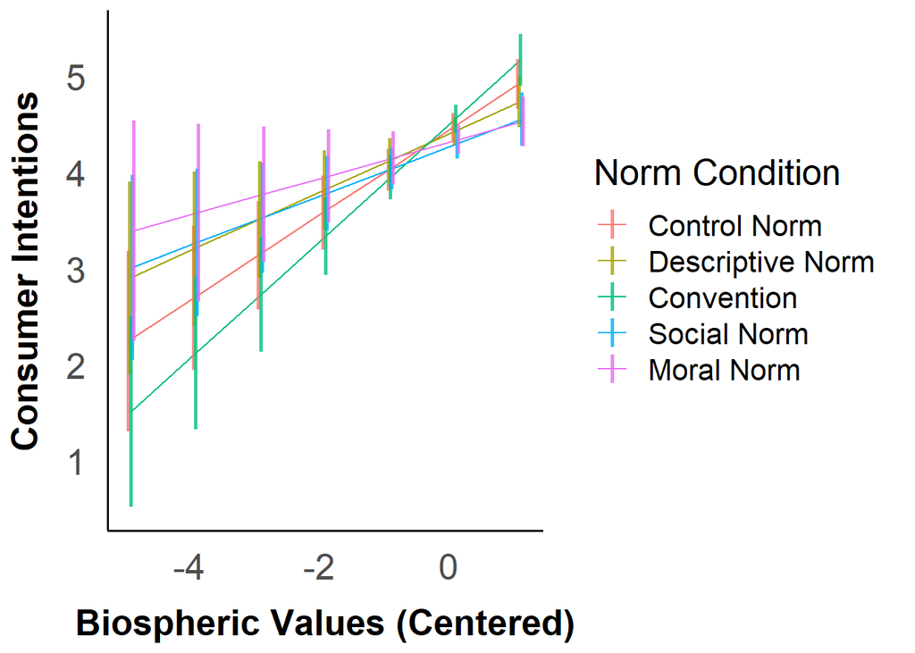

```r
at_list <- list(biospheric_center = seq(-4.9, 1.2, by = 1)) # add .05 to the bounds set by min and max

# without data overlaid
emmip(mod_mice, norm_condition ~ biospheric_center, at = at_list, CIs = TRUE, CIarg = list(lwd = 1, alpha = 0.8), xlab = "Biospheric Values (Centered)", ylab = "Consumer Intentions") + scale_colour_discrete(name = "Norm Condition", breaks=c("control_norm","descriptive_norm", "convention_norm", "social_norm", "moral_norm"),
        labels=c("Control Norm", "Descriptive Norm", "Convention", "Social Norm", "Moral Norm")) + theme_apa() + text_settings
```

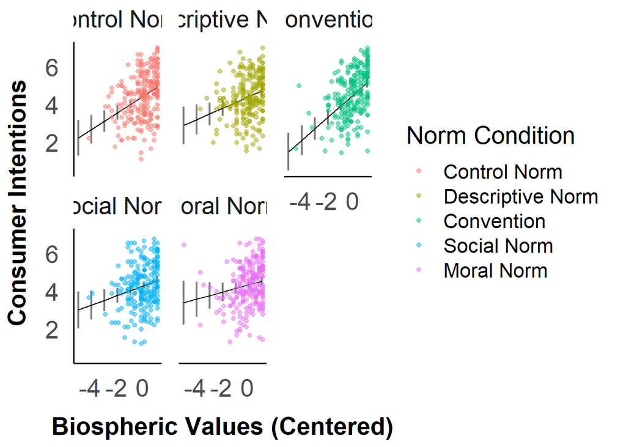

```r
# with data overlaid
emmip(mod_mice, ~ biospheric_center | norm_condition, at = at_list, CIs = TRUE, CIarg = list(lwd = 0.8, alpha = 0.5), xlab = "Biospheric Values (Centered)", ylab = "Consumer Intentions") + scale_colour_discrete(name = "Norm Condition", breaks=c("control_norm","descriptive_norm", "convention_norm", "social_norm", "moral_norm"), labels=c("Control Norm", "Descriptive Norm", "Convention", "Social Norm", "Moral Norm")) + geom_point(data = average_df, aes(x = biospheric_center, y = consumer_intentions, color = norm_condition), alpha = 0.5) + facet_wrap(~norm_condition, labeller = labeller(norm_condition = norm_labs)) + theme_apa() + text_settings
```

### Bio x Framing

Is the slope of the relationship between biospheric values & consumer intentions stronger in any one of the framing conditions compared to the others?

```r
bio_frame_trends <- emtrends(mod_mice, pairwise~framing_condition, var = "biospheric_center", adjust = "none")

bio_frame_trends$emtrends %>%
  knitr::kable(digits = 2)
```

| framing_condition | biospheric_center.trend | SE | df | lower.CL | upper.CL |
| --- | --- | --- | --- | --- | --- |
| control_framing | 0.37 | 0.09 | 1038 | 0.20 | 0.53 |
| pro_env_framing | 0.40 | 0.07 | 1038 | 0.27 | 0.54 |
| self_enh_framing | 0.32 | 0.09 | 1038 | 0.15 | 0.49 |

```r
bio_frame_trends$contrasts %>%
  knitr::kable(digits = c(NA,2,2,2,2,3))
```

| contrast | estimate | SE | df | t.ratio | p.value |
| --- | --- | --- | --- | --- | --- |
| control_framing - pro_env_framing | -0.04 | 0.11 | 1038 | -0.35 | 0.727 |
| control_framing - self_enh_framing | 0.05 | 0.12 | 1038 | 0.39 | 0.695 |
| pro_env_framing - self_enh_framing | 0.09 | 0.11 | 1038 | 0.78 | 0.438 |

Confidence interval

```r
confint(bio_frame_trends$contrasts) %>%
  knitr::kable(digits = 2)
```

| contrast | estimate | SE | df | lower.CL | upper.CL |
| --- | --- | --- | --- | --- | --- |
| control_framing - pro_env_framing | -0.04 | 0.11 | 1038 | -0.25 | 0.18 |
| control_framing - self_enh_framing | 0.05 | 0.12 | 1038 | -0.19 | 0.29 |
| pro_env_framing - self_enh_framing | 0.09 | 0.11 | 1038 | -0.13 | 0.30 |

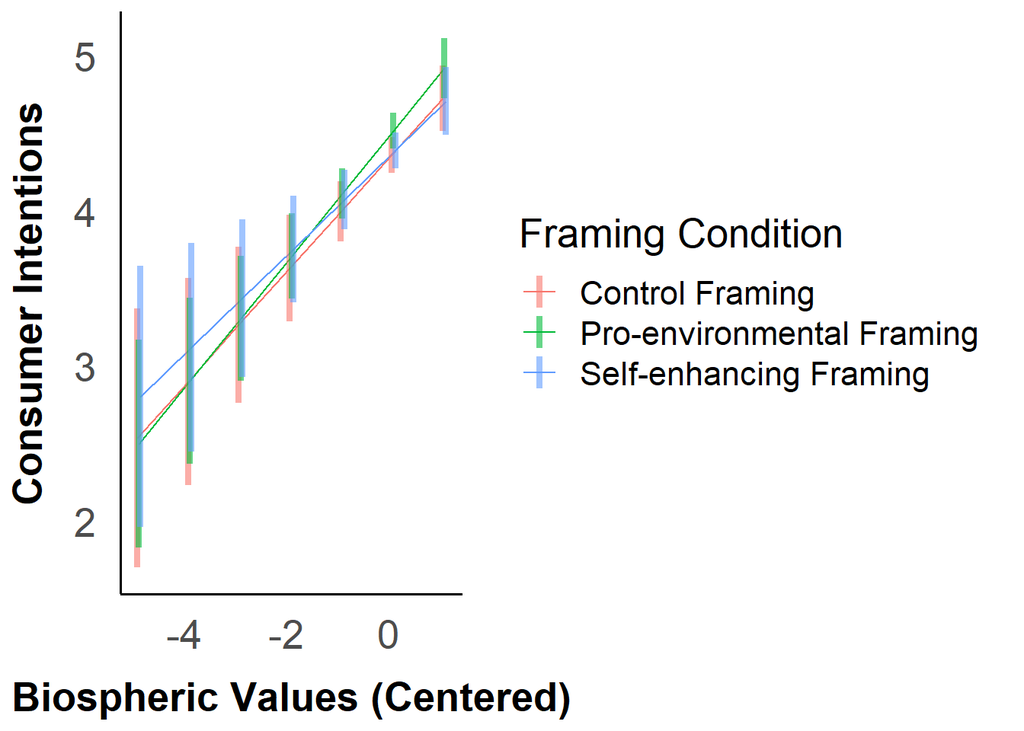

```r
# without data overlaid
emmip(mod_mice, framing_condition ~ biospheric_center, at = at_list, CIs = TRUE, CIarg = list(lwd = 1.5, alpha = 0.6), xlab = "Biospheric Values (Centered)", ylab = "Consumer Intentions") + scale_colour_discrete(name = "Framing Condition", breaks=c("control_framing","pro_env_framing","self_enh_framing"),
        labels=c("Control Framing", "Pro-environmental Framing", "Self-enhancing Framing")) + theme_apa() + text_settings
```

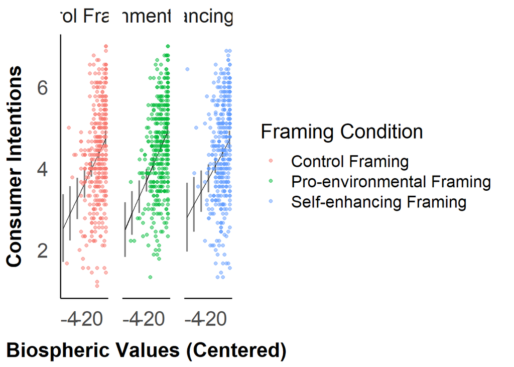

```r
# with data overlaid
emmip(mod_mice, ~ biospheric_center | framing_condition, at = at_list, CIs = TRUE, CIarg = list(lwd = 0.8, alpha = 0.5), xlab = "Biospheric Values (Centered)", ylab = "Consumer Intentions") + scale_colour_discrete(name = "Framing Condition", breaks=c("control_framing","pro_env_framing","self_enh_framing"), labels=c("Control Framing", "Pro-environmental Framing", "Self-enhancing Framing")) + geom_point(data = average_df, aes(x = biospheric_center, y = consumer_intentions, color = framing_condition), alpha = 0.5) + facet_wrap(~framing_condition, labeller = labeller(framing_condition = frame_labs)) + theme_apa() + text_settings
```

### Bio x Norm x Framing

> > H4: There will be a three-way interaction between values (biospheric, egoistic, altruistic, hedonic), framing condition, & norm condition such that when a pro-environmental or control framing is used, values will moderate the effect of each norm condition, but not when a self-enhancing framing is used.

AKA, is there a two-way interaction between values & norm condition across the three different framing conditions?

```r
bio_frame_norm_trends <- emtrends(mod_mice, pairwise~norm_condition | framing_condition, var = "biospheric_center", adjust = "none")

bio_frame_norm_trends$emtrends %>%
  knitr::kable(digits = 2)
```

| norm_condition | framing_condition | biospheric_center.trend | SE | df | lower.CL | upper.CL |
| --- | --- | --- | --- | --- | --- | --- |
| control_norm | control_framing | 0.57 | 0.16 | 1038 | 0.26 | 0.88 |
| descriptive_norm | control_framing | 0.47 | 0.19 | 1038 | 0.08 | 0.85 |
| convention_norm | control_framing | 0.83 | 0.19 | 1038 | 0.46 | 1.20 |
| social_norm | control_framing | 0.04 | 0.16 | 1038 | -0.28 | 0.36 |
| moral_norm | control_framing | -0.08 | 0.24 | 1038 | -0.55 | 0.39 |
| control_norm | pro_env_framing | 0.27 | 0.16 | 1038 | -0.04 | 0.58 |
| descriptive_norm | pro_env_framing | 0.18 | 0.16 | 1038 | -0.14 | 0.49 |
| convention_norm | pro_env_framing | 0.68 | 0.16 | 1038 | 0.36 | 1.00 |
| social_norm | pro_env_framing | 0.35 | 0.14 | 1038 | 0.07 | 0.64 |
| moral_norm | pro_env_framing | 0.54 | 0.15 | 1038 | 0.25 | 0.83 |
| control_norm | self_enh_framing | 0.50 | 0.19 | 1038 | 0.13 | 0.87 |
| descriptive_norm | self_enh_framing | 0.28 | 0.18 | 1038 | -0.08 | 0.63 |
| convention_norm | self_enh_framing | 0.32 | 0.18 | 1038 | -0.04 | 0.68 |
| social_norm | self_enh_framing | 0.38 | 0.21 | 1038 | -0.03 | 0.78 |
| moral_norm | self_enh_framing | 0.11 | 0.20 | 1038 | -0.29 | 0.51 |

```r
bio_frame_norm_trends$contrasts %>%
  knitr::kable(digits = c(NA,NA,2,2,2,2,3))
```

| contrast | framing_condition | estimate | SE | df | t.ratio | p.value |
| --- | --- | --- | --- | --- | --- | --- |
| control_norm - descriptive_norm | control_framing | 0.10 | 0.25 | 1038 | 0.41 | 0.684 |
| control_norm - convention_norm | control_framing | -0.26 | 0.24 | 1038 | -1.08 | 0.282 |
| control_norm - social_norm | control_framing | 0.53 | 0.23 | 1038 | 2.31 | 0.021 |
| control_norm - moral_norm | control_framing | 0.65 | 0.29 | 1038 | 2.27 | 0.024 |
| descriptive_norm - convention_norm | control_framing | -0.36 | 0.27 | 1038 | -1.35 | 0.176 |
| descriptive_norm - social_norm | control_framing | 0.42 | 0.26 | 1038 | 1.66 | 0.098 |
| descriptive_norm - moral_norm | control_framing | 0.55 | 0.31 | 1038 | 1.77 | 0.076 |
| convention_norm - social_norm | control_framing | 0.79 | 0.25 | 1038 | 3.17 | 0.002 |
| convention_norm - moral_norm | control_framing | 0.91 | 0.30 | 1038 | 3.01 | 0.003 |
| social_norm - moral_norm | control_framing | 0.12 | 0.29 | 1038 | 0.42 | 0.674 |
| control_norm - descriptive_norm | pro_env_framing | 0.09 | 0.22 | 1038 | 0.42 | 0.674 |
| control_norm - convention_norm | pro_env_framing | -0.41 | 0.23 | 1038 | -1.80 | 0.071 |
| control_norm - social_norm | pro_env_framing | -0.08 | 0.21 | 1038 | -0.39 | 0.693 |
| control_norm - moral_norm | pro_env_framing | -0.27 | 0.22 | 1038 | -1.23 | 0.221 |
| descriptive_norm - convention_norm | pro_env_framing | -0.51 | 0.23 | 1038 | -2.22 | 0.027 |
| descriptive_norm - social_norm | pro_env_framing | -0.18 | 0.21 | 1038 | -0.84 | 0.402 |
| descriptive_norm - moral_norm | pro_env_framing | -0.36 | 0.22 | 1038 | -1.67 | 0.096 |
| convention_norm - social_norm | pro_env_framing | 0.33 | 0.22 | 1038 | 1.50 | 0.133 |
| convention_norm - moral_norm | pro_env_framing | 0.15 | 0.22 | 1038 | 0.66 | 0.507 |
| social_norm - moral_norm | pro_env_framing | -0.18 | 0.21 | 1038 | -0.88 | 0.379 |
| control_norm - descriptive_norm | self_enh_framing | 0.22 | 0.26 | 1038 | 0.85 | 0.398 |
| control_norm - convention_norm | self_enh_framing | 0.18 | 0.26 | 1038 | 0.70 | 0.486 |
| control_norm - social_norm | self_enh_framing | 0.13 | 0.28 | 1038 | 0.45 | 0.655 |
| control_norm - moral_norm | self_enh_framing | 0.39 | 0.28 | 1038 | 1.40 | 0.162 |
| descriptive_norm - convention_norm | self_enh_framing | -0.04 | 0.26 | 1038 | -0.16 | 0.871 |
| descriptive_norm - social_norm | self_enh_framing | -0.10 | 0.28 | 1038 | -0.36 | 0.722 |
| descriptive_norm - moral_norm | self_enh_framing | 0.16 | 0.27 | 1038 | 0.60 | 0.549 |
| convention_norm - social_norm | self_enh_framing | -0.06 | 0.28 | 1038 | -0.20 | 0.838 |
| convention_norm - moral_norm | self_enh_framing | 0.20 | 0.27 | 1038 | 0.75 | 0.453 |
| social_norm - moral_norm | self_enh_framing | 0.26 | 0.29 | 1038 | 0.89 | 0.372 |

Confidence interval

```r
confint(bio_frame_norm_trends$contrasts) %>%
  knitr::kable(digits = 2)
```

| contrast | framing_condition | estimate | SE | df | lower.CL | upper.CL |
| --- | --- | --- | --- | --- | --- | --- |
| control_norm - descriptive_norm | control_framing | 0.10 | 0.25 | 1038 | -0.39 | 0.59 |
| control_norm - convention_norm | control_framing | -0.26 | 0.24 | 1038 | -0.74 | 0.22 |
| control_norm - social_norm | control_framing | 0.53 | 0.23 | 1038 | 0.08 | 0.97 |
| control_norm - moral_norm | control_framing | 0.65 | 0.29 | 1038 | 0.09 | 1.21 |
| descriptive_norm - convention_norm | control_framing | -0.36 | 0.27 | 1038 | -0.89 | 0.16 |
| descriptive_norm - social_norm | control_framing | 0.42 | 0.26 | 1038 | -0.08 | 0.93 |
| descriptive_norm - moral_norm | control_framing | 0.55 | 0.31 | 1038 | -0.06 | 1.15 |
| convention_norm - social_norm | control_framing | 0.79 | 0.25 | 1038 | 0.30 | 1.28 |
| convention_norm - moral_norm | control_framing | 0.91 | 0.30 | 1038 | 0.32 | 1.50 |
| social_norm - moral_norm | control_framing | 0.12 | 0.29 | 1038 | -0.45 | 0.69 |
| control_norm - descriptive_norm | pro_env_framing | 0.09 | 0.22 | 1038 | -0.35 | 0.54 |
| control_norm - convention_norm | pro_env_framing | -0.41 | 0.23 | 1038 | -0.86 | 0.04 |
| control_norm - social_norm | pro_env_framing | -0.08 | 0.21 | 1038 | -0.51 | 0.34 |
| control_norm - moral_norm | pro_env_framing | -0.27 | 0.22 | 1038 | -0.69 | 0.16 |
| descriptive_norm - convention_norm | pro_env_framing | -0.51 | 0.23 | 1038 | -0.96 | -0.06 |
| descriptive_norm - social_norm | pro_env_framing | -0.18 | 0.21 | 1038 | -0.60 | 0.24 |
| descriptive_norm - moral_norm | pro_env_framing | -0.36 | 0.22 | 1038 | -0.79 | 0.06 |
| convention_norm - social_norm | pro_env_framing | 0.33 | 0.22 | 1038 | -0.10 | 0.76 |
| convention_norm - moral_norm | pro_env_framing | 0.15 | 0.22 | 1038 | -0.29 | 0.58 |
| social_norm - moral_norm | pro_env_framing | -0.18 | 0.21 | 1038 | -0.59 | 0.22 |
| control_norm - descriptive_norm | self_enh_framing | 0.22 | 0.26 | 1038 | -0.30 | 0.74 |
| control_norm - convention_norm | self_enh_framing | 0.18 | 0.26 | 1038 | -0.33 | 0.69 |
| control_norm - social_norm | self_enh_framing | 0.13 | 0.28 | 1038 | -0.43 | 0.68 |
| control_norm - moral_norm | self_enh_framing | 0.39 | 0.28 | 1038 | -0.15 | 0.93 |
| descriptive_norm - convention_norm | self_enh_framing | -0.04 | 0.26 | 1038 | -0.54 | 0.46 |
| descriptive_norm - social_norm | self_enh_framing | -0.10 | 0.28 | 1038 | -0.64 | 0.44 |
| descriptive_norm - moral_norm | self_enh_framing | 0.16 | 0.27 | 1038 | -0.37 | 0.69 |
| convention_norm - social_norm | self_enh_framing | -0.06 | 0.28 | 1038 | -0.60 | 0.48 |
| convention_norm - moral_norm | self_enh_framing | 0.20 | 0.27 | 1038 | -0.33 | 0.74 |
| social_norm - moral_norm | self_enh_framing | 0.26 | 0.29 | 1038 | -0.31 | 0.83 |

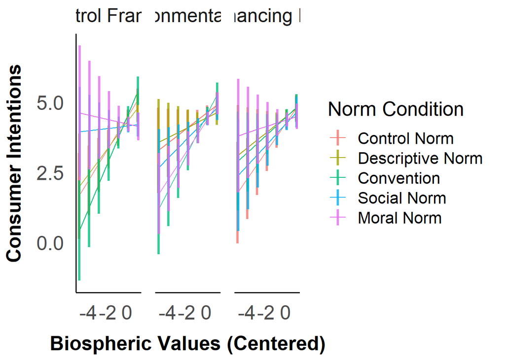

```r
# without data overlaid
emmip(mod_mice, norm_condition ~ biospheric_center | framing_condition, at = at_list, CIs = TRUE, CIarg = list(lwd = 1.2, alpha = 0.8), xlab = "Biospheric Values (Centered)", ylab = "Consumer Intentions") + scale_colour_discrete(name = "Norm Condition", breaks=c("control_norm","descriptive_norm", "convention_norm", "social_norm", "moral_norm"), labels=c("Control Norm", "Descriptive Norm", "Convention", "Social Norm", "Moral Norm")) + facet_wrap(~framing_condition, labeller = labeller(framing_condition = frame_labs)) + theme_apa() + text_settings
```

```r
# with data overlaid - doesn't work
```

## Altruistic Values

### Altruistic x Norm

Is the slope of the relationship between altruistic values & consumer intentions stronger in any one of the norm conditions compared to the others?

```r
alt_norm_slopes <- emtrends(mod_mice, pairwise~norm_condition, var = "altruistic_center", adjust = "none")

alt_norm_slopes$emtrends %>%
  knitr::kable(digits = 2)
```

| norm_condition | altruistic_center.trend | SE | df | lower.CL | upper.CL |
| --- | --- | --- | --- | --- | --- |
| control_norm | 0.12 | 0.16 | 1038 | -0.18 | 0.43 |
| descriptive_norm | -0.13 | 0.13 | 1038 | -0.39 | 0.13 |
| convention_norm | -0.05 | 0.13 | 1038 | -0.31 | 0.21 |
| social_norm | 0.10 | 0.15 | 1038 | -0.19 | 0.39 |
| moral_norm | 0.35 | 0.13 | 1038 | 0.09 | 0.60 |

```r
alt_norm_slopes$contrasts %>%
  knitr::kable(digits = c(NA,2,2,2,2,3)) # correct p-values
```

| contrast | estimate | SE | df | t.ratio | p.value |
| --- | --- | --- | --- | --- | --- |
| control_norm - descriptive_norm | 0.25 | 0.20 | 1038 | 1.26 | 0.210 |
| control_norm - convention_norm | 0.17 | 0.20 | 1038 | 0.85 | 0.393 |
| control_norm - social_norm | 0.02 | 0.21 | 1038 | 0.10 | 0.922 |
| control_norm - moral_norm | -0.22 | 0.20 | 1038 | -1.10 | 0.271 |
| descriptive_norm - convention_norm | -0.08 | 0.19 | 1038 | -0.43 | 0.670 |
| descriptive_norm - social_norm | -0.23 | 0.20 | 1038 | -1.18 | 0.238 |
| descriptive_norm - moral_norm | -0.48 | 0.18 | 1038 | -2.58 | 0.010 |
| convention_norm - social_norm | -0.15 | 0.20 | 1038 | -0.78 | 0.438 |
| convention_norm - moral_norm | -0.40 | 0.18 | 1038 | -2.14 | 0.032 |
| social_norm - moral_norm | -0.24 | 0.20 | 1038 | -1.24 | 0.216 |

Confidence interval

```r
confint(alt_norm_slopes$contrasts) %>%
  knitr::kable(digits = 2)
```

| contrast | estimate | SE | df | lower.CL | upper.CL |
| --- | --- | --- | --- | --- | --- |
| control_norm - descriptive_norm | 0.25 | 0.20 | 1038 | -0.14 | 0.65 |
| control_norm - convention_norm | 0.17 | 0.20 | 1038 | -0.23 | 0.58 |
| control_norm - social_norm | 0.02 | 0.21 | 1038 | -0.40 | 0.44 |
| control_norm - moral_norm | -0.22 | 0.20 | 1038 | -0.62 | 0.17 |
| descriptive_norm - convention_norm | -0.08 | 0.19 | 1038 | -0.45 | 0.29 |
| descriptive_norm - social_norm | -0.23 | 0.20 | 1038 | -0.62 | 0.15 |
| descriptive_norm - moral_norm | -0.48 | 0.18 | 1038 | -0.84 | -0.11 |
| convention_norm - social_norm | -0.15 | 0.20 | 1038 | -0.54 | 0.23 |
| convention_norm - moral_norm | -0.40 | 0.18 | 1038 | -0.76 | -0.03 |
| social_norm - moral_norm | -0.24 | 0.20 | 1038 | -0.63 | 0.14 |

```r
# On a single graph
describe(average_df$altruistic_center)
```

```
##    vars    n mean  sd median trimmed  mad   min  max range  skew kurtosis   se
## X1    1 1133    0 0.8   0.29    0.12 0.74 -5.21 0.79     6 -1.91     6.11 0.02
```

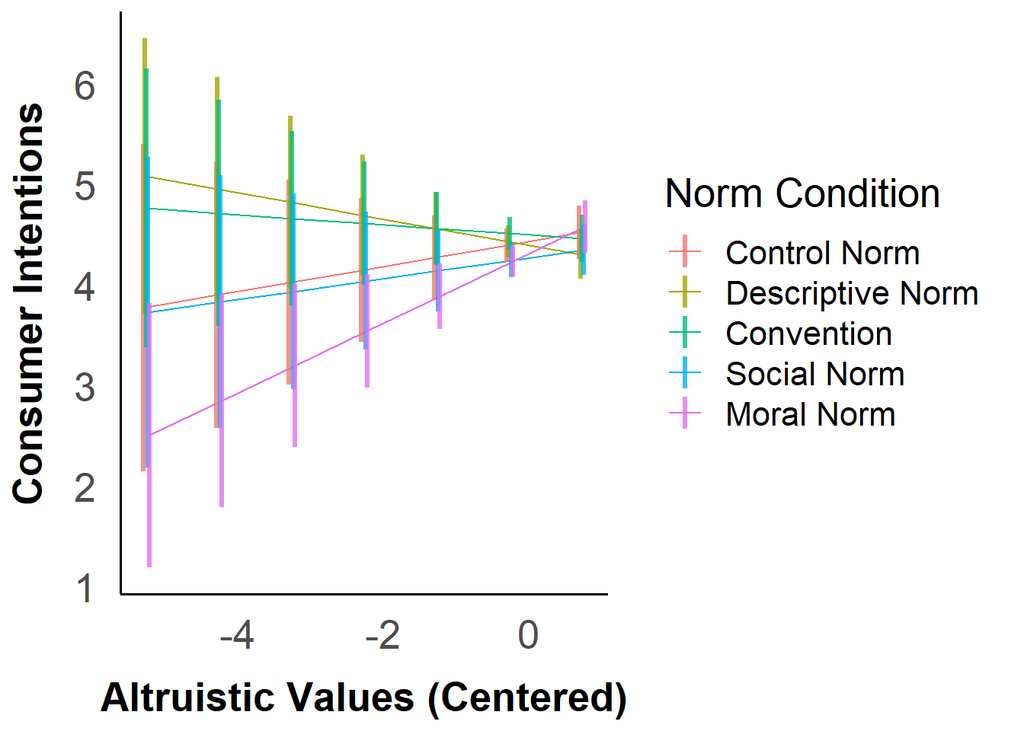

```r
at_list <- list(altruistic_center = seq(-5.26, 0.84, by = 1))

# without data overlaid
emmip(mod_mice, norm_condition ~ altruistic_center, at = at_list, CIs = TRUE, CIarg = list(lwd = 1.2, alpha = 0.8), xlab = "Altruistic Values (Centered)", ylab = "Consumer Intentions") + scale_colour_discrete(name = "Norm Condition", breaks=c("control_norm","descriptive_norm", "convention_norm", "social_norm", "moral_norm"), labels=c("Control Norm", "Descriptive Norm", "Convention", "Social Norm", "Moral Norm")) +theme_apa() + text_settings
```

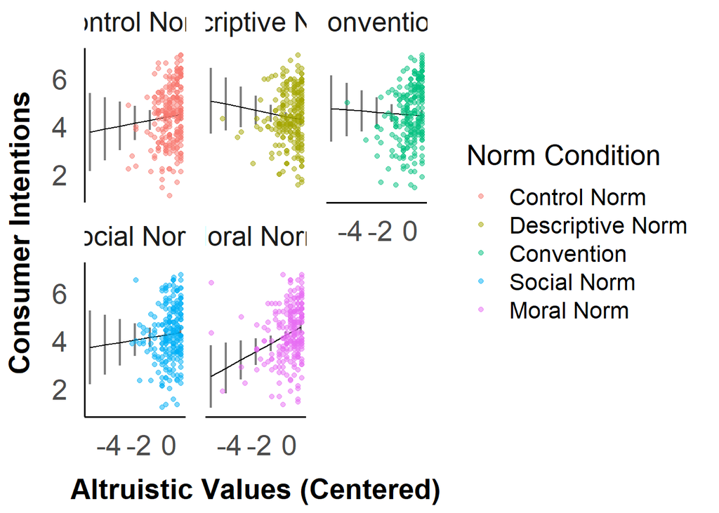

```r
# with data overlaid
emmip(mod_mice, ~ altruistic_center | norm_condition, at = at_list, CIs = TRUE, CIarg = list(lwd = 0.8, alpha = 0.5), xlab = "Altruistic Values (Centered)", ylab = "Consumer Intentions") + scale_colour_discrete(name = "Norm Condition", breaks=c("control_norm","descriptive_norm", "convention_norm", "social_norm", "moral_norm"), labels=c("Control Norm", "Descriptive Norm", "Convention", "Social Norm", "Moral Norm")) + geom_point(data = average_df, aes(x = altruistic_center, y = consumer_intentions, color = norm_condition), alpha = 0.5) + facet_wrap(~norm_condition, labeller = labeller(norm_condition = norm_labs)) +theme_apa() + text_settings
```

### Altruistic x Framing

Is the slope of the relationship between altruistic values & consumer intentions stronger in any one of the framing conditions compared to the others?

```r
alt_frame_trends <- emtrends(mod_mice, pairwise~framing_condition, var = "altruistic_center", adjust = "none")

alt_frame_trends$emtrends %>%
  knitr::kable(digits = 2)
```

| framing_condition | altruistic_center.trend | SE | df | lower.CL | upper.CL |
| --- | --- | --- | --- | --- | --- |
| control_framing | 0.11 | 0.11 | 1038 | -0.09 | 0.32 |
| pro_env_framing | -0.01 | 0.10 | 1038 | -0.20 | 0.19 |
| self_enh_framing | 0.13 | 0.12 | 1038 | -0.10 | 0.37 |

```r
alt_frame_trends$contrasts %>%
  knitr::kable(digits = c(NA,2,2,2,2,3))
```

| contrast | estimate | SE | df | t.ratio | p.value |
| --- | --- | --- | --- | --- | --- |
| control_framing - pro_env_framing | 0.12 | 0.14 | 1038 | 0.85 | 0.396 |
| control_framing - self_enh_framing | -0.02 | 0.16 | 1038 | -0.12 | 0.903 |
| pro_env_framing - self_enh_framing | -0.14 | 0.15 | 1038 | -0.91 | 0.361 |

Confidence interval

```r
confint(alt_frame_trends$contrasts) %>%
  knitr::kable(digits = 2)
```

| contrast | estimate | SE | df | lower.CL | upper.CL |
| --- | --- | --- | --- | --- | --- |
| control_framing - pro_env_framing | 0.12 | 0.14 | 1038 | -0.16 | 0.40 |
| control_framing - self_enh_framing | -0.02 | 0.16 | 1038 | -0.33 | 0.29 |
| pro_env_framing - self_enh_framing | -0.14 | 0.15 | 1038 | -0.44 | 0.16 |

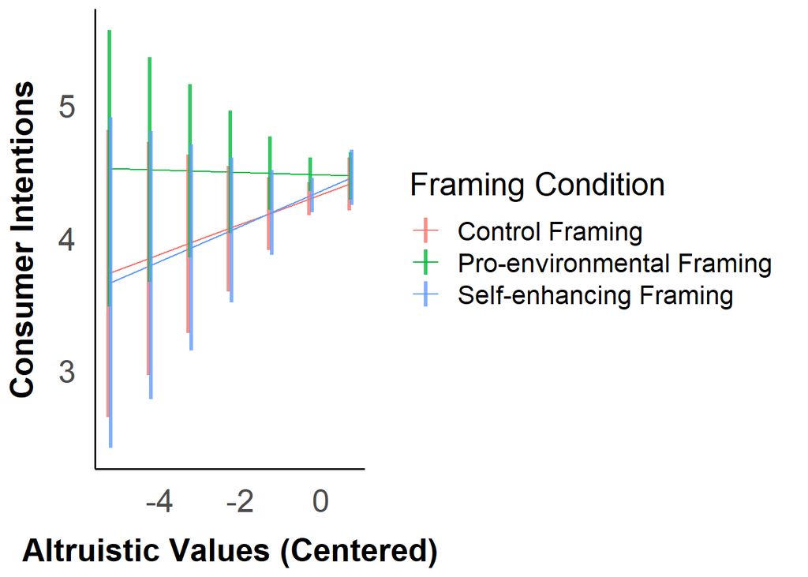

```r
# without data overlaid
emmip(mod_mice, framing_condition ~ altruistic_center, at = at_list, CIs = TRUE, CIarg = list(lwd = 1.2, alpha = 0.8), xlab = "Altruistic Values (Centered)", ylab = "Consumer Intentions") + scale_colour_discrete(name = "Framing Condition", breaks=c("control_framing","pro_env_framing","self_enh_framing"), labels=c("Control Framing", "Pro-environmental Framing", "Self-enhancing Framing")) +theme_apa() + text_settings
```

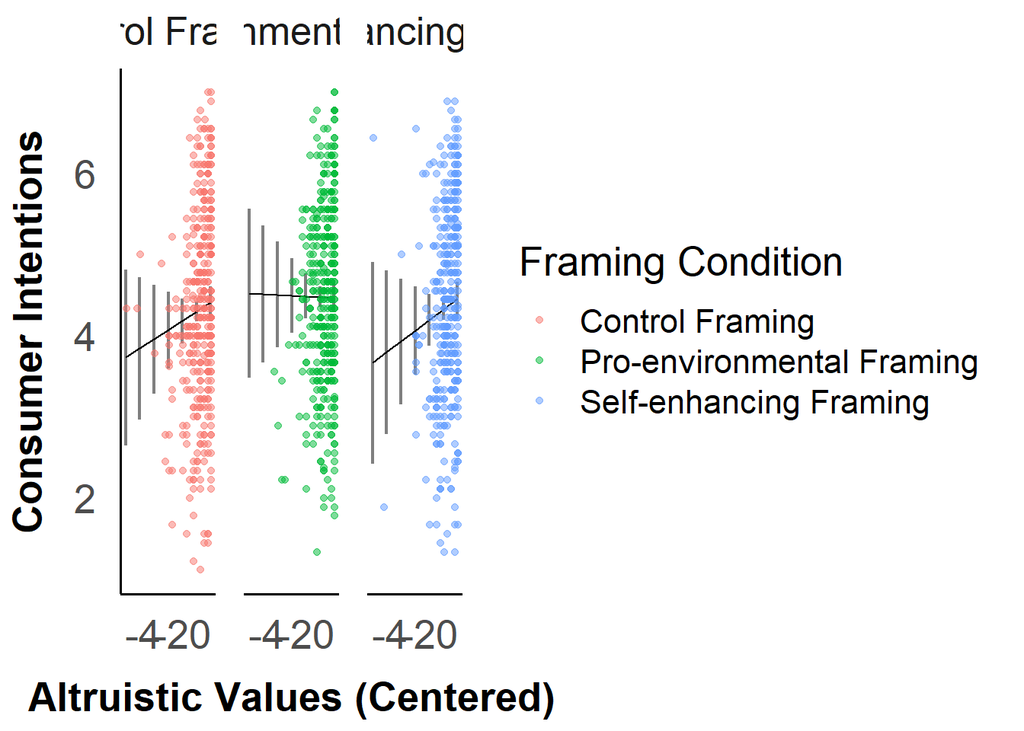

```r
# with data overlaid
emmip(mod_mice, ~ altruistic_center | framing_condition, at = at_list, CIs = TRUE, CIarg = list(lwd = 0.8, alpha = 0.5), xlab = "Altruistic Values (Centered)", ylab = "Consumer Intentions") + scale_colour_discrete(name = "Framing Condition", breaks=c("control_framing","pro_env_framing","self_enh_framing"), labels=c("Control Framing", "Pro-environmental Framing", "Self-enhancing Framing")) + geom_point(data = average_df, aes(x = altruistic_center, y = consumer_intentions, color = framing_condition), alpha = 0.5) + facet_wrap(~framing_condition, labeller = labeller(framing_condition = frame_labs)) +theme_apa() + text_settings
```

### Altruistic x Norm x Framing

```r
alt_frame_norm_trends <- emtrends(mod_mice, pairwise~norm_condition | framing_condition, var = "altruistic_center", adjust = "none")

alt_frame_norm_trends$emtrends %>%
  knitr::kable(digits = 2)
```

| norm_condition | framing_condition | altruistic_center.trend | SE | df | lower.CL | upper.CL |
| --- | --- | --- | --- | --- | --- | --- |
| control_norm | control_framing | 0.18 | 0.20 | 1038 | -0.21 | 0.56 |
| descriptive_norm | control_framing | -0.13 | 0.24 | 1038 | -0.61 | 0.35 |
| convention_norm | control_framing | -0.40 | 0.23 | 1038 | -0.85 | 0.06 |
| social_norm | control_framing | 0.41 | 0.24 | 1038 | -0.05 | 0.87 |
| moral_norm | control_framing | 0.50 | 0.27 | 1038 | -0.02 | 1.03 |
| control_norm | pro_env_framing | -0.01 | 0.25 | 1038 | -0.49 | 0.47 |
| descriptive_norm | pro_env_framing | 0.02 | 0.23 | 1038 | -0.42 | 0.47 |
| convention_norm | pro_env_framing | -0.04 | 0.21 | 1038 | -0.45 | 0.38 |
| social_norm | pro_env_framing | -0.06 | 0.23 | 1038 | -0.51 | 0.39 |
| moral_norm | pro_env_framing | 0.03 | 0.19 | 1038 | -0.33 | 0.40 |
| control_norm | self_enh_framing | 0.20 | 0.34 | 1038 | -0.47 | 0.88 |
| descriptive_norm | self_enh_framing | -0.28 | 0.21 | 1038 | -0.71 | 0.14 |
| convention_norm | self_enh_framing | 0.28 | 0.24 | 1038 | -0.20 | 0.76 |
| social_norm | self_enh_framing | -0.04 | 0.30 | 1038 | -0.62 | 0.54 |
| moral_norm | self_enh_framing | 0.50 | 0.21 | 1038 | 0.09 | 0.91 |

```r
alt_frame_norm_trends$contrasts %>%
  knitr::kable(digits = c(NA,NA,2,2,2,2,3))
```

| contrast | framing_condition | estimate | SE | df | t.ratio | p.value |
| --- | --- | --- | --- | --- | --- | --- |
| control_norm - descriptive_norm | control_framing | 0.31 | 0.31 | 1038 | 0.98 | 0.326 |
| control_norm - convention_norm | control_framing | 0.57 | 0.30 | 1038 | 1.90 | 0.058 |
| control_norm - social_norm | control_framing | -0.23 | 0.31 | 1038 | -0.76 | 0.446 |
| control_norm - moral_norm | control_framing | -0.33 | 0.33 | 1038 | -0.99 | 0.321 |
| descriptive_norm - convention_norm | control_framing | 0.27 | 0.34 | 1038 | 0.80 | 0.423 |
| descriptive_norm - social_norm | control_framing | -0.54 | 0.34 | 1038 | -1.59 | 0.113 |
| descriptive_norm - moral_norm | control_framing | -0.63 | 0.36 | 1038 | -1.76 | 0.079 |
| convention_norm - social_norm | control_framing | -0.81 | 0.33 | 1038 | -2.45 | 0.014 |
| convention_norm - moral_norm | control_framing | -0.90 | 0.35 | 1038 | -2.57 | 0.010 |
| social_norm - moral_norm | control_framing | -0.09 | 0.36 | 1038 | -0.27 | 0.790 |
| control_norm - descriptive_norm | pro_env_framing | -0.03 | 0.33 | 1038 | -0.09 | 0.927 |
| control_norm - convention_norm | pro_env_framing | 0.03 | 0.32 | 1038 | 0.10 | 0.924 |
| control_norm - social_norm | pro_env_framing | 0.05 | 0.33 | 1038 | 0.16 | 0.875 |
| control_norm - moral_norm | pro_env_framing | -0.04 | 0.31 | 1038 | -0.13 | 0.897 |
| descriptive_norm - convention_norm | pro_env_framing | 0.06 | 0.31 | 1038 | 0.20 | 0.843 |
| descriptive_norm - social_norm | pro_env_framing | 0.08 | 0.32 | 1038 | 0.26 | 0.796 |
| descriptive_norm - moral_norm | pro_env_framing | -0.01 | 0.29 | 1038 | -0.03 | 0.975 |
| convention_norm - social_norm | pro_env_framing | 0.02 | 0.31 | 1038 | 0.07 | 0.944 |
| convention_norm - moral_norm | pro_env_framing | -0.07 | 0.28 | 1038 | -0.25 | 0.803 |
| social_norm - moral_norm | pro_env_framing | -0.09 | 0.30 | 1038 | -0.31 | 0.754 |
| control_norm - descriptive_norm | self_enh_framing | 0.49 | 0.41 | 1038 | 1.20 | 0.231 |
| control_norm - convention_norm | self_enh_framing | -0.08 | 0.42 | 1038 | -0.19 | 0.846 |
| control_norm - social_norm | self_enh_framing | 0.24 | 0.45 | 1038 | 0.54 | 0.592 |
| control_norm - moral_norm | self_enh_framing | -0.30 | 0.40 | 1038 | -0.75 | 0.454 |
| descriptive_norm - convention_norm | self_enh_framing | -0.57 | 0.32 | 1038 | -1.75 | 0.080 |
| descriptive_norm - social_norm | self_enh_framing | -0.24 | 0.36 | 1038 | -0.67 | 0.502 |
| descriptive_norm - moral_norm | self_enh_framing | -0.78 | 0.30 | 1038 | -2.60 | 0.009 |
| convention_norm - social_norm | self_enh_framing | 0.32 | 0.38 | 1038 | 0.85 | 0.397 |
| convention_norm - moral_norm | self_enh_framing | -0.22 | 0.32 | 1038 | -0.67 | 0.506 |
| social_norm - moral_norm | self_enh_framing | -0.54 | 0.36 | 1038 | -1.49 | 0.137 |

Confidence interval

```r
confint(alt_frame_norm_trends$contrasts) %>%
  knitr::kable(digits = 2)
```

| contrast | framing_condition | estimate | SE | df | lower.CL | upper.CL |
| --- | --- | --- | --- | --- | --- | --- |
| control_norm - descriptive_norm | control_framing | 0.31 | 0.31 | 1038 | -0.31 | 0.92 |
| control_norm - convention_norm | control_framing | 0.57 | 0.30 | 1038 | -0.02 | 1.17 |
| control_norm - social_norm | control_framing | -0.23 | 0.31 | 1038 | -0.83 | 0.37 |
| control_norm - moral_norm | control_framing | -0.33 | 0.33 | 1038 | -0.97 | 0.32 |
| descriptive_norm - convention_norm | control_framing | 0.27 | 0.34 | 1038 | -0.39 | 0.93 |
| descriptive_norm - social_norm | control_framing | -0.54 | 0.34 | 1038 | -1.20 | 0.13 |
| descriptive_norm - moral_norm | control_framing | -0.63 | 0.36 | 1038 | -1.34 | 0.07 |
| convention_norm - social_norm | control_framing | -0.81 | 0.33 | 1038 | -1.45 | -0.16 |
| convention_norm - moral_norm | control_framing | -0.90 | 0.35 | 1038 | -1.59 | -0.21 |
| social_norm - moral_norm | control_framing | -0.09 | 0.36 | 1038 | -0.79 | 0.60 |
| control_norm - descriptive_norm | pro_env_framing | -0.03 | 0.33 | 1038 | -0.69 | 0.62 |
| control_norm - convention_norm | pro_env_framing | 0.03 | 0.32 | 1038 | -0.60 | 0.66 |
| control_norm - social_norm | pro_env_framing | 0.05 | 0.33 | 1038 | -0.60 | 0.71 |
| control_norm - moral_norm | pro_env_framing | -0.04 | 0.31 | 1038 | -0.64 | 0.56 |
| descriptive_norm - convention_norm | pro_env_framing | 0.06 | 0.31 | 1038 | -0.55 | 0.67 |
| descriptive_norm - social_norm | pro_env_framing | 0.08 | 0.32 | 1038 | -0.55 | 0.72 |
| descriptive_norm - moral_norm | pro_env_framing | -0.01 | 0.29 | 1038 | -0.59 | 0.57 |
| convention_norm - social_norm | pro_env_framing | 0.02 | 0.31 | 1038 | -0.59 | 0.63 |
| convention_norm - moral_norm | pro_env_framing | -0.07 | 0.28 | 1038 | -0.63 | 0.48 |
| social_norm - moral_norm | pro_env_framing | -0.09 | 0.30 | 1038 | -0.67 | 0.49 |
| control_norm - descriptive_norm | self_enh_framing | 0.49 | 0.41 | 1038 | -0.31 | 1.29 |
| control_norm - convention_norm | self_enh_framing | -0.08 | 0.42 | 1038 | -0.91 | 0.75 |
| control_norm - social_norm | self_enh_framing | 0.24 | 0.45 | 1038 | -0.65 | 1.13 |
| control_norm - moral_norm | self_enh_framing | -0.30 | 0.40 | 1038 | -1.07 | 0.48 |
| descriptive_norm - convention_norm | self_enh_framing | -0.57 | 0.32 | 1038 | -1.21 | 0.07 |
| descriptive_norm - social_norm | self_enh_framing | -0.24 | 0.36 | 1038 | -0.96 | 0.47 |
| descriptive_norm - moral_norm | self_enh_framing | -0.78 | 0.30 | 1038 | -1.38 | -0.19 |
| convention_norm - social_norm | self_enh_framing | 0.32 | 0.38 | 1038 | -0.43 | 1.08 |
| convention_norm - moral_norm | self_enh_framing | -0.22 | 0.32 | 1038 | -0.85 | 0.42 |
| social_norm - moral_norm | self_enh_framing | -0.54 | 0.36 | 1038 | -1.25 | 0.17 |

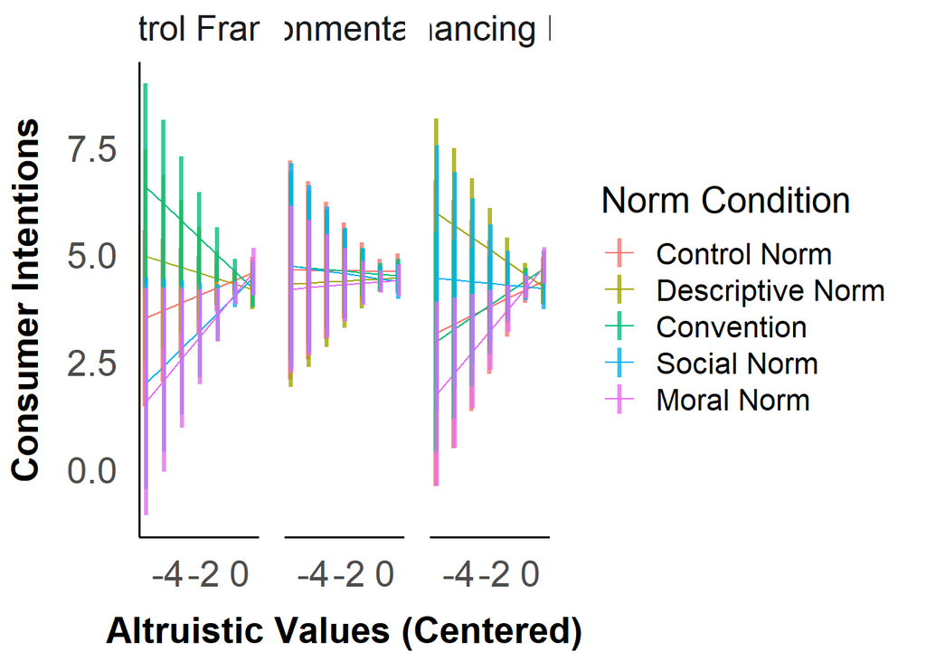

```r
# without data overlaid
emmip(mod_mice, norm_condition ~ altruistic_center | framing_condition, at = at_list, CIs = TRUE, CIarg = list(lwd = 1.2, alpha = 0.8), xlab = "Altruistic Values (Centered)", ylab = "Consumer Intentions") + scale_colour_discrete(name = "Norm Condition", breaks=c("control_norm","descriptive_norm", "convention_norm", "social_norm", "moral_norm"), labels=c("Control Norm", "Descriptive Norm", "Convention", "Social Norm", "Moral Norm")) + facet_wrap(~framing_condition, labeller = labeller(framing_condition = frame_labs)) +theme_apa() + text_settings
```